# 英语写作手册 ：中文版 (高等学校英语专业系列教材)

丁往道等

2010-07-01

[figure not shown]

[figure not shown]

Copyright © Foreign Language Teaching and Research Press 2010

All rights reserved. No part of this publication may be reproduced or distributed by any means, or stored in a database or retrieval system, without the prior written permission of Foreign Language Teaching and Research Press.

本书版权由外语教学与研究出版社独家所有。如未获得该社书面同意，书中任何部分之文字及图片，不得用任何方式抄袭、节录、翻印或存储利用于任何数据库及检索系统等。

Published by Foreign Language Teaching and Research Press

No. 19 Xisanhuan Beilu

Beijing, China 100089

http://www.fltrp.com

**图书在版编目（CIP）数据**

英语写作手册：中文版／丁往道等编著．—2版．—北京：外语教学与研究出版社，2010.7（2017.4重印）

（高等学校英语专业系列教材）

ISBN 978-7-5600-9842-5

Ⅰ．①英… Ⅱ．①丁… Ⅲ．①英语－写作－高等学校－教材 Ⅳ．①H315

中国版本图书馆CIP数据核字（2010）第139299号

出版人 蔡剑峰

项目负责 祝文杰

责任编辑 马 旭 张 蘅

封面设计 刘 冬

版式设计 韩晓梦

出版发行 外语教学与研究出版社

社 址 北京市西三环北路19号（100089）

网 址 http://www.fltrp.com

书 号 ISBN 978-7-5600-9842-5

凡侵权、盗版书籍线索，请联系我社法律事务部

举报电话：（010）88817519

电子邮箱：banquan@fltrp.com

法律顾问：立方律师事务所 刘旭东律师

中咨律师事务所 殷 斌律师

目 录

致教师

致学习者

第一章 文稿格式

I．安排

II．大写

III．移行

IV．标点

V．书法

参考答案

第二章 措词

I．词的类型

II．词义

III．泛指词和特指词

IV．习语

V．修辞格

1．明喻

2．隐喻

3．拟人

4．换喻

5．提喻

6．婉言

7．反语

8．夸大和缩小

9．移位修饰

10．矛盾修饰

11．头韵

VI．词典

1．词典的用处

2．几部好词典

参考答案

第三章 造句

I．完整句和不完整句

II．句子的类型

1．陈述句、疑问句、祈使句和感叹句

2．简单句、并列句、复合句和并列复合句

3．松散句、圆周句和对偶句

4．短句和长句

III．有效的句子

1．一致性

2．连贯性

3．简洁性

4．强调性

5．多样性

参考答案

第四章 段落

I．好段落的标准

1．一致性

2．连贯

3．过渡

II．段落写作的步骤

III．段落的展开法

1．按时间展开

2．按过程展开

3．按空间展开

4．用举例和归纳方式展开

5．用类比和对比方式展开

6．用原因和结果方式展开

7．用分类方式展开

8．用定义方式展开

9．结合几种方式展开

参考答案

第五章 完整的作文

I．好作文的标准

II．撰写作文的步骤

1．总体规划

2．打初稿

3．修订初稿

4．誊写定稿

III．作文的三大组成部分

1．开篇

2．主干

3．结尾

IV．文章的类型

1．描写文

2．记叙文

3．说明文

4．议论文

参考答案

第六章 摘要和读书报告

I．摘要

1．摘要的用途

2．写作程序

II．读书报告

1．读书报告的三个主要部分

2．撰写读书报告

参考答案

第七章 正式和非正式文体

I．文体的涵义

II．正式和非正式文体

1．语法方面的差别

2．词汇方面的差别

参考答案

第八章 论文

I．目的

II．步骤

1．选题

2．收集资料

3．分析资料，构思、制定提纲

4．撰写初稿

5．修改、定稿

III．格式

1．论文的结构

2．引文的使用

3．注释的使用

4．参考书目

IV．范文

参考答案

第九章 应用文

I．布告、通知

II．致意，问候，祝愿，祝贺，吊唁

1．致意、问候

2．祝愿、祝贺

3．吊唁

III．正式邀请

IV．便条

1．留言

2．约定

3．请求

4．道歉

5．致谢

6．非正式邀请

V．电子邮件

VI．书信

1．信件的组成部分

2．语言

3．信封的写法

4．公事信函和私人信函

VII．履历

参考答案

第十章 标点符号

I．逗号（,）

II．句号（.）

III．分号（;）

IV．冒号（:）

V．问号（?）

VI．感叹号（!）

VII．引号（""或''）

VIII．圆括号（()）

IX．方括号（[]）

X．破折号（—）

XI．斜线（/）

XII．斜体字和下划线

参考答案

批改／校对符号

写作错误统计表

中文版第二版前言

《英语写作手册》初版于1984年，是根据英语写作课实际教学中积累的材料编写而成的。出版后颇受读者欢迎，曾多次重印。该书不仅被众多高校用作英语专业教材，而且被许多翻译工作者和英语自学者用作参考书。1994年出了修订版，对全书内容做了大幅度的修改和补充，使其更好地满足教学和自学的需要。

本书原用英语写成。随着学习和使用英语的人日益增多，不断有读者来信，要求出一个中文版。这个要求是合理的，因为非英语专业的学生可能希望提高用英语写作的能力，但不一定需要学会有关写作的英语说法和用英语讨论作品。所以我们将全书的讲解部分译为中文，在个别地方也做了修改和补充，保留了英语例句、例段和范文，从而编成这个中文版。

全书共分10章，就文稿格式、选词、造句，到整篇作文、研究论文和书信、简历等的写法都有所讲述。我们希望本书对各专业的学生和愿意学习英语写作的工作者都会有所帮助。

对使用本书的师生和朋友，我们建议先通读一遍，以了解各章的内容，再结合自己的需要，细读有关章节。例如，想知道学位论文或研究报告怎样写，有什么规格上的要求，即可细读第八章。又如，想知道逗号、句号等究竟应放在引号内还是引号外，便可查阅第十章第Ⅶ节。

我们热忱欢迎使用本书的师生和各界朋友提出批评意见，以便我们今后修订时参考。

致教师

近几年来，很多学校的英语专业都开设了写作课，对学生进行系统的写作训练。这无疑是我国英语教学的一大进展，表明对学生的培养趋于全面，应该充分肯定。

我们用自己的语言写一篇文章，已经不容易，更不用说用一种外语来写了。但实际教学经验证明，学生用英语写作的能力完全可以培养，有些学生甚至可以写出内容有趣、语言通顺、可读性很强的文章。关键在于师生双方对写作训练都抱有热情，并准备为此做坚持不懈的努力。外语写作可教，这应该是我们的结论。

写作和其他笔头练习，如造句、填充、选择、改错、单句翻译等等，有根本的区别：写作要求表达清楚而完整的思想，其他笔头练习则着重语言项目的掌握。换言之，写作课的主要目的不是帮助学生熟悉某些语法项目或某些词汇，而是提高学生用英语表达思想的能力。在这个过程中，学生自然不仅复习了旧的而且也学到了新的语法与词汇知识，但这种复习与学习是以有助于表达思想为前提的。写作课不是语法课或词汇课，而是研究如何表达思想的课程，这应该是另一个结论。

写作涉及的问题很多，除了语言各方面的问题外，还有思想内容和所用材料、组织条理、书写格式等等，都需要仔细考虑，认真对待。在语言方面，教师应注意帮助学生在已有的基础上，不断提高表达思想的准确性与鲜明性，逐渐使他们感觉到英语的极强的表达力，从而喜欢琢磨如何写好文章。在内容方面，应要求言之有物，观点正确，条理清楚。在书写格式上，也应有严格的要求。所以写作训练是全面的训练，不仅有助于提高语言水平，还有助于提高观察分析、逻辑思考的能力，有助于培养严谨的工作作风。不少学生认为写作课是对他们最有帮助，也是他们最喜欢的课程之一。写作课很有益、很重要，这也是应该得到的一个结论。

英语专业的写作课，以从第三学期开始为宜，因为这时学生大体上已掌握了基本语法，并初步会使用3,000个左右最常见的词汇。有了这个基础，便可以开始系统的写作训练了。如果学生早一点或晚一点达到这个水平，写作课可以相应地提早或推迟。

由于教学内容很多，写作能力的提高也只能慢慢来，所以写作课要连续地开设到第七或第八学期。这本教材基本上能够满足本科阶段写作教学要求，我们建议作如下的时间分配：

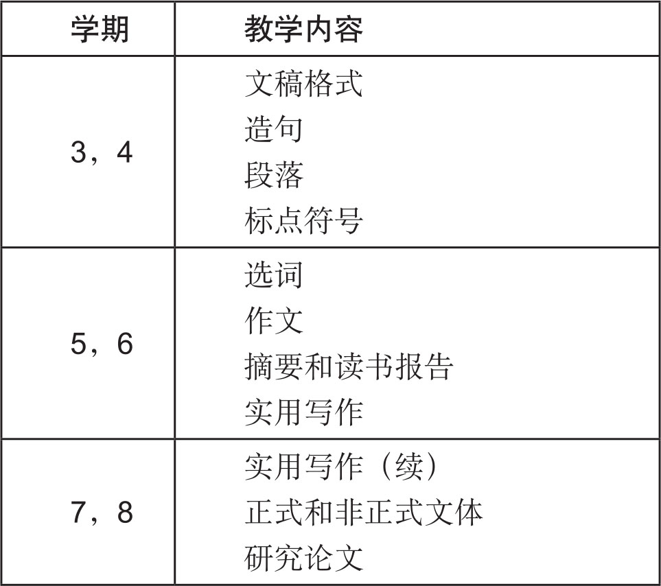

各年级的教学内容有些重复或交叉是有益的。例如在二年级也可以写作文，在三年级也可以再讲讲造句法和标点符号的用法。我们的设想是二年级以段落为重点，三年级以作文为重点，四年级的重点则是学术论文。

课堂工作主要有两项：一是讲解教材，包括做练习；一是学生作业讲评。两项工作所用时间尽可能要大致相等。如学生隔周做一次作业，则两项工作隔周轮换进行。

作业讲评，如能抓住重点，对学生会有很大的帮助。所谓要点，就是恰当地表达思想，而不是从表面上看句子结构或用词是否正确。在学生作业中会发现一些句子，本身并没有错，但表达思想不准确、不生动或没有突出重点，或与上下句联系不紧密。在课上讨论这样的句子比简单地指出语法错误或用词错误更有启发性，更能促使学生研究写作方法。当然语法与用词问题也需要提出来。还有全篇的组织、重点，以及格式、体例等问题，都可以讨论。至于观点问题，有时比较复杂，在课后和学生个别谈谈可能效果更好。

学生各方面的长处和不足之处，从语言掌握到知识面，从工作态度到观察分析能力，都可能在他们的笔头作业中反映出来。因此写作课的教师往往对学生有较多的了解。这也就向教师提出了一个责无旁贷的义务：全面地关心学生，热情地帮助学生。

编者

致学习者

我们学习用英语写作，有什么好处，有什么帮助呢？

对这个问题的答复应该是：好处很多，帮助很大。

写作能帮助我们提高使用英语的准确性。只要写一个句子，更不用说一段、一篇，就得力求句法、用词、拼法、大写、标点等等完全正确，而且与上下文联系紧密，语气连贯。写和说不同，写好后可以检查修改，而一次修改就是一次提高。写得越多，语言就会越准确。

写作能扩大所用语言的范围。口语所用的语言一般是比较简单常用的，复杂的或文雅的语言很少用，也不宜用。而写作所用的语言则是多种多样的，从极简单的到极复杂的都用得上，所用的词汇和句型比口语中常用的要多，这当然对掌握英语极有好处。

写作训练帮助我们提高逻辑思考及分析问题的能力。写一篇作文，不论长短，都需要妥善地组织材料，得出结论，做到重点突出，条理清楚。这样，在锻炼写作能力的同时，也锻炼了分析与处理实际问题的能力。

写作要求认真细致，一丝不苟。从一词一句到全篇结构，都必须仔细琢磨，反复推敲。还要抄写工整，格式正确。所以在写作练习中可以培养严谨的工作作风。

写作对阅读、听力、口语有促进的作用。自己知道写作的甘苦，对别人的写法就会敏感一些。分析问题的能力提高了，听别人说话就会善于抓住要点。语言质量提高了，口语也会准确一些。

写作还有许多实际用途，诸如写信、撰写论文、起草报告及讲稿等等。同时写与译也密切相关，想做好翻译，必须提高写作水平。

现在再谈谈怎样才能学好写作。

扎实的语言基本功是首先要具备的条件。这包括对语法（句法和词法）及基本词汇用法的掌握。如有不太清楚的地方，应通过阅读语法书和查词典来逐步解决。

多读书是极为重要的。既要读英文书，也要读中文书；既要读文艺作品，也要读知识性著作。通过读书来了解社会与人生，扩大知识面，丰富思想与感情，增强观察与分析的能力。在读书时应注意和研究书的内容，同时也应适当注意作者的写作方法，吸取有用的语言。

在日常生活中，也应养成观察与分析的习惯，遇事问个“为什么”。如果经常这样做，就会使自己的思路敏捷，思想有深度。

多读书加上多观察、多分析，在写作文时便不会苦于找不到材料，无话可说。

写的时候应该首先考虑内容问题，问问自己“写什么”，其次考虑如何组织材料或观点，从何处开始，到何处结束，也就是问问自己“怎样写”。

在语言的使用上应记住的一个原则是：能恰当表达思想的语言就是好的语言，也就是应该用的语言。所以不必总是追求某一类型的语言，如文雅的、艰深的、浅易的，或俚俗的。不过对学习者来说，应先学会使用英语的核心部分，即最常用的语言。

写完初稿后还要再三斟酌，反复修改，一直改到自己感到满意时为止。在抄好或打好后，仔细检查是不可缺少的一步，以求不漏掉任何一个自己可以改正的错误。

正如前面所说，这样认真地写，既锤炼了自己的语言，又培养了好的作风。

“功夫不负苦心人。”只要肯下功夫，必然取得进步。

编者

第一章 文稿格式

学习写作，应明确什么是好的文稿格式。在**标题** 的写法、纸边**留空** 、段落开端的**缩进** 、大写、词的**移行** 等方面，都应遵照通行的规则。不管写什么，都要细致、认真，写得或打得整齐干净，尽可能避免错误。写好后，还要仔细校阅一两次，做最后的改正或改动。经常这样练习写作，必然会取得进步。

I．安排

有格的练习本和常规的办公纸（19厘米×27厘米）都可以使用。最好隔行写，以便于阅读和修改。如果纸张很薄，背面就不要再写了。

在纸的四边都要留空：上边空2厘米，左边、右边和下边各空1.5厘米。练习本中已标出上、下的空边，所以只需要在左边画一道竖线。

写英文很难使右边的空白上下对齐，但绝不要一直写到纸的边缘。如一行末尾的空白处写不下要写的词，而那个词又不能在中间分开，就该把它写在下一行。换句话说，在纸的右边必须留下一点空白。

**题目** 应在第一行的中间。**题目的第一个和最后一个词** 应用大写字母开始，**中间的词** （包括复合词中符后面的词）也都应大写，但**冠词、并列连词** （and, or, but, nor, for）、**介词** 和**不定式** 的**to** 除外，例如：

My First Visit to the Palace Museum

The People without a Country

Rules to Abide By

Dickens and David Copperfield

What Can the Artist Do in the World of Today?

What Reform Means to China

The Myth of a "Negro Literature"

The English-Speaking People in Quebec

题目后不加句号。如题目是疑问句，应加问号；如是间接引语形式的疑问句（如上面的第六个），则不加问号。题目中的引用词语或文章的标题，应加引号；书名则在下面画线或用斜体标明。

课堂练习1 根据大写规则书写下列标题。

1．where i lived, and what i lived for

2．are transgenic crops safe

3．well-known dramatists of the ming dynasty

4．a day to remember

5．approaches to teaching english as a foreign language

6．criticisms on the ending of mark twain's adventures of huckleberry finn

每段的开头应**缩进** ，即留出**四到五个字母的空白** 。

页码用阿拉伯数字标出，写在每一页的右上角，不加括号或句号。第一页可不标。

在一行的开端不可用逗号、句号、分号、冒号、问号或感叹号，这些标点符号如果需要的话，应放在一行的末尾。方括号、圆括号和引号的前一半不能放在行尾。表示一个词移行的连字符应置于上行的末尾，而不是下行的开端。

II．大写

大写字母主要用于三处：句子的开头，标题中的实义词和专有名词。

不只是完整的句子，就是当句子使用的是不完整句时，也应用大写字母开头。

引语（两个引号之间的词语）如是完整的句子，也用大写字母开头。如引用的一句话分成两部分，放在两对引号之中，第二部分不用大写字母开始，除非第一个词是专有名词或由专有名词变来的形容词：

He said, "My trip to Mount Tai was interesting but tiring."

"My trip to Mount Tai," he said, "was interesting but tiring."

I asked, “When do you usually go home?'

She answered, "At weekends."

普通名词已成为专有名词的一部分时，也要大写：

| 普通名词 | 专有名词 |
| --- | --- |
| a famous university | Peking University |
| a broad street | Chang'an Street |
| a large lake | Lake Erie |
| the president of the university | President Brown |
| middle, age | the Middle Ages |
| labor, day | Labor Day |
| people, republic | the People's Republic of China |

从专有名词演变而来的词一般也大写：

| Marxist | Darwinism | Hegelian |
| --- | --- | --- |
| Confucian | Latinize | Vietnamize |

但专有名词及其派生词也可能变成普通名词、动词或形容词：

mackintosh（由苏格兰化学家Charles Mackintosh的名字变来）

chauvinistic（由拿破仑的狂热信徒Nicolas Chauvin的名字派生出来）

quixotic（由小说 Don Quixote 中主人公的名字派生而来）

anglicize（由拉丁文 Anglicus 演变而来）

III．移行

快写到一行的末端时，应看看还剩下多大的空处。如果写不下你要写的那个词，应考虑是移行还是把整个词写在下一行。要避免把一个词挤在纸边上。

移行的基本原则是按照音节把词分开，同时，连字符不得出现在一行的开头。注意以下各点：

单音节词，如through，march，brain，pushed，不能分开。

不要把词的一个字母，即使那个字母构成一个音节，写在行末或行首，如**a·** lone, trick**·y** 。

不要把只有两个字母的音节写在行首，如hat**·ed** ，cab**·in** 。

避免把人名和地名分开写，如Chi·na，Aus·ten。

已带有连字符的复合词只可在连字符处分开，如father-in-law，empty-handed。

把词分开写应注意避免造成误解，如pea·cock，re·ally。

一页的最后一个词不要移行，可以把整个词写在下一页。

有前缀或后缀的词，应在前、后缀和词根之间分开，如re·state·ment，un·relent·ing。双音节词有重复的辅音字母时，可在这两个字母间分开strug·gle，shat·ter。

词的分写有时并不容易。没有把握时，应查词典（参看第二章第VI节）。

课堂练习2 按照一般规则标出下列词可分写之处。

alive

setting

sister-in-law

handy

correctness

gratitude

bonus

permission

sociable

thought

dictatorship

far-reaching

IV．标点

多种标点符号的用法在本书第十章中有较详尽的讨论。此处提出一些基本规则，学习写作时应特别注意并牢记。

结构完整的句子，不论长短，后面都用句号。

不要用逗号连接两个并列从句；应用逗号加连词，或用分号。

把逗号和句号分清：逗号带个小尾巴（,）；句号是个黑圆点（.），不是一个圆圈（。），中文的句号才为小圆圈。

在疑问句后用问号，但在改为间接引语的问句后不用问号：

"Have you done your exercises?" the teacher asked.

The teacher asked whether we had done our exercises.

感叹号只用在需要强调的感叹句或表示强烈感情的词语后面。不要用得太多。

直接引语应放在两个引号之间。说话人和表示“说”的动词可放在引语前面、后面或中间：

**She said,** "We have decided to take the examination."

"We have decided to take the examination," **she said** .

"We have decided," **she said** , "to take the examination."

注意上面三个句子的标点符号用法。第一句中的She said后面用逗号；第二句的引语后用逗号，she是小写；第三句在decided和she said后面都用逗号，而且引语的第二部分也用小写字母开始。总之，引语和she said被视作一个句子，只是引语的第一个词要大写。

课堂练习3 将下面的段落加上标点，并在需要处用大写字母。

we entered the room jane looked around and asked where is the cat

she must have run away I answered she doesn't like to stay at home

we must go and find her jane said let's go

at this moment the cat walked out from under the chair

V．书法

应细心书写，便于别人阅读。大写字母应稍大于并稍高于小写字母，**a** 和**o** ，**n** 和**u** 要分清，**i** 和**j** 上面要加一点，**t** 要加一横。在逗号后空出约一个字母的间隔，在句号后则空出约两个字母的间隔。

如要划去一个词，不能用括号把它括起来，因为括号中的词还是要的；而要用粗线把它勾销。如要增加一个词，应加在已写的一行词上面，不要加在下面，还要用清楚的符号表明加在何处。

常见的手写字体有两种：一种是所谓草体，即字母相连；另一种是所谓印刷体，即字母不相连。两种字体都可以，但最好坚持用一种。

课堂练习4 任选两三段文章，抄写下来，注意书法和文稿格式。

参考答案

课堂练习1

1．Where I Lived, and What I Lived For

2．Are Transgenic Crops Safe?

3．Well-Known Dramatists of the Ming Dynasty

4．A Day to Remember

5．Approaches to Teaching English as a Foreign Language

6．Criticisms on the Ending of Mark Twain's Adventures of Huckleberry Finn

课堂练习2

set-ting

sister-in-law

han-dy

cor-rect-ness

grat-i-tude

bo-nus

per-mis-sion

so-cia-ble

thought

dic-ta-tor-ship

far-reaching

课堂练习3

We entered the room. Jane looked around and asked,

"Where is the cat?"

"She must have run away," I answered. "She doesn't stay at home."

"We must go and find her," Jane said.

"Let's go."

At this moment the cat walked out from under the chair.

第二章 措词

措词指词语的选择与使用。英语词汇极多：《牛津英语词典》收了四十多万个词。当然并没有人认识或需要使用这么多词。常人为了一般的目的只用其中很小的一部分。学习用英语写作的学生应先学会使用最有用也最常用的词来表达自己的思想。有时初学者会误用一些词，但他用的词往往并不全错，只是不恰当、不准确、不地道、或不生动有趣。因而有必要对选词的方法作基本的了解。

I．词的类型

根据语体风格，常用的词可分为三类：**正式的、一般的、非正式的** 。

**正式的** 词也可称作学术性的词、文雅的词或“大”词。这类词主要用于正式文体，如学术性或理论性著作、政治和法律文件，以及正式的演讲或报告。这类词多有三个以上的音节，多数源于希腊或拉丁文。在日常谈话中除非为了特殊的目的，否则很少用这类词。下面这段文章中包含一些体现正式文体的词汇：

There is nothing new in the recognition, within a given language, of a distinction between common usage and uses of the language for more restricted purposes and often enough, perhaps characteristically, more elevated purposes. The monolithic nature of English is not questioned when literary essayists like Emerson contrast poetry and common speech. The latter is recognized in America to be the proper subject for the investigation of linguists who, however, now show some incipient inclination to investigate poetry, too, and other noncasual utterances in a given language.

—C. F. Voegelin

全段只有三句，每句都长而复杂。其中正式的或学术性的词汇颇多，如recognition，characteristically，elevated，monolithic，investigation，incipient，inclination，noncasual，utterances等。就此文来说，长句和正式词汇是合适的，由于文章讨论的是一个相当复杂的问题，因而需要用这样的词句把理论说得清楚和确切。

但文中多数词还是人们常用的，并在多种文体中出现的。正因为如此，这类词便被称作**一般** 词汇。请看下面一段：

When I was a kid, and reading every science fiction book in the local library, I used to wonder exactly how the future would happen. By that I don't mean what the future would be like —science fiction already told me that—but rather how we'd actually get there. Science fiction books seemed to agree, for example, that in the future there would be no money—all transactions would be made via identity cards and centralized computers. But that seemed dubious to me: how, I wondered, are you going to get everybody to give up money in the first place?

—Michael Rogers

在这段文字中，除了一两个非正式词，如kid，和一两个稍正式的词，如transactions和dubious，所有的词都是常用的，句子比上一段的句子短得多，也简单得多。这样的句子和词汇很适合本段的内容——它描写一个孩子的想法。

有一类词主要用于**非正式** 的、不讲究客套的谈话，很少出现于正式文章中。在文学作品中它们主要用来记述人们的想法和对话。这类词一般很短，只有一两个音节，多数出自撒克逊语（即不是从希腊语、拉丁语或法语借来的），可称之为非正式词，如guts（胆量），guy（男人），hassle（麻烦）。

在下面一段中有一些这样的词：

You have your tension. Sometimes you come close to having an accident, that upsets you. You just escape maybe by a hair or so. Sometimes maybe you get a disgruntled passenger on there, and starts a big argument. Traffic. You have someone who cuts you off or stops in front of the bus. There's a lot of tension behind that. You got to watch all the time. You're watchin' the drivers, you're watchin' other cars. Most of the time you have to drive for the other drivers, to avoid hitting them. So you take the tension home with you.

—Studs Terkel

这样就有了三个类型也可说是三个层次的词：上面是正式的、学术性的词，下面是非正式词，中间是一般的词。一般的词可用于任何种类的文章；除非为了特殊的目的或效果，正式的词很少用于非正式的文章，而非正式词也很少用于正式文章。

这三类词属于规范英语词汇，凡受过良好教育的人说英语就要用这些词。还有些词是特别群体的人为了特殊的效果才用的，如俚语、方言词汇也有一些词是没有受过良好教育的人常用的。

**俚语** 是很不正式的，虽然可能生动有趣，但是如果用得不恰当，则会使作者或说话人显得无礼或可笑：

On hearing that his father had kicked the bucket , we wrote him a letter to express our sympathies.

The big banquet held in honor of the distinguished guests was really neat .

由于用了俚语，上面第一句话听起来并不表示同情，而第二句的口气很不严肃。

在下面一段，一位农民因为学校老师把学生带出去实习而说了一些气话：

I'll attend to that myself in th' mornin'. I'll take keer o' 'im. He ain't from this county nohow. I'll go down there in th' mornin' and see 'im. Lettin' you leave your books and gallivant all over th' hills. What kind of a school is it nohow! Didn't do that, my son, when I's a little shaver in school.

—Jesse Stuart

这位农民的发音说明他用的是方言：有的音省掉了，把-ing说成-in，把care说成keer。他用ain't代替isn't，用I's代替I was，用nohow代替anyhow。有些没受过良好教育的人可能用这些词，但它们并非规范词汇。a little shaver是个俚语说法，意思是“一个小孩子”。

这种非标准或不规范的词汇和表达法在描写受教育不多的人的故事中会常常见到。学英语的外国学生应该懂得它们的意思，但不必在口语和写作中使用。

课堂练习1 仔细阅读下面一段文章，然后回答问题。

1．这一段出自什么类型的书籍？该书的目的是什么？

2．这本书的写作对象是科学家还是普通大众？

3．文中有俚语吗？有正式词语吗？请举例。

4．用词与内容相符吗？请说明。

Language is our facility to talk to each other. The word 'talk' is used not merely to avoid a rather more technical and high-sounding word like 'communicate'; talk is more precise and more relevant to the special nature of human language than 'communicate'. In the first place, all creatures—cat, sparrow, and bee—can be said to communicate with each other to some extent. They can attract each other's attention, warn of danger, woo their mates, and direct the way to food. We are still learning just how well animals can communicate with each other, but there can be no doubt that animal communication is wholly rudimentary as compared with the complex and subtle control of language possessed by even the least intelligent or least educated English tramp or Australian aboriginal. It is therefore appropriate to say that language involves 'talk' to emphasize that language is a peculiarly human activity.

—Randolph Quirk

II．词义

**词义** 有两个方面：**原义** 和**涵义** 。原义即词原来的意思，如词典中所注明的；涵义指词所暗含的感情或想法。

例如country，nation，state，land的原义有相同之处，都相当于中文的“国家”，但它们的涵义却很不相同。country指地区、其人口及政府，nation主要指人民，state主要指政府、政治组织，land的意思不如country精确，而且文雅些，并更有感情色彩。

an island country ; neighboring countries

In area China is the third largest country in the world.

a peace-loving nation ; the awakening nations of Africa

The modernization program has won the support of the whole nation .

state organs; state -owned enterprises

China is my native land .

就此处比较的词义而言，这四个词可算作同义词。英语中同义词非常丰富，原因是它许多世纪以来吸收了其他语言的词汇。但我们要记住一点：很难找到在意思和用法上完全一样的词，它们在文体层次、强调的程度、感情色彩、语气和搭配上总会有差别。

一般说来，源自盎格鲁－撒克逊语的词往往是普通常用的词或非正式词，而来自拉丁语或法语的词常为学术性的或正式的词。试比较：

| ask | time | rise |
| --- | --- | --- |
| question | age | mount |
| interrogate | epoch | ascend |

每组中第一个词来自盎格鲁－撒克逊语，后两个词来自法语或拉丁语。显然，第一个词比后两个更常用、更口语化。

big和large都是常用的词，但large比big稍正式一点，可用来描写特别大的东西，因而比big语气重些。huge比上面两个文雅一点，意思是“极大”，因而比large的语气更重。

a big/large city; a big/large house

Wuhan is a very large city in Central China.

The team has got a huge man over two meters tall.

small和little常可换用，但在感情色彩上略有不同。small作客观的描写，而little可能表示喜爱的感情：

They lived in a small town.

I will never forget the little town where I spent my happy childhood.

modest和humble都有谦逊的意思，modesty是好的品德，humbleness却不是。humble常表示过分的自卑。因此这两个词语气不同：一个赞美，另一个贬低。

Modest and hardworking, he made very quick progress at school.

Clearly Gompers was overawed by Wilson. His face took on a servile look; his voice was humble .

有些同义词搭配不同。它们通常和不同的词连用。例如，在修饰amount，number，quantity这些名词时，用large而不用big（a large amount of money，a large number of people，a large quantity of beer等等）。在修饰表示人的品质的名词，如courage，confidence，ability，wisdom时，通常不用big或large，而用great。

上述各种差异说明学习写作的学生要注意同义词的区别。有困难时，应在一本较好的词典中查找有关词的用法及其同义词的注释。下面是同义词辨析的一个例子：

SYN .**—proud** is the broadest term in this comparison, ranging in implication from proper self-esteem or pride to an overweening opinion of one's importance [too proud to beg, proud as a peacock]; **arrogant** implies an aggressive, unwarranted assertion of superior importance or privileges [the arrogant colonel]; **haughty** implies such consciousness of high station, rank, etc. as is displayed in scorn of those one considers beneath one [a haughty dowager]; **insolent** , in this connection, implies both haughtiness and great contempt, esp. as manifested in behavior or speech that insults or affronts others [she has an insolent disregard for her servant's feelings]; **overbearing** implies extreme, domineering insolence [an overbearing supervisor]; **supercilious** stresses an aloof, scornful manner toward others [a supercilious intellectual snob]; **disdainful** implies even stronger and more overt feelings of scorn for that which is regarded as beneath one **—ANT. humble**

**—Webster's New World College Dictionary（第4版）**

关于词义，中国学生特别要注意一点：不应把一个英语词的中文译法或对应词当作它的确切意思，或者通过其中文译法或对应词来理解某英语词。许多英语词的中文译法或对应词固然表示它们的原义，但也有许多英语词没有确切的中文译法或对应词，它们在不同的上下文中必须用不同的译法。

就以很简单的send一词来说吧。如认为它的意思就是“送”，便会把“他给我送来一封信”写成：He came to send me the letter（应为He brought me the letter），或把“我昨天到车站去送朋友”写成I went to the station to send a friend yesterday（应为I went to the station to see a friend off yesterday）。send的真正意思是使别人到某处去，或使某物被送到某处，但本人（send的主语）自己并不去。

为了准确地了解一个英语词的意思，最好查阅有英语释义的词典，看那个词的英语定义。中文翻译并不总是可靠，有时还会导致误解。

有些英语词可译为相同的中文词，但这些英语词并不是同义词。例如family和home都可译为“家”，但它们的意思很不一样：family指亲属，而home指住的地方。except和besides都可译为“除了”，但两个词意思相反：except表示排除在外，而besides表示包括在内：We all went to the park except Li.（李没有去。）Besides Li，Wang and Zhao answered the question correctly.（李也答对了。）

课堂练习2 仔细阅读下面一段文章，然后回答问题。

1．再看文中带shocked，raging，slashing，mocking与amazed的句子，并且解释它们在句中的意思。

2．为上列各词找出两个同义词，把它们置换于文中，然后比较你选用的词和原来的词在文章中的不同效果。

That night in my rented room, while letting the hot water run over my can of porkand beans in the sink, I opened [H. L. Menken's] A Book of Prefaces and began to read. Iwas jarred and shocked by the style, the clear, clean, sweeping sentences. Why did he write like that? And how did one write like that? I pictured the man as a raging demon, slashing with his pen, consumed with hate, denouncing everything American, extolling everything European or German, laughing at the weaknesses of people, mocking God, authority. What was this? I stood up, trying to realize what reality lay behind the meaning of the words. Yes, this manwas fighting, fighting with words. He was using words as a weapon, using them as one would use a club. Could words be a weapon? Well, yes, for here they were. Then maybe, perhaps, I could use them as a weapon? No. It frightened me. I read on and what amazed me was not what he said, but how on earth anybody had the courage to say it.

—Richard Wright

课堂练习3 下列各句中都有两个斜体词，请选出比较确切的一个并说明理由。

1．A few listeners were disinterested/uninterested and dozed off.

2．Though she has grown up, her behavior is often childlike/childish .

3．I am quite jealous/envious of your opportunity to study at such a famous university.

4．Her clothes, though made of cheap/inexpensive material, are quite elegant.

5．This homely/ugly old man is a well-known musician.

6．I am sorry to refuse/decline your invitation.

7．He was surprised/stunned to find that his little sister had become a pretty, slim/ skinny young woman.

8．My uncle became fat/stout as he grew older.

9．This servile man was especially modest/humble when he was talking with his superiors.

10．I asked every/each boy in the group the same question, and interestingly, everyone/each gave me a different answer.

11．The enemy troops were driven back when they attempted/tried to cross the border.

12．They all felt sympathy/pity for the victims of the disaster and made donations.

13．Empress Dowager Cixi was famous/notorious for her cruelty.

14．Is that old/elderly woman/lady sitting on the bench your mother?

III．泛指词和特指词

比较而言，有些词比另一些词的意思要广泛些或具体些。例如professionals和scientists，doctors，teachers，lawyers，journalists等词相比意思更为广泛，但scientists和physicists，chemists相比，意思又泛一些了。chemists和biochemists相比，则是后者更具体。

虽然一般词汇和具体词汇都有用，但是学写作的学生应特别下功夫掌握并使用具体词汇。具体词汇有助于使文章清楚、准确、生动和鲜明，因为与一般词汇相比，具体词汇的信息量更大，表达力更强。试比较：

| a good man | kind, honest, just, generous, sympathetic, warm-hearted, selfless, brave, honorable |
| --- | --- |
| good food | tasty, delicious, nourishing, rich, wholesome, fresh, appetizing, abundant |
| house | mansion, villa, chateau, cottage, bungalow, cabin, hut, shack, shanty, shed, barn |
| laugh | smile, grin, beam, giggle, titter, snigger, chuckle, guffaw, chortle |

很明显，右边的具体词汇比左边的一般词汇更细致，更精彩；它们似乎使读者看到、听到或感到作者所要描写的事物。

运用具体词汇和提供细节应结合起来，这样方可写出使人印象深刻的文章。请看下面的一些例子：

**General**

It is often windy and dusty here in spring.

**Specific**

In spring there is often a very strong northwest wind. It carries so much fine dust with it that sometimes the sun becomes obscure. There is no escape from the fine dust; it gets into your eyes, your ears, your nostrils, and your hair. It goes through the cracks of closed windows and covers your desks and chairs.

**General**

Students do many interesting things after classes.

**Specific**

Every morning and afternoon the sports fields are alive with energetic students. Football and basketball matches, volleyball, and badminton, track-training and gymnastics are all in full swing. Even the alleyways under the trees and around the flower beds provide enough space for enthusiasts to practice. Through the windows comes the pitter-patter of ping-pong balls, the sound of songs and music, or laughter and discussion.

**General**

An old Negro woman was walking in the woods.

**Specific**

Far out in the country there was an old Negro woman with her head tied in a red rag, coming along a path through the pinewoods. She was very old and small and she walked slowly in the dark pine shadows, moving a little from side to side in her steps, with the balanced heaviness and lightness of a pendulum in a grandfather clock. She carried a thin, small cane made from an umbrella, and with this she kept tapping the frozen earth in front of her. This made a grave and persistent noise in the still air, that seemed meditative like the chirping of a solitary little bird.

—Eudora Welty

**General**

Not far from the railway there was a cottage with a garden and trees and flowers around it.

**Specific**

On the outskirts of a little town upon a rise of land that swept back from the railway there was a tidy little cottage of white boards, trimmed vividly with green blinds. To one side of the house there was a garden neatly patterned with plots of growing vegetables, and an arbor for the grapes which ripened late in August. Before the house there were three mighty oaks which sheltered it in their clean and massive shade in summer, and to the other side there was a border of gay flowers. The whole place had an air of tidiness, thrift, and modest comfort.

—Thomas Wolfe

课堂练习4 写出一些比下列词的词义更为具体的词。

walk

look at

cry

angry

tree

animal

flower

wind

rain

IV．习语

习语是有特殊意思的固定短语，其意思和组成这个习语的各个词的意思大不相同。例如read a book便不是一个习语，因为这个词组的意思就是组成它的三个词的意思的结合，而且a book还可以换成别的词，诸如a newspaper，a novel等。但**read between the lines** 就不同了：组成这个短语的四个词单独都不表示这个短语的意思，而且换掉其中任何一个词，这个短语都无法使人看懂。

英语中的习语很丰富。下面各种类型的习语是最常见的：

**phrasal verbs**

put up with

turn out

look forward to

carry on

come across

**n. + prep. + n.**

a straw in the wind

the apple of one's eye

like a fish out of water

in a world of one's own

**prep. + n.**

in kind

on the air

at length

with flying colors

**v. + n.**

won't hold water

slip one's mind

kill two birds with one stone

go to the dogs

**as ... as**

as easy as pie

as big as life

as different as night and day

as poor as a church mouse

**pairs of words**

wear and tear

high and dry

touch and go

in black and white

**sayings**

One man's meat is another man's poison.

A stitch in time saves nine.

Take it or leave it.

Don't count your chickens before they are hatched.

习语常用于发言和文章中，使得语言自然、地道。外国学生在使用习语时应注意两点：

1．大多数习语用于非正式或口语化文体，谈话时可用；但少数是俚语，应慎用，如all balled up（使……变得紊乱/一团糟），to cough up（勉强说出或供出）；

2．很多习语由于用得太多而不再新鲜有趣，如armed to the teeth，as good as gold，因而以少用为宜。

课堂练习5 写出与下列动词词义相同的短语动词。

continue

endure

investigate

expect

destroy (a building)

build

start

postpone

begin to like

V．修辞格

词可以有两种使用法：一是按本来的意思使用；一是按引申的意思使用。后一种用法也可说是比喻的或形象的用法，目的在于激发读者或听众的想象。在a colorful garden这个短语里，colorful是按词的本来意思使用的；但在a colorful life和a colorful career这两个短语里，colorful就是比喻的用法了。life和career本来都没有颜色，而修饰它们的colorful则有了新的引申或形象的意思：令人激动的、有趣的、多种多样的。由于这个词的使用使得life或career被比作一个像花园一样的有不同颜色的东西；正因为引起这一联想，这个词就比interesting或exciting等按本来意思用的词更容易给人留下深刻的印象。

词的比喻用法有很多种，称为修辞格。下面列出几种最常见的修辞格：

1．明喻

用like，as或其他词指出两个截然不同的事物之间相似之处的手法叫明喻。

O my love's **like** a red, red rose.

—Robert Burns

That man can't be trusted. He's **as** slippery **as** an eel.

The old man's hair is **as** white **as** snow.

在上面三个例句中，完全不同类别的人和物被放在一起进行比较：女人和玫瑰，男人和鳗鱼，头发和雪。但每一对都有一个共同点：美丽、油滑、白色。正因为被比较的事物有极大的差别，它们的共同点才显得格外鲜明。

2．隐喻

用一个词来指代与该词本来所指事物有相似特点的另一个事物的手法叫隐喻。这也是一种比较。不过这个比较是暗含的，而不用as或like点明。假如彭斯把上面引的那个诗句写成O my love's a red, red rose，省去原有的like这个词，他便是用隐喻而不是明喻了。在改了的这句里，虽然也把my love比作rose，但没用一个词明确指示这个比较，因而rose此处是隐喻用法。同样地，在He is the soul of the team和Irrigation is the lifeblood of agriculture这两句中，soul和lifeblood也属隐喻用法。

隐喻不仅仅和be连用，也不只是名词才可以用作隐喻。请看下面的例句：

The **picture** of those poor people's lives was **carved** so sharply in his heart that he could never forget it.

There was a **medieval** magnificence about the big dining-hall.

The street **faded** into a country road with **straggling** houses by it.

There were a few **lordly** poplars before the house.

All his former joy was **drowned** in the embarrassment and confusion he was feeling at the moment.

He often **prefaced** his remarks by "I can't help thinking..."

The charcoal fire glowed and dimmed **rhythmically** to the strokes of the bellows.

上面的例句说明名词、动词、形容词和副词都可以有隐喻用法。隐喻总是暗含比较。以第四句为例，lordly这个词表示房前的白杨树高大挺拔而且庄严，好像古时的贵族（lord）一样。第六句中的prefaced这个词则把那个人习惯在说话前先说I can't help thinking...比作给书作序。

隐喻和明喻必须新鲜才能产生好的效果。用得太频繁或太久就会变得陈旧无趣，不能起到隐喻或明喻的作用了。the leg of a table中的leg在初用时，必定也是个隐喻，但今天我们倒觉得这是它的本义了。

3．拟人

把事物或概念当作人或具备人的特质的手法，叫拟人。拟人在诗歌中很常见：

Youth is hot and bold,

Age is weak and cold,

Youth is wild, and Age is tame.

—William Shakespeare

在这几行诗中，Youth和Age被当作两个人来描写。在散文中也用拟人手法，虽然不像在诗中那样常见。

The match will soon be over and defeat is **staring** us in the face.

This time fate was **smiling** to him.

Thunder **roared** and a pouring rain started.

Dusk came **stealthily** .

The storm was **raging** and an **angry** sea was continuously **tossing** their boat.

4．换喻

用某一事物的名称代替与之密切相关的另一事物名称的手法叫换喻。例如crown可以代替king，the White House可以代替美国总统或政府，the bottle可以代替wine或alcohol，the bar可以代替the legal profession等。换喻用得好，则可产生简明生动的效果：

**Sword** and **cross** in hand, the European conquerors fell upon the Americans.

When the war was over, he laid down the **sword** and took up the **pen** .

His **purse** would not allow him that luxury.

5．提喻

指用部分代表整体，或用整体代表部分：

The farms were short of **hands** during the harvest season.

He had to earn his daily **bread** by doing odd jobs.

**Germany** beat **Argentina** 2 to 1 in this exciting football match.

The poor **creature** could no longer endure her sufferings.

在上面的例句中，hands代表人，bread代表食物或生活费，两个国家名字代表两个球队，creature代表女人。

换喻和提喻有相似之处：二者都是一种替换，有时它们与隐喻不易区分，因为后者在一定程度上也是一种替换。

6．婉言

即用温和或模糊的表达法替换生硬的或令人不快的表达法，例如：

| to die | to pass away, to leave us; one's heart has stopped beating |
| --- | --- |
| old people | senior citizens |
| mad | emotionally disturbed |
| dustman | sanitation worker |
| lavatory | bathroom, men's/women's room |
| invasion, raid | military action |
| driving inhabitants away or controlling them | pacification |
| concentration camps | strategic hamlets |

很明显，一般人用委婉语是为了避免直接说出不愉快的事实，但政客们用委婉语则可能是为了欺骗公众。

7．反语

这是指与真正的意思明显相反的词，用它的目的在于产生特殊的效果。假定你准备郊游，并且期待天气会很好，但是那天却下大雨。如果你不说天气糟透了，而说What fine weather for an outing!那就是用反语了。把野蛮的行为称作civilized或cultural，也是反语。

8．夸大和缩小

前者是把事情说得过分；后者是把分量或程度压低。两者的目的相同，都在于使陈述或描写鲜明、有趣。

She is **dying** to know what job has been assigned her.

On hearing that he had been admitted to that famous university, he whispered to himself, "I'm the **luckiest** man in the world."

It took **a few** dollars to build this indoor swimming pool.

"He is really **strange** ," his friends said when they heard he had divorced his pretty and loving wife.

9．移位修饰

把修饰语从它本应修饰的名词之前移到与该名词有关的词之前的手法，叫移位修饰。当某人说I've had a busy day 时，他就用了这个修辞手段，因为busy本应修饰人，现在却用来修饰day。类似的例子还有：

She was so worried about her son that she spent several **sleepless** nights.

In his **quiet** laziness he suddenly remembered that strange word.

The assistant kept a **respectful** distance from his boss when they were walking in the corridor.

He said "Yes" to the question in an **unthinking** moment.

The old man put a **reassuring** hand on my shoulder.

10．矛盾修饰

意思矛盾的词有时可用在一起，以达到加深印象的目的：

The coach had to be **cruel** to be **kind** to his trainees.

When the news of the failure came, all his friends said that it was a **victorious defeat** .

The president was **conspicuously absent** on that occasion.

She read the long-awaited letter with a **tearful smile.**

11．头韵

两个或更多的词以相同的辅音字母开始，便构成头韵，如proud as a peacock和blind as a bat。头韵常用于诗中来突出意思上有联系的词：

Wherefore feed, and clothe, and save,

From the cradle to the grave,

Those ungrateful **dr** ones who would

**Dr** ain your sweat—nay, **dr** ink your blood?

—Percy Bysshe Shelley

在散文中有时也为了同样的目的而使用头韵：

I see also the **d** ull, **d** rilled, **d** ocile, brutish masses of the Hun soldiery plodding on like a swarm of crawling locusts.

The Russian danger is therefore our danger, ...just as the cause of any Russian fighting for his **h** earth and **h** ome is the cause of free men and free peoples in every quarter of the globe.

上面两句选自丘吉尔在1941年就希特勒侵苏发表的演说。

课堂练习6 仔细阅读下面的文章，然后回答问题。

1．该文章的文体属于正式还是非正式？

2．举出文中正式用词和表达法的例子。

3．文中用了哪些修辞手法？请举例说明。

Five score years ago, a great American, in whose symbolic shadow we stand, signed the Emancipation Proclamation. This momentous decree came as a great beacon light of hope to millions of Negro slaves who had been seared in the flames of withering injustice. It came as a joyous daybreak to end the long night of captivity.

But one hundred years later, we must face the tragic fact that the Negro is still not free. One hundred years later, the life of the Negro is still sadly crippled by the manacles of segregation and the chains of discrimination. One hundred years later, the Negro lives on a lonely island of poverty in the midst of a vast ocean of material prosperity. One hundred years later, the Negro is still languishing in the corners of American society and finds himself an exile in his own land. So we have come here today to dramatize an appalling condition.

—Martin Luther King, Jr.

课堂练习7 请指出下列各句分别运用了哪些修辞格。

1．Her rich relatives rained birthday presents on her only son.

2．Wrong ideas may harm man just like diseases.

3．Some words may be defaced by careless usage.

4．The leaves are trembling in the cold wind.

5．The storm was so angry that it wanted to destroy everything in its way.

6．Many people bowed before Force, but eventually Force would surrender to Reason.

7．Selfless people are like cows, which eat straw but produce milk.

8．"What do you think of the roast duck?" "Not bad."

9．His friends praised his daughter's performances to the skies.

10．His writing is clear and clean.

11．His unfriendly tongue surprised her.

12．There is fertile soil for popular music in China today.

VI．词典

1．词典的用处

学英语的外国人在阅读和写作时手头要有一本好词典，好词典对我们学习和使用词汇有很大的帮助。

对词的拼法、分音节法及发音拿不准时，就应该查词典。如果词典给了不止一种拼法，可任选一种，如judgment，judgement；aging，ageing（第一种拼法可能更可取）。有时字写到行末需要移行时难以断定在何处分开，而把各种移行规则都记住实在不容易。词典恰恰提示了词的分音节法——或在音节之间留出一点空或加一个黑点，如ma te ri al ism，in·sep·a·ra·ble。词典还说明一个复合词通常是写成一个词、两个词还是加连字符，如gaslight，shortsighted，far-sighted，gas mask。许多词典用国际音标注音。也有些词典用它们自己的音标，相应的说明可在每页的最下面或词典前面的介绍中找到。如在一个词的后面标出两种发音法，则二者都可采用。

每个词条后都注明它的词类，若是动词还注明及物或不及物用法。不规则动词标有过去式和过去分词。此外还注明了名词的不规则复数形式以及一个词可能有的其他变化。在较大型的词典中还可以查到词源，也就是词的演变历史，如autocrat这个词会有如下的词源介绍：

[Fr. autocrate <Gr. autokrates , absolute ruler <autos , self + kratos , power, rule]

从这个词源注解中可以得知autocrat是从希腊语来的，因而是个正式的而不是口语化的词。此外，还可以学到auto就是“自己”的意思，这会帮助我们理解和记忆用auto开始的一些词，如automobile，automatic，autograph，automaton，autonomous等。

对于学习写作的人来说，词典中最有用的部分是词的释义以及与之配合的例句、解说、用法标识和注解等。前面已经提到，中国学生不应该依靠中文翻译来理解英语词义，而是要研究词的英语释义，例如dangerous这个词的英语释义是：

**dan·ger·ous** S 2 W 2 /'deɪndʒә rәs/adj

**1** able or likely to harm or kill you;→**harmful** : laws about dangerous dogs |

Some of these prisoners are extremely dangerous . | **It's dangerous** for a woman to walk alone at night . | [+ **for** ] The crumbling sidewalks are dangerous for old people . | [+ **to** ] The virus is probably not dangerous to humans . | **highly/very dangerous** The aircraft caught fire, a highly dangerous situation . | The powdered milk was not as good as breast milk, and was **downright dangerous** (=actually dangerous) when it was mixed with unclean water .

**2** involving a lot of risk, or likely to cause problems;

**risky:** The business is in a dangerous financial position . | a politically dangerous strategy

**3 dangerous ground/territory** a situation or subject that could make someone very angry or upset: Teachers can be on dangerous ground if they discuss religion .

**—dangerously** adv: people who drive dangerously

**WORD FOCUS:** DANGEROUS

similar words: **hazardous, risky, treacherous, perilous** literary

**—Longman Dictionary of Contemporary English** (2003 ed.)

这样的释义和例句把dangerous的意思和用法讲得很清楚，看后就不会造出I was very dangerous这样的句子来表示I was in great danger了。

没有文体标识的词可认为是通用的词，在一般场合都可以使用。有些词标明是nonstandard（不标准的），slang（俚语），colloquial（口语的），obsolete（过时的），archaic（古老的），dialectal（方言的），informal（非正式的），vulgar（粗俗的），derogatory（贬义的）等等。这些词用起来就要慎重了。例如nigger这个词被标为derogatory或taboo（忌语），因为此词带有侮辱性；ain't被标为nonstandard，因为受过教育的人并不用它；hassle作动词用时被标为infml（informal），在正式场合不宜使用。词典也会说明英国用法和美国用法的差异。

有些词典中还有同义词的比较和辨析（参看本节第2条：几部好词典）。

为了弄明白一部词典包含哪些内容或如何使用，最好花一些时间看看正文前面的说明或导论，再看看它的目录。一部词典可能在附录中包括度量衡表、不规则动词表、地名和人名表以及其他有用的资料。

2．几部好词典

**Longman Dictionary of Contemporary English** （LDOCE ），主要为外国人学英语而编，旨在提供有关现代英语核心词汇的解释、用法及其他资料。最新的2003年第4版收录的单词、短语约计106,000条，3,000个高频词用红色标注。所有的词都有浅易的英语释义，全书的释义用词不超过2,000个。词义和用法配有丰富的例句，其中155,000多句源自真实语料，另有1,000,000多句源自书刊。该版本附有17页全彩色插图以呈现物体各部分的英文说法，并附有3张地图和1份个人简历样本，提供关于语法、习语、词组、短语动词、口头语和书面语词频、英式英语和美式英语、语域、同义词、反义词及相关词等全方位的信息。对外国学习者尤其有帮助的是词语搭配（Collocations）、词语辨析（Word Choice）、词语联想（Word Focus）等栏目。

**Collocations** under attention:

**sb's attention is on sb/sth**

**pay attention (to sb/sth)**

**turn your attention to sb/sth** (=start listening to, looking at, or thinking about something)

**give (your) attention to sb/sth** (=listen to, look at, or think about something, so that you can deal with a problem)

**sb's full/complete/undivided attention**

**keep sb's attention**

**close/careful attention**

**attention to detail**

**sb's attention wanders**

**may/could I have your attention?** (=used when asking a group of people to listen carefully to you)

My **attention wasn't** really **on** the game . | She tried to **pay attention to** what he was saying. | If you **paid** more **attention** in class, you might actually learn something! | Scott sat down at his desk and **turned** his **attention to** the file he had in front of him. | As a society we need to **give** more **attention to** the needs of older people. | Now he's gone, I can **give you my undivided attention.** | This game is fun and is sure to **keep the attention of** any young student. | They listened to the speech with **close attention** . | **Attention to detail** is essential in this job. | During the lecture Sarah's **attention** began to **wander** .

**Word Choice** under big :

**WORD CHOICE: big, large, great**

**big** and **large** have the same meaning, but **large** is slightly more formal and more likely to be used in written than spoken English: a big lunch | a large house

**large** is used with quantity words such as 'number' and 'amount': large amounts of money | a large proportion of the students

**great** is not usually used to talk about size but it can be used in literary writing to describe very large and impressive things: Before them stood a great palace .

**great** is used with **length** , **height** , and **age** , and in the expression **a great deal** (=a lot): The grass had reached a great height. | a great deal of money

**WORD CHOICE: big, tall, high**

**big** is not used just to describe a person's height. It is used to describe a child who is growing, or a person who is heavy, with a lot of fat or muscle on their body.

**tall** is used to describe a person's height. It can also be used to describe trees, buildings, or other things that are narrow and measure a long distance from bottom to top: She is tall and thin. | the tallest building in London

**high** is used to describe things or places that are a long way from the ground: a high shelf | the highest mountain in the world

**Word Focus** under airport:

**WORD FOCUS: AIRPORT**

what you do at the airport. When you arrive at the airport, you go into the **terminal** building. You check in for your flight at the **check-in desk** . You show your passport at **passport control** and then go through **security** , where they check that you are not carrying any weapons. If you have time you can wait for your flight in the **departure lounge** . When your flight is called, you go through the **departure gate** in order to get onto the plane. The plane then takes off from the **runway** . After your plane has landed, you go to the **baggage reclaim** to collect your bags, then go through **customs** and **immigration** , where they check your passport and your bags. You then go out into the **arrivals** area of the airport.

**—Longman Dictionary of Contemporary English** (2003 ed.)

Longman Dictionary of Contemporary English 的光盘在词条中融入了新版Longman Language Activator <sup>®</sup> 的内容，帮助学习者写出优美、自然的英语。

**Oxford Advanced Learner's Dictionary of Current English** （ALD ）对外国学生来说也是一本好词典，共含80,000个词条，用3,000个常用词解释，还包括了很多例句和插图。像get about，get across，get along这样的短语动词的解释比其他词典都要详细。这本词典特别设立了“动词句型”栏目，以帮助读者正确使用动词。例如show和tell可以跟一个间接宾语和一个直接宾语，如Please show me the way和Please tell me the meaning，而explain和suggest却不能这样用——它们通常用于不同的句型中。学好并记住这些动词句型，对于学用动词很有帮助。可数或不可数名词用C和U作为标记。该词典后有项附录，包括不规则动词表、地名表、数目表示法、标点符号用法、文学批评用语、用法说明、定义单词表，对外国学生都很有帮助。

该词典附有地图和水果、蔬菜、衣物、动物等的彩色插图，设置了有关电脑、烹饪、健康、乐器、体育的**Topic pages** （话题页）。**Language study pages** （语言学习页）则介绍单词连用、固定搭配、短语动词、习语、新词等的用法，以及正式和非正式书信、传真、备忘录、电子邮件、个人简历等内容，这些对中国学生很有帮助，如：

**Topic pages**

第250–251页关于Computing的话题页，配有keyboard，mouse，monitor，CDROM等图片，并用完整的例句引出了server，software，disk，virus，chat room，e-mail address等名词和log in，click on，corrupt，load，save等动词。

**Language study pages**

“动词句型”是这本词典的一个特色，即对所有的动词都进行了句型标注。各种动词句型都在封二列出，还在学习页的B6–11页结合实例进行了解释，帮助读者正确使用动词。例如，在 **Transitive verbs** + **two objects** [**VNN** ]下面，我们会读到：

·Some verbs, like **sell** and **buy** , can be used with two objects. This is shown by the code[VNN]: I sold Jim a car .

I bought Mary a book .

·You can often express the same idea by using the verb as an ordinary transitive verb and adding a prepositional phrase starting with **to** or **for** :

I **sold** a car **to** Jim.

I **bought** a book **for** Mary.

**—Oxford Advanced Learner's Dictionary of Current English** (6th ed.)

2007年，Oxford Advanced Learner's Dictionary of Current English 第7版出版。该版本增加了2,000个新词，7,000个同、反义词，200条同义词注释，以及2,600个文化词语，如Capitol Hill和the Dow Jones Index。

**Webster's New World College Dictionary** （WNWCD ）比上述两部词典大些，收的词也多些，共收入163,000个词条。它不用国际音标而是用自己特有的音标注音，书前的“Guide to the Dictionary”（本词典用法）中有关于音标的详细说明。词义按时间顺序，即从最早的到最近的词义排列，从而使词义的发展一目了然。词源置于方括号中，紧跟在词条和音标后面。词典中有很多小段文字用来说明同义词的差别，并且提供相关的用法例句。例如在small这一词条下，由略语SYN（同义词）列出关于small，little，diminutive，minute，tiny，miniature，petite等词的意思和用法讨论。反义词large，big，great也一并列出。在little，diminutive，minute，tiny，miniature，petite的词条下注有 **—SYN** . SMALL，表示这组同义词辨析可在small词条下查找。

**SYN** .**—small** and **little** are often used interchangeably, but **small** is preferred with reference to something concrete of less than the usual quantity, size, amount, value, importance, etc.[a small man, tax, audience, matter, etc.] and **little** more often applies to absolute concepts[he has his little faults], in expressing tenderness, indulgence, etc. [the little woman], and in connoting insignificance, meanness, pettiness, etc. [of little importance]; **diminutive** implies extreme, sometimes delicate, smallness or littleness [the diminutive Lilliputians]; **minute** and the more informal **tiny** suggest that which is extremely diminutive, often to the degree that it can be discerned only by close scrutiny [a minute , or tiny , difference]; **miniature** applies to a copy, model, representation, etc. on a very small scale [miniature painting]; **petite** has specific application to a girl or woman who is small and trim in figure **—ANT** . **large, big, great**

**—Webster's New World College Dictionary** (4th ed.)

缩略语、人名、地名都按字母顺序和一般词汇排在一起。附录内容包括世界各国、世界城市人口、地理和天文资料、货币单位、《圣经》各篇章名、元素周期表、气象学知识等，还包括历届美国总统列表、独立宣言、美国宪法、美国宪法修订法案等。

**Collins Cobuild English Dictionary** （CCED ）第1版于1987年出版，相对而言是一本较新的词典。书名中的Cobuild指Collins Birmingham University International Language Database（柯林斯伯明翰大学国际语料库），Collins是出版该词典的公司的名称。这本词典比前面提到的三部要大，它的优点是所有单词的释义都是用完整的句子通过具体场景表现出来，因此学习者能学到单词的典型搭配，即词目词可以与哪些词同时用。例如，动词**wag** 的第一个义项是：

When a dog **wags** its tail, it repeatedly waves its tail from side to side.

可见，当**wag** 用于第一个义项时，主语应当是狗，而不是人或者其他动物，宾语应当是tail。

形容词**refreshing** 的第二个义项是：

A **refreshing** bath or drink makes you feel energetic or cool again after you have been uncomfortably tired or hot. Herbs have been useful for centuries to make refreshing drinks .

可见，refreshing是形容“沐浴”或“饮料”的，而非别的东西。

这本词典实际上是通过用完整的句子释义并举例来说明单词最常见的用法、典型搭配、动词经常与哪些主语和/或宾语一起使用，等等。

该词典还包含很多语用学知识——即人们如何通过语境来理解和使用语言。例如，No kidding解释如下：

(INFORMAL) You can say 'No kidding' to emphasize that what you are saying is true, or that you mean it. I'm scared. No kidding, really.

**—Collins Cobuild English Dictionary** (1995 ed.)

此外，该词典还对名词是否可数、动词是否及物、短语动词、同反义词等作了旁注。

单词按词频划分为五个等级，在页边用黑方块标注。第一级为最常用词，约700个，标有五个黑方块；第二级为次常用词，约1,200个，标有四个黑方块。标有三个黑方块的词约有1,500个，标有两个黑方块的词约有3,200个，最不常用的词只标有一个黑方块，大约有8,100个。人们使用英语时，第一级和第二级的单词占75%，因此我们应该最先学习这些单词。

**习语词典** 习语有用却难掌握，所以外国学生最好置备一本习语词典，因为这种词典比普通词典收的习语多些，解释清楚些，例句也多些。 **A Dictionary of American Idioms** 初版于1966年，2004年进行了全面修订。它解释了8,000多条美式英语中特有的习语。 **NTC's American Idioms Dictionary** （2000年第3版）收录了8,500余条谚语、非正式短语和常用格言、警句。 **Longman Phrasal Verbs Dictionary** 讲解动词加副词或介词，或既加副词又加介词的习语，诸如take in，set about，put up with。每个短语动词的用法都由一两个例句予以说明，在句中的语法作用也用符号标出。类似的习语词典还有 **Oxford Phrasal Verbs Dictionary for Learners of English** （2001年版），收入6,000余条常用英式和美式短语动词的用法，给出最常见的主语、宾语和同反义词。词典后面的“小品词用法说明”对短语动词中主要副词和介词最重要的意思进行解释，帮助学习者理解掌握各种结构。 **Oxford Idioms Dictionary for Learners of English** （2001年版）对英式、美式英语和其他英语国家中最常用的10,000余条习语——既有商务和报刊用语，也有非正式场合下的新词和俚语——进行了解释。

**搭配词典** 搭配（collocation）指的是哪些词可用在一起。例如中文用“大”来描写“雨”，但英文用heavy不用big来描写rain。又如我们说“取得进步”，而译成英文则是make progress。对词的搭配拿不准时，可查搭配词典，如《牛津学生英语搭配词典》（ **Oxford Collocations Dictionary for Students of English** ）、北京版《英语搭配大辞典》（ **The Kenkyusha's Dictionary of English Collocations** ）和北京版《当代英语搭配大词典》（ **Dictionary of Contemporary English Collocations** ）。

**Oxford Collocations Dictionary for Students of English** 这本词典是专门为写作编写的。各条目中的搭配都按词性作了划分，每个词性内部再根据意义或类别划分。以attention词条为例：

**attention** noun

**1** act of watching/listening/showing interest

·ADJ. **full** , **rapt** , **undivided** They listened with rapt attention. | **assiduous** , **careful** , **close** , **meticulous** , **scrupulous** | **scant** Policy-makers paid scant attention to the wider issues. | **urgent** | **special** | **unwanted** , **unwelcome** | **international** , **media** , **public**

·VERB + ATTENTION **devote** , **direct** , **give** **(sb/sth)** , **pay** , **turn** How many times do I have to ask you to pay attention? ◇ He had a cup of tea and then turned his attention to the report. | **get, have, receive** Can I have your attention, please?... | **attract, call, capture, catch, command, compel, draw, excite, grab** / tried… | **deflect, distract, divert, draw** The government… | **hold, keep, rivet** There was… | **concentrate, confine, focus** In this chapter… | **refocus, transfer** The firm… | **deserve, need, require** a matter requiring… | **jostle for, vie for** dozens of… | **repay…** | **bring sth to…** | **come to** | **avoid, escape…**

·ATTENTION + VERB **focus** Media attention focused today on the prince's business affairs. | **wander…**

·ATTENTION + NOUN **span**

·PREP. **for sb's ~, for the ~ of** a letter for the attention of your doctor

·PHRASES **attention to detail** He is a designer known for his meticulous attention to detail. **care and attention… the centre of attention… the focus of attention… force your attention on sb… not pay much attention to sth, pay little/no attention to sth** (=not take something very seriously)…

**2** care

·ADJ. **constant** | **individual, personal, special** the child needs special attention. | **medical**

·VERB + ATTENTION **devote, give, lavish** He devoted all his attention to his mother… | **be in need of, need, require, want…**

**—Oxford Collocations Dictionary for Students of English** (2001 ed.)

2006年北京版的 **The Kenkyusha's Dictionary of English Collocations** 收入了更多的搭配。以attention为例，在<动词+>下面，按字母顺序列举了从absorb到win共计近60个动词，在<形容词·名词+>下面有从active到worldwide共计90多个形容词。

**同义词词典和类属词典（Thesaurus）** 专门的同义词词典比一般词典对同义词的解释和辨析要充分些。 **Webster's Dictionary of Synonyms** 便是这样的一部词典。如果只是把同义词归纳起来而不解释，这样的同类词汇编就叫做类属词典，其英语词 **thesaurus** 有“宝库”的意思。这类书的用处在于提醒那些可能被忘记的词，或提供意思相近的新词，它可以说是一本提供用词的书。由于类属词典不解释词义，你想用一个新词时还得查别的词典以便确切了解词义和用法。最著名的类属词典可能是 **Roget's Thesaurus** ，由英国的外科医生、发明家Peter Mark Roget于1852年出版。Peter Mark Roget最具开创性的成就是发展了一个全新的编排原则：根据词义排列词和短语，把所有与某个观念或概念相关的词都汇编在一起。这本词典出版后深受欢迎，1869年Roget去世时已出版28个版次。今天，在类属词典的标题中出现Roget的名字未必是因为和Roget医生有什么关系，Roget已被用来泛指类属词典了。

**Roget's 21st Century Thesaurus, 3rd Edition** （2005）将词典的按字母排序与按词义排序的体例相结合。在列出从A到Z排列的单词后有“概念索引”，帮助使用者用最适当的词表达思想。

下面是small的词条，其口语或俚语的同义词用星号标注：

**small** [adj1 ] tiny in size, quantity baby, bantam, bitty* , cramped, diminutive, humble, immature, inadequate, inconsequential, inconsiderable, insufficient, limited, little, meager, microscopic, mini* , miniature, minuscule, minute, modest, narrow, paltry, petite, picayune, piddling* , pint-sized*, pitiful, pocket-sized* , poor, puny* , runty* , scanty, scrubby, short, shrimp* , slight, small-scale, stunted, teensy* , teeny, toy, trifling, trivial, undersized, unpretentious, wee* , young; CONCEPTS 773, 789 **—Ant** . big, enormous, generous, huge, immense, large

**small** [adj2 ] unimportant bush-league* , inadequate, inconsiderable, ineffectual, inferior, insignificant, lesser, light, limited, lower, mean, minor, minor-league*, minute, narrow, negligible, paltry, petty, secondary, set, small-fry* , small-time* , trifling, trivial, unessential; CONCEPT 575— **Ant.** Distinguished, excellent, famous, fine, important, nontrivial

**small** [adj3 ] narrow-minded, nasty base, grudging, ignoble, illiberal, limited, little, mean, narrow, petty, selfish, set, vulgar; CONCEPT 401 **—Ant** . benevolent, broad-minded, considerate, giving, kind

**—Roget's 21st Century Thesaurus, 3rd Edition** (2005 ed.)

参考答案

课堂练习1

1．这一段很明显是出自一本关于语言科学的书。该书的主要目的是让读者了解语言是人类特有的行为。

2．这本书主要是面向普通大众，因为文中几乎没有专业术语。

3．文中没有使用俚语。不过有一些正式词语，如communicate和rudimentary。

4．该段的用词与内容相符，是普通说明性文字风格。

课堂练习2

1．shocked意为“非常惊讶”，raging指“发狂的，狂暴的”，to slash意为“猛打，猛砍”，to mock指“嘲笑，讥笑；嘲弄”，to amaze指“使……大为惊奇，使……惊愕”。

2．比如用surprised来替换shocked，惊讶的程度就会大大减弱。

课堂练习3

1．uninterested：disinterested意思是“没有私心的”。

2．childish：用childlike是赞美。

3．envious：jealous含有不开心的意思。

4．inexpensive：cheap有不好的涵义。

5．homely：ugly程度太强烈。

6．decline：如果用refuse会显得太过生硬。

7．surprised：stunned程度太强烈；slim：因为skinny含有令人不快的感觉。

8．stout：意思是稍胖，比较壮实。

9．modest：humble是贬义的。

10．every：each强调个人；each：因为这里强调的是个人。

11．attempted：穿越边境很难。

12．sympathy：pity有“居高临下，有优越感”的意思。

13．notorious：它是贬义的。

14．elderly lady：这种表达比较礼貌。

课堂练习4

walk: run, stroll, wander, pace, swagger, creep, sneaker

look at: gaze, peep, regard, glance, catch sight of, glimpse, stare

cry: sob, weep, wail, shed tears, moan, whimper

angry: irritating, fiery, hurting, distressing, biting

tree: lime, elm, willow, fir, maple, locust, mulberry, olive

animal: tiger, lion, cat, dog, pig, horse

flower: rose, narcissus, acacia, chrysanthemum, camellia, jasmine

wind: breeze, gust, draft, cyclone, whirlwind

rain: shower, dew, sprinkle, drizzle, raindrop, downpour

课堂练习5

continue: go on

endure: put up with

investigate: look into

expect: look to

destroy: pull down

build: put up

start: set off

postpone: put off

begin to like: take to

课堂练习6

1．该文章属于非常正式的文体。

2．文中正式用词和表达法有：

symbolic shadow, momentous decree, a great beacon light of hope, seared in the flames of withering injustice, a joyous daybreak, the long night of captivity, etc.

3．明喻：

(as) a great beacon light of hope...; (as) a joyous daybreak to end the long night of captivity.

隐喻：

...seared in the flames of withering injustice; ...on a lonely island of poverty in the midst of a vast ocean of material prosperity.

对照：

One hundred years later, the Negro lives on a on a lonely island of **poverty** in the midst of a vast ocean of material **prosperity** .

排比：

But one hundred years later... One hundred years later... One hundred years later... One hundred years later...

悖论：

One hundred years later, the Negro is still languishing in the corners of American society and finds himself an exile in his own land.

暗指：

Five score years ago, a great American, in whose symbolic shadow we stand, signed the Emancipation Proclamation.

课堂练习7

1．rained:隐喻

2．(like) diseases:明喻

3．defaced:隐喻

4．trembling:隐喻

5．angry:隐喻

6．Force和Reason:拟人

7．(like) cows:明喻

8．“Not bad”:缩小

9．to the skies:夸大

10．clear and clean:头韵

11．tongue:换喻

12．fertile soil:隐喻

第三章 造句

I．完整句和不完整句

一个语法结构完整的句子至少有一个**主语** 和一个**谓语动词** ；假使那是个**及物动词** ，还得有一个**宾语** ；若是个**系动词** ，则必须有一个**表语** 或**补语** ：

He came.

She wrote a letter.

Dr. Smith is a professor.

必须记住句子的这种基本结构；不然的话，初学者就会造出没有主语或谓语动词，或两者都没有的句子，如Have done it，Raining，How to use it? 正确的句子应该是：I have done it，It is raining，How do you use it?

定语和状语虽不是句子中不可缺少的成分，但有助于表达清楚或完整的意思：

He came to the classroom very early.

She wrote a long letter to her parents.

Dr. Smith is a well-known professor of physics.

一个完整的句子以大写字母开始，以句号结束。这也是初学者应该记住的一个简单的规则，因为写中文时可用逗号将完整的句子分开。写英文时用逗号代替句号、分号、冒号或破折号叫“**逗号错** ”，这是中国学生需要避免的。

**Faulty:**

It was raining hard, they could not work in the fields.

**Improved:**

It was raining hard; they could not work in the fields.

It was raining hard. They could not work in the fields.

It was raining so hard that they could not work in the fields.

They could not work in the fields because it was raining hard.

It was raining hard, so they could not work in the fields.

As it was raining hard, they could not work in the fields.

**Faulty:**

I was born in a small town, in the town there was only one school, I studied there for six years.

**Improved:**

I was born in a small town. In it there was only one school. I studied there for six years.

In the small town where I was born, there was only one school, and I studied there for six years.

I was born in a small town, where there was only one school. I studied there for six years.

I studied for six years at the only school in the small town where I was born.

标明是faulty的两句话并没有语法错误；它们的问题就是误用了逗号。这两句话包括五个短而完整的句子，它们的末尾都该用句号或分号。

不难看出，改后的句子有不同的着重点。究竟着重哪一点为好要由上下文和作者的意图来定。

下面的例句中用分号、冒号或破折号：

**Faulty:**

The essay is poorly organized, there is no central idea.

**Improved:**

The essay is poorly organized: there is no central idea.

The essay is poorly organized; there is no central idea.

**Faulty:**

There were people who would be glad to see him leave the place, he knew it.

**Improved:**

There were people who would be glad to see him leave the place, and he knew it.

There were people who would be glad to see him leave the place—and he knew it.

**Faulty:**

The principal of the school may do something to reduce the pupils' homework load, he may, for example, stop assigning homework for Saturday and Sunday.

**Improved:**

The principal of the school may do something to reduce the pupils' homework load—he may, for example, stop assigning homework for Saturday and Sunday.

在小说中偶尔有用逗号连接两个意思紧密联系的短句的情况；但在说明文中，不管句子长短，完整的句子后都用句号。

前面说过造句时应注意使句子结构完整，避免写出缺少主语或谓语动词的句子。但有经验的作家有时为了取得特殊的效果也用不完整的句子。

It is hard to hear a new voice, as hard as it is to listen to an unknown language...

Why?—Out of fear. The world fears a new experience more than it fears anything. Because a new experience displaces so many old experiences. And it is like trying to use muscles stiff for ages. It hurts horribly.

—D. H. Lawrence

He was, I think, very handsome. I gather this from photographs and from my own memories of him, dressed in his Sunday best and on his way to preach a sermon somewhere, when I was little. Handsome, proud, and ingrown, "like a toe-nail," somebody said.

—James Baldwin

在上面第一篇中有三个不完整的句子（“Why?”“Out of fear.”以及“Because a new experience...”），在第二篇中有一个（“Handsome，proud...”）。读者会感到这几句很有分量，因为它们没有表达其他的意思，主要的意思就突出了。但这种句子要慎用，最好在有些写作经验之后再用。

课堂练习1 指出下列各句中的错误，并做出必要的改正。

1．Our host entertained us with many interesting stories of adventure, he had been a member of an exploration team working in the Arctic.

2．When I woke up I saw him asleep in bed, I had not heard him when he came back. Because I had been sleeping soundly.

3．Liu always did his work a little better than his fellow workers, that was why he got higher pay than others.

4．No student could answer that question, even Yao, who was usually quick in answering questions, was silent.

5．Lin looks like Li, however, they are not related.

6．The old man hunched forward. His head tilted at an angle. His eyes half closed, looking very sleepy.

7．Their work was well planned, everybody worked with great enthusiasm, thus, they over fulfilled their quota.

8．Mark Twain, a well-known American writer, whose experience as a pilot on a steamboat was no doubt an important factor that helped him to become a famous writer.

II．句子的类型

1．陈述句、疑问句、祈使句和感叹句

就**用法** 来分，句子有陈述句、疑问句、祈使句和感叹句四种。**陈述句** 陈述**观点** 或**事实** ，**疑问句** 提出**问题** ，**祈使句** 表达**命令** 或**请求** ，**感叹句** 则抒发**强烈** 的**感情** ，如惊异、痛苦或喜悦。

2．简单句、并列句、复合句和并列复合句

按**结构** 划分，句子有简单句、并列句、复合句和并列复合句四种。

**简单句** 中有**一个主语** 和**一个谓语动词** ，但可以有几个宾语、定语或状语。有两个以上主语或谓语动词的句子，即像He and his brother went to town and bought a pile of books这样的句子，在有的语法书上算简单句，但在有的书上算并列句。短的简单句往往强劲有力，意思尤为清楚，和长句子一起用还会使句式富于变化。

**并列句** 包含**两个或更多的独立从句** （或简单句）。这些意思相关的独立从句**用并列连词** （and，but，or等）连接起来，也可以不用连词而用**分号** 连接。意思相关的各从句不应相互矛盾，应大致具有同等重要性，并按一定顺序排列。

**复合句** 包含**一个主句** 和**一个或更多的从句** ，主句与从句间用**连词** 来显示它们的关系。从句可以当全句的**主语** 、**宾语** 、**表语** 、**定语** 或**状语** 。一般说来，主句表述主要的意思，从句表述次要的意思。

**并列复合句** 包含**至少两个主句** 和**一个从句** ——即并列句和复合句的组合。

请看下面的例句：

To Americans, industriousness, thrift, and ambition are positive values. We encourage our children to be competitive, to get ahead, to make money, to acquire possessions. In games and in business alike the aim is to win the game, the trophy, the contract. We go in for labor-saving devices, gadgets, speed, and short-cuts. We think every young couple should set up a home of their own, and we pity the couple who must share their home with a parent, let alone with other relatives. Actually, of course, not all Americans hold all these values, and those who do may hold other, and at times contradictory, values that affect their ways of behaving. In the main, however, the collective expectation of our society is that these are desirable goals, and the individual, whatever his personal inclination, is under considerable pressure to conform.

—Ina Corinne Brown

Our so-called best schools [of city slums] are turning out students most of whom, in any real and important sense, are as inarticulate as the most deprived children of the ghettos, as little able to speak or write simply and directly about things of importance to them, what they know, want, and care about. The training in writing that they get, unless they are very lucky, is largely training in bullslinging and snowjobbery. Every year students at all levels write millions of papers. It is a safe bet that most of the time—I would guess over 95 percent—the writers of these papers do not care about and in fact have no honest and genuine opinions about what they are writing, and would not write it if they were not made to. I once asked a very able high school senior, a straight A student in English, if she ever kept any of her old English papers. She looked at me amazed. "For heaven's sake," she said, "What for?"

—John Holt

在上面两节文章中有各种类型的句子，从简单句到并列复合句都有。写文章时一般都要使句子的结构多样化。

**短的简单句** 常被用来表述**需要强调或重要的意思** ，如上面第一篇的第一句和第二篇的最后两句。

**长的复合句** 由于可以容纳多种修饰语而能清楚并准确地表达**复杂的意思** 。上面第一篇的最后两句和第二篇的第一、四两句就是很好的例子。

课堂练习2 改写下列各句，把短句变为并列句、复合句或带有分词短语、介词短语或其他短语的句子。

1．Xu comes from a working-class family. He enrolled in college last fall.

2．The dean issued a bulletin. It said the library would remain open on weekends.

3．Last night was a wild night. The thunder roared. The wind blew a gale. The rain fell in torrents.

4．There are icicles on the trees. The temperature must have fallen considerably during the night.

5．He returned to his hometown. He had been away for twelve years. He looked in vain for the familiar landmarks.

6．We have made some progress. We still have a long way to go.

7．The sky was cloudless. The sun was shining brightly.

8．There were over two hundred passengers on board the plane. About one third of them were foreigners.

9．The girl began to learn to play the piano when she was a child. Her mother was a famous pianist.

11．She appeared on the stage. A stormy applause broke forth.

12．The gypsies are really a nomadic people from India. They migrated into Europe. Once they were thought to be Egyptians.

13．The new workers are young and inexperienced. They are eager to learn from the veteran workers.

14．It was a poor quarter. There were a lot of small huts. They had mud walls and straw roofs. They dotted a hillside.

15．He heard that his father was ill. He was anxious to go home to see him. He went to the station early in the morning to buy a ticket.

3．松散句、圆周句和对偶句

从修辞的角度看，句子有松散句、圆周句和对偶句之分。**松散句** 把**主要意思放在** 次要意思**之前** ，先说最重要的事情，因而读者在看到最初几个词后就知道这句话的主要内容了。**圆周句** 的安排则相反：把**最重要的意思放到最后面或靠后的位置上** ，并且句子的结构直到最后一个词时才完整。读者只有看完整句话才知道它说什么。试比较：

She decided to study English though she was interested in music.

Although she was interested in music, she finally decided to study English.

两句话的主要意思都是她决定学英语。这个意思在第一句是放在句子的开头，在第二句则放在句子的末尾，这样的安排就使前者成为松散句而后者成为圆周句。第一句的第一部分在结构上已经完整，而第二句的第一部分只是个状语从句，不加上第二部分就不能成为一个句子。

It is a truth universally acknowledged, that a single man in possession of a good fortune must be in want of a wife.

—Jane Austen

这是简·奥斯汀（Jane Austen）所著《傲慢与偏见》的第一句话。它明显是个圆周句。因为它的结构和意思在最后一个词之前都不完整。圆周句的结构按照逐步推向高潮的递进顺序形成，最后一个词是最重要的词，由于在这个词前堆积了许多词，因此高潮给人的印象很强烈。

下面是康拉德（Joseph Conrad）所著小说《吉姆老爷》（Lord Jim ）的第一段：

He was an inch, perhaps two, under six feet, powerfully built, and he advanced straight at you with a slight stoop of the shoulders, head forward, and a fixed-from-under stare which made you think of a charging bull. His voice was deep, loud, and his manner displayed a kind of dogged selfassertion which had nothing aggressive in it. It seemed a necessity, and it was directed apparently as much at himself as at anybody else. He was spotlessly neat, apparelled in immaculate white from shoes to hat, and in the various Eastern ports where he got his living as ship-chandler's water-clerk he was very popular.

此段中的大多数句子是并列句和并列复合句。除最后一句的后半句外，又都是松散结构。全段没有悬念或高潮，语气平缓、松弛、随意。作者使用这些松散句是因为他在列举同等重要的事实或想法，也因为他想自然、有序地陈述情况。

**松散句** 比较**易懂** 、**简单** 、**自然** 和**直接** ；**圆周句** 比较**复杂** 、**着重** 、**正式** 和**文雅** 。

下面还有两个例句：

The sentence you are now reading is so constructed that the completion of its meaning and effect depend on reading it to the very last word. Such a sentence is called periodic , as contrasted with the other type, loose , of which this is an example—a sentence that might be stopped at several points (in this sentence, after periodic, type, loose, example , or points ).

一个句子如含有两个或更多的在语法形式和作用上相同的部分，便是有平行结构的句子：

Let us be ruthless in our criticism, cruel to personal vanities, indifferent to age, rank or experience if these stand in our way.

—Norman Bethune

It does not do to live in memories, in regrets for the good old days, or in sadness about friends who are dead. One's thoughts must be directed to the future, and to things about which there is something to be done.

—Bertrand Russell

The feeling of the nation must be quickened; the conscience of the nation must be roused; the propriety of the nation must be startled; the hypocrisy of the nation must be exposed; and its crimes against God and men must be proclaimed and denounced.

—Frederick Douglass

这种句子的语气强劲有力。两个**结构相似** 但意思相反的**平行从句** 便是**对偶句** 。

On hearing the news, he was angered, and I was saddened.

The politician is concerned with successful elections, whereas the statesman is interested in the future of his people.

In Plato's opinion man was made for philosophy; in Bacon's opinion philosophy was made for man.

—Thomas Babington Macaulay

**对偶句** 会给人留下**深刻的印象** ，因为它包含相反的意思，而且因节奏和谐而悦耳。对偶句主要用于说明文、辩论文及演说等正式文体中。

课堂练习3 请指出以下各句所属类型（松散句、圆周句或对偶句）。

1．It is a pleasure to read good books.

2．She missed the step and sprained her ankle.

3．Badly frightened by the explosion, the boy rushed out of the laboratory.

4．The Wangs must have gone away for the summer holidays, for we have not seen them for two or three weeks.

5．There were the translators in their booths, and the girl secretaries at the doors, and the reporters grumbling and scribbling in their seats.

6．Our friends, who had started before us, promised that they would meet us, but when we arrived at the bus stop, they were nowhere to be seen.

7．The new thing that happened to me in the town was that I was thrown into experiences that finally seemed to cut my ties to the walled world of my childhood.

8．In the speeches of politicians toward the close of 1919 and the spring of 1920, there was manifest an increasing recognition of the fact that what is called the capitalist system—the private ownership system that is, in which private profit is the working incentive—was on trial.

9．It will not be done by the Government; it cannot be done by Parliament.

10．There are still two widely different methods of getting what you want. One is to make yourself so useful that others are glad to pay you, or give you what you want, in return for your service or your product; the other is to make yourself so dangerous that others will be afraid to refuse what you demand. The one appeals to good will; the other to fear. The one is constructive; the other is destructive. The one is the method of civilized men; the other is the method of savages.

4．短句和长句

短句一般令人瞩目；而长句能够准确表达复杂的思想，因为它含有许多修饰语。短句适宜于陈述重要的事实和想法；长句则适宜于解释观点、理论或描写有很多细节的事物。

下面这一段文章充分地利用了短句：

Our city is on the threshold of a great era. Of this we can be sure. But in order to fulfill the promise of the future, we must be willing to work—and to spend. We need a larger police force for public protection. We need a modernized fire department. We need an enlarged library. We need to increase the pay scale of teachers in the public schools. We need to improve our water supply. For all these needs there is but one solution. We must see that the bond issue is approved by the voters in the November election.

文中每个短句都提出一个重要的建议。假如把这些建议组合于两三个长句中，这些建议便不那么明确、有力。

下面这一段文字描写一个人如何救活一个快要淹死的女孩：

He crouched a little, spreading his hands under the water and moving them round, trying to feel for her. The dead cold pond swayed upon his chest. He moved again, a little deeper, and again, with his hands underneath, he felt all around under the water. And he touched her clothing. But it evaded his fingers. He made a desperate effort to grasp it...

He laid her down on the bank. She was quite unconscious and running with water. He made the water come from her mouth, he worked to restore her. He did not have to work very long before he could feel the breathing begin again in her; she was breathing naturally. He worked a little longer. He could feel her live beneath his hands; she was coming back. He wiped her face, wrapped her in his overcoat, looked round into the dim, dark gray world, then lifted her and staggered down the bank and across the fields.

—D. H. Lawrence

文中的许多短句生动描写了那个男子的快速动作，从而使读者感受到他当时的紧张心情。

长句在法律文件及政治理论著作中很常见，这些文章必须借助于充分的修饰语才能准确表达。

Art, in the sense here intended—that is, the generic term subsuming painting, sculpture, architecture, music, dance, literature, drama, and film—may be defined as the practice of creating perceptible forms expressive of human feeling. I say "perceptible" rather than "sensuous" forms because some works of art are given to imagination rather than to the outward senses. A novel, for instance, usually is read silently with the eye, but is not made for vision, as a painting is; and though sound plays a vital part in poetry, words even in poetry are not essentially sonorous structures like music...

"Feeling" as I am using it here covers much more than it does in the technical vocabulary of psychology, where it denotes only pleasure and displeasure, or even in the shifting limits of ordinary discourse, where it sometimes means sensation (as when one says a paralyzed limb has no feeling in it), sometimes sensibility (as we speak of hurting someone's feelings), sometimes emotion (e.g., as a situation is said to harrow your feelings, or to evoke tender feeling), or a directed emotional attitude (we say we feel strongly about something), or even our general mental or physical condition, feeling well or ill, blue, or a bit above ourselves. As I use the word, in defining art as the creation of perceptible forms expressive of human feeling, it takes in all those meanings; it applies to everything that may be felt.

—Susanne K. Langer

本文作者试图给诸如art和feeling这样的抽象名词下定义，因而有必要用很多词使定义准确，从而避免导致误解。

在小说中有时用长句来描写一个人物、物体或场景。

Mrs. Chalmers was kind of fat and her hair was pretty blond and her complexion was soft and pink and she always looked as though she had been in the beauty parlor all afternoon. She always said "My, you're getting to be a big boy" to Peter when she met him in the elevator, in a soft voice, as though she was just about to laugh. She must have said that fifty times by now. She had a good, strong smell of perfume on her all the time, too.

Mr. Chalmers wore pince-nez glasses most of the time and he was getting bald and he worked late at his office a good many evenings of the week. When he met Peter in the elevator he would say, "It's getting colder," or "It's getting warmer," and that was all, so Peter had no opinion about him, except that he looked like the principal of a school.

But now Mrs. Chalmers was on her knees in the vestibule and her dress was torn and she was crying and there were black streaks on her cheeks and she didn't look as though she'd just come from the beauty parlor. And Mr. Chalmers wasn't wearing a jacket and he didn't have his glasses on and what hair he had was mussed all over his head and he was leaning against the Early American wallpaper making this animal noise, and he had a big, heavy pistol in his hand and he was pointing it right at Mrs. Chalmers.

—Irwin Shaw

上面三段共八句，其中六句很长，对两个人物做了细致的描写。如果把这些长句分为若干短句，那么这两个人物平时的样子与在那个特定场合的样子的对比就不会如此鲜明。

我们如上讨论了各种句子结构。基本原则是结构应与要表达的思想相符。换句话说，是思想决定结构的选择，不能反过来行事。

III．有效的句子

1．一致性

对一个有效的句子来说，**一致性** 是其第一特质。一个具有一致性的句子表达**单一** 、**完整的思想** 。它不包含不紧密相关的思想，也不表达本身不完整的思想。

**Faulty:**

Born in a small town in South China in the early 1950s, he grew up to be a famous musician.

**Revised:**

He was born in a small town in South China in the early 1950s. In his childhood he liked to sing songs. Later he entered a conservatory. In the 1970s he became a famous musician.

原句的两部分之间没有逻辑上的联系。因为在20世纪50年代初出生于华南一个小城市的一个人并不一定会成为有名的音乐家。因此这个句子缺少一致性。改后的句子就好一些，因为它解释了那人是何时以及如何成了音乐家的。

**Faulty:**

Du Fu was one of the greatest poets.

**Revised:**

Du Fu was one of the greatest poets of the Tang period.

第一句有问题，因为所表达的思想并不完整：时代和国家都没有提到。加了the Tang Period句子的意思就清楚了：我们都知道唐是中国历史上的一个朝代。

2．连贯性

**连贯性** 是指句子各部分之间具有**清楚** 、**合理的联系** 。句子中的词语和各部分应恰当地衔接，它们之间的关系应十分清楚。不连贯的句子通常有以下几种毛病：平行结构使用有误；代词指代不清楚；修饰语和被修饰语的关系不明确；在人称、数、语态、时态或语气上有混乱之处。

**Faulty:**

A man is judged not only by what he says but also by his deeds.

**Revised:**

A man is judged not only by what he says but also by what he does.

A man is judged not only by his words but also by his deeds.

**Faulty:**

We thought she was charming, intelligent, and a very capable young woman.

**Revised:**

We thought she was charming, intelligent, and very capable.

We thought she was a charming, intelligent, and very capable young woman.

**Faulty:**

We have great faith and high hopes for her.

**Revised:**

We have great faith in and high hopes for her.

平行的意思最好用平行的结构来表达，这样会使句子清楚连贯并且重点突出。上面第一句中的what he says和his deeds **在形式上不平行** ，所以应改动其中之一。第二句有同样的问题，也可用同样的办法改进。第三句的faith和hopes是平行的，但它们后面应用不同的介词。

**Faulty:**

She told my sister that she was wrong.

**Revised:**

"I'm wrong," she said to my sister.

She admitted that she was wrong and said so to my sister.

"You're wrong," she said to my sister.

My sister was told that she was wrong.

**Faulty:**

He was knocked down by a bicycle, but it was not serious.

**Revised:**

He was knocked down by a bicycle, but was not badly hurt.

**Faulty:**

I'm going to the lecture on modern Chinese drama, because he is a dramatist I like.

**Revised:**

I'm going to the lecture on modern Chinese drama, because the speaker is a dramatist I like.

上面有问题的句子中**代词指代都不清楚** 。第一句的第二个she可以指主语，也可以指my sister；第二句中唯一的名词是bicycle，但it并不代表它；第三句中没提到另外的人，所以he究竟指谁就难说了。这些问题在改进的句子中都得到了纠正。

**Faulty:**

Looking out of the window, the grassland stretches as far as the eye can reach.

**Revised:**

Looking out of the window, he/she/I can see the grassland stretching as far as the eye can reach.

Outside the window, the grassland stretches as far as the eye can reach.

**Faulty:**

On entering the classroom, the students stood up and said, "Good morning!"

**Revised:**

When the teacher entered the classroom, the students stood up and said, "Good morning!"

On entering the classroom, the teacher was greeted by the students, who stood up and said, "Good morning!"

**Faulty:**

To get ready for the trip, all the things she needed were put into a suitcase.

**Revised:**

To get ready for the trip, she put all the things she needed into a suitcase.

在上面有问题的句子中都有所谓的“**悬垂** ”**修饰语** （Looking...，On entering...，To get...）。它们和所要修饰的名词或代词没有结构上的联系。那个名词或代词有时甚至不在句中出现；即使出现在句中，现有的修饰语也并不修饰它。这种句子因为用了悬垂修饰语而缺少连贯性，句子的意思也就让人难以理解了。

有些经常用来修饰整句话的固定说法，如to be frank，generally speaking，judging by...，speaking of...等，看上去颇像但并不是悬垂修饰语。

**Judging by** what the newspapers have said, his latest play is quite successful.

**To be frank** , he is not the right man for this important job.

We have to study many courses: Chinese, English, maths, physics, chemistry, history, geography, **just to name a few** .

下面再列举一些不连贯句子：

**Faulty:**

She bought several picture books and put them into her bag, which she intended to give to her children.

**Revised:**

She bought several picture books for her children and put them into her bag.

She put into her bag the picture books she had bought for her children.

**Faulty:**

The idea he mentioned at first sounded good.

**Revised:**

The idea he first mentioned sounded good.

The idea he mentioned sounded good at first.

那两个句子被标为“有问题”是由于每个句子各部分之间的联系不清楚或不正确。在第一句中以which开头的从句虽和bag相关，但显然应修饰books。第二句中的at first既可修饰mentioned，也可修饰sounded，这种模棱两可的修饰应该避免。两句中的缺点都是**修饰语错置** 造成的。

**Faulty:**

He gave a reason for not attending the meeting, which nobody believed.

**Revised:**

He gave a reason, which nobody believed, for not attending the meeting.

He gave a reason for not attending the meeting, a reason which nobody believed.

原句中的which从句修饰meeting，而实际上应修饰reason，这又是一个**修饰语错置** 的例子。一个改进办法是把这个从句移到前面去，使之靠近它所修饰的词；如果觉得把从句放在句末也好，则可采用重复一次被修饰的名词的办法。

**Faulty:**

An important thing for the student to remember is that when writing a paper, you should not plagiarize.

**Revised:**

An important thing for the student to remember is that when writing a paper, he/she should not plagiarize.

An important thing for students to remember is that when writing a paper, they should not plagiarize.

**Faulty:**

Those who wish to take Linguistics are expected to sign his name on this sheet of paper.

**Revised:**

Those who wish to take Linguistics are expected to sign their names on this sheet of paper.

**Faulty:**

Students should learn to analyze and solve problems independently. Don't rely on your teachers' help.

**Revised:**

Students should learn to analyze and solve problems independently. They should not rely on their teachers' help.

**Faulty:**

She reviewed the lesson taught last week and all the exercises assigned by the teacher were done .

**Revised:**

She reviewed the lesson taught last week and did all the exercises assigned by the teacher .

上面几句之所以不够连贯分别是由于其在**人称、数、语气和语态上变动混乱** 。一个句子在这几方面应该前后一致，避免不必要的更动。

课堂练习4 下列各句不够完整或连贯，试加以改进。

1．She began to speak very fast at the meeting at ten o'clock.

2．Bernard Shaw was one of the best-known playwrights.

3．The houses were mere shanties, and rags were stuffed in the cracks and holes.

4．I read the novel on the train, which did not interest me at all.

5．A well-dressed man admitted us to the house, and we later learned that he was a thief.

6．I lost some important documents and found them three days later. The police had helped me.

7．We entered the shop, and a saleswoman greeted us, and all kinds of shoes were on the shelves, and the prices were quite reasonable, and a lot of customers were buying them.

8．Tell Helen, if she is at home, I will come to see her.

9．Listening attentively, a faulty sound was heard.

10．On entering the room, no one was seen.

11．Fred is energetic, capable, and a man you can rely on.

12．The children promised to be careful and that they would return home early.

13．Dickens' novels offer no solution to the social injustices he exposes in them.

14．My watch is either fast or yours is slow.

15．Glancing out of the window, a beautiful view attracted my attention.

16．He nearly finished reading ten books during the vacation.

17．If interested in painting, a course can be taken at the evening school.

18．She said that she would come if she could, but not to wait for her.

19．To tell my friend the good news the letter was posted at once.

20．I will go to the lecture, for I like his poems.

3．简洁性

句中不应有任何不必要的词。只要意思充分表达了，用词越少越好。用词过多只会使意思模糊，而不是更明晰。人们常常用多余的词，所以最好在写完一篇文章后，仔细检查一两遍，看看有没有一些词可删去而又不影响意思的表达。试比较：

**Wordy:**

It was blue in color.

It was small in size.

Mary is a quiet and careful woman.

He returned in the early part of the month of August.

**Concise:**

It was blue.

It was small.

Mary is quiet and careful.

He returned in early August.

重复有时是为了强调，但**不必要的重复** ，无论是重复相同的词还是有相同意思的不同的词，都应避免。

**Wordy:**

He gave many reasons for the failure, but the reasons he gave were not convincing.

**Concise:**

He gave many reasons for the failure, but none of them was convincing.

**Wordy:**

In my opinion, I think your plan is feasible.

**Concise:**

In my opinion, your plan is feasible.

I think your plan is feasible.

**Wordy:**

This machine was jointly designed by the old engineer in collaboration with some of his younger colleagues.

**Concise:**

This machine was jointly designed by the old engineer and some of his younger colleagues.

This machine was designed by the old engineer in collaboration with some of his younger colleagues.

以上第一句中重复了相同的词；在第二、三句中则重复了有相同意思的不同的词（in my opinion和I think，jointly和in collaboration with）。

有时为简洁起见需要**改变句子结构** ：

**Wordy:**

There was a pine tree that stood like a giant on the top of the mountain. It towered over the trees around it.

**Concise:**

The pine tree on the top of the mountain stood like a giant and towered over the trees around it.

The giant pine tree on the top of the mountain towered over the trees around it.

On the top of the mountain was a giant pine tree which towered over the trees around it.

**Wordy:**

Mr. Smith usually likes to drink all kinds of wines that are produced in France.

**Concise:**

Mr. Smith prefers wines produced in France.

Mr. Smith prefers French wines.

**Wordy:**

Li Qing, who was a first-year student of the college, would go to a park near her school every day in the morning. She would bring a small recorder with her. In the park she would find a quiet corner and listen to a tape of English stories.

**Concise:**

Every morning, Li Qing, a first-year student of the college, would go to a nearby park, bringing a small recorder with her. There she would listen to a tape of English stories in a quiet corner.

以上例子表明有时从句可以压缩为短语，短语可以压缩为单词而不改变原来的意思，有时也可以合并两个句子，把表达次要意思的句子改为分词短语、定语从句或其他形式。

课堂练习5 简化下列各句。

1．In the year 1840 the Opium War broke out.

2．There are more books in their library than in our library.

3．He returned back home after he graduated from college.

4．We planned to meet just before sunrise very early in the morning.

5．The cause of the flood was due to the heavy rain in late spring.

6．He was asked to repeat the sentence again.

7．I play badminton equally as well as my brother.

8．It seemed to his friends that his attitude was of a puzzling nature.

9．These watermelons are large in size and sweet in taste.

10．He did not tell the truth with an honest attitude.

11．There are a number of students who want to join the drama club.

12．He was kind enough to let me share the same umbrella with him.

13．Zhao was the person who was elected the representative of the class by the whole class.

14．At the present time I am taking the course of World History and in addition a course in geography too.

15．The plane circled around the airport for about ten minutes or so and then disappeared and could no longer be seen.

16．What I am trying to say is that in my opinion he has not done his work very well and it needs improving.

17．I would like you to consider the question of whether or not you will publish your recent article on women scientists in China in our journal.

18．Owing to the fact that he had missed many lectures, he was aware that it would be possible for him to fail the exam.

19．You must first work out an outline for your paper, and then after you have done that, you need to collect all kinds of material to support your point of view.

20．In that country violent death has become a commonplace thing, a thing that occurs every day.

21．He is not only a good pianist, but also a good singer as well.

22．This pretty actress keeps appearing in TV serials repeatedly.

23．As a rule, students are usually not allowed to take books out of this reading room.

24．According to the speaker, it is obvious that the responsibility system has helped to increase production and he has no doubt about it.

25．One reason why people are well informed in this country is because of the fact that there are many newspapers which can easily be bought or subscribed to.

26．Statistics show that in the decade from 1980 to 1990 enrollments at this school doubled: in 1990 there were twice as many students as in 1980.

27．There are so many inexperienced unskilled workers without training in a particular job that production of the factory has been affected.

28．There are about 50 patients or so in this ward, among whom many are being given acupuncture treatment.

29．His name is called James Williams.

30．Whatever he does, he works seriously with great care, and does his best so as to do it well.

4．强调性

凡是重要的意思都应该在表达时予以强调。人们说话时可用各种方法，如提高声调、放慢语速、使用短句或加上手势表示强调。写文章时也有办法强调某些句子或词语。

（1）整句强调

文章中有的句子可能比其他句子更重要，因为它表达了更为重要的思想。下面是些强调整句的方法：

**短句** 前面已经提到短句比长句更有力，尤其是在一段的开头、结尾或夹在很多长句中间时。

**不完整句** 也称作单一成分句，不完整句只用少数几个词来表达主要意思，因而有强调作用：

The sky was overcast. A north wind was blowing. It threatened to rain at any moment. A gloomy day.

**倒装句** 倒装句不同寻常的词序会吸引读者的注意，从而有强调作用：

In rushed the noisy children.

The poet was born poor, and poor he remained all his life.

**平行结构和对称句** 例句见“句子的类型”一节。

**圆周句** 圆周句逐渐过渡到高潮的句式起到了强调的作用。例句见“句子的类型”一节。

**祈使句和感叹句** 祈使和感叹的语气自然使句子得到强调：

Don't move!

How nice!

**修辞问句或反问句** 它们在形式上是问句，意思上却是强语势的陈述：

Didn't I tell you that you mustn't touch this machine?

I didn't get a ticket for the opera. How could I?

You call that a good play? What is good about it?

Can anyone believe his explanation?

**否定－肯定陈述句** 这种句子先指出“不是”什么，然后指出“是”什么。对比使句意得到强调：

The delegates shouted and quarreled. It was not a meeting; it was a farce .

There were so many errors in the performance that the result was not a tragedy , but a comedy .

有重复词或短语的句子重复加强了语气：

Government of the people, by the people, for the people shall not perish from the earth.

—Abraham Lincoln

请仔细阅读下面两节文章，你可以从中找到上面提到的各种强调句型。

I loved loved the sound of Martin Luther King's voice, its eloquent, oratorical cadences. At the climax of the 1965 Montgomery march he had cried out, "How long will it take before my people achieve full equality?" Then, answering his own question, he shouted: "It will not take long because truth pressed to the earth will rise again. How long? Not long, because no lie can live forever. How long? Not long, because you still reap what you sow. How long? Not long, because the arm of the moral universe is long, but it bends toward peace."

I was just pulling into actor Marlon Brando's yard in the Hollywood hills when the news came over my car radio. "Martin Luther King, Jr., has just been fatally wounded in Memphis, Tennessee!”I stopped the car abruptly as if the announcer's voice had demanded it. “My God, my God," I said, over and over to myself. It was a bottomless moment. That voice I had loved so much had been stilled—forever. It was a terrible moment, without sound, without motion, without reason.

—Gordon Parks

These sprays, dusts, and aerosols are now applied almost universally to farms, gardens, forests, and homes—nonselective chemicals that have the power to kill every insect, the "good" and the "bad," to still the song of birds and the leaping of fish in the streams, to coat the leaves with a deadly film, and to linger on in soil—all this though the intended target may be only a few weeds or insects. Can anyone believe it is possible to lay down such a barrage of poisons on the surface of the earth without making it unfit for all life? They should not be called "insecticides," but "biocides."

—Rachel Carson

（2）句内强调

句中的某个词或短语表达全句的中心意思时往往需要强调。强调可以有以下多种办法。

**位置** 一个句子的**开头** 和**结尾** ，**尤其是结尾** ，最能引起读者的注意。在不影响句子表达的情况下，应把重要的词放在这两个位置。试比较：

There is a big tree, which is said to be 300 years old, in the temple.

In the temple there is a big tree, which is said to be 300 years old.

There have been many great discoveries made by scientists in the 20th century.

Many great discoveries have been made by scientists in the 20th century.

In the 20th century scientists have made many great discoveries.

Wang Bing is modest and hardworking and is a good student.

Modest and hardworking, Wang Bing is a good student.

Wang Bing is a good student, modest and hardworking.

**重复** 不必要的重复并不能使句意更加丰富，应当避免。但有时在恰当的上下文中重复一个词，或用不同的词重复一个意思，也可以作为一种强调的手段。

Bright, very bright, were the stars over the wild, dark Yenan hills.

—Anna Louise Strong

Simplicity, simplicity, simplicity! I say, let your affairs be as two or three, and not a hundred or a thousand... Simplify, simplify. Instead of three meals a day, if it be necessary, eat but one; instead of a hundred dishes, five; and reduce other things in proportion.

—Henry David Thoreau

“用不同的词重复一个意思”并不意味着简单地使用同义词，而应在**第二次** 提起时用某种方式**加强** 原来的意思。

The good old days were gone forever, could never be got back again.

She looked at the stranger with timid suspicion and uneasy doubt.

were gone forever和could never be got back again大体上同义；timid suspicion和uneasy doubt也是如此。两组短语中的后一个短语都把意思往前推进了一步，从而起到了加重语气的作用。

**动词和主动语态** 在描写动作时,用动词比用表示动作的名词要好些，因为动词比名词更为生动有力。试比较：

At the sight of the disorderly crowd, he was aware that something bad would be possible.

The moment he saw the disorderly crowd, he knew that something bad would happen .

第二句中的三个动词（saw，knew，happen）给人一种直接的紧迫感，而第一句则缺少这种气氛。

In the dark the old man could feel the morning coming and as he rowed he heard the trembling sound as flying fish left the water and the hissing that their stiff set wings made as they soared away in the darkness.

—Ernest Hemingway

这句使用了很多谓语动词和分词，使读者感到大海当时的种种活动。所有动词都用主动语态，这要比被动语态动词有力度，因为被动语态常表示状态而不是动作。

We planted many trees yesterday.

Many trees were planted yesterday.

很明显，第一句强调种树这个动作，第二句则强调这个动作的结果。被动语态在两种情况下使用：一、当动作结果比动作本身更重要时；二、当动作接受者比做动作者更重要时。如：

Lu Xun's works have been translated into many languages.

More high-rises will be built on the outskirts of the city.

**从属** 就是把次要的意思放在句子的从属成分里，从而突出主要意思。下面一句话包含两个意思：

The professor walked into the classroom and he carried a bag of books with him.

这句的并列结构表示句中的两个意思同等重要。事实上，前一个应该是主要意思，后一个则应该是从属的：

The professor walked into the classroom, carrying a bag of books with him.

The professor walked into the classroom with a bag of books under his arm.

The professor walked into the classroom, a bag of books under his arm.

一系列意思上有联系的短句可以组合成一个重点突出的长句子：

They were waiting for the meeting to begin. They talked with each other. They talked about the women's football team. The team had won victories in Guangzhou.

While waiting for the meeting to begin, they talked about the victories won by the women's football team in Guangzhou.

Li is a new student. He comes from a southern province. He speaks a dialect. We find it hard to understand his dialect.

Li, a new student from a southern province, speaks a dialect which is difficult for us to understand.

A young worker was learning to operate the machine. An old worker was standing by her. He was watching her attentively.

A young worker was learning to operate the machine, an old worker standing by and watching her attentively.

When the young worker was learning to operate the machine, the old worker was standing by and watching her attentively.

General Grant was an outstanding commander, but he was not a wise president. This is what our history professor said.

Our history professor said that General Grant was not a wise president, though he was an outstanding commander.

According to our history professor, General Grant, who was an outstanding commander, was not a wise president.

**表示强调的词及短语** 有些词和短语可用来强调其他的词，例如：

This is the very dictionary I have been looking for.

The director himself told me this news.

Do tell us about your recent Antarctic expedition.

His latest novel is by far the best he has ever written.

This theater is far better than the one we went to last time.

I'm so hungry that I'll eat whatever food I can find.

What on earth are the children doing in the next room?

I don't like the play at all .

You can buy everything under the sun in this department store.

Many peasants have motorcycles, not to mention (let alone ) TV sets and recorders.

**头韵** 头韵是两个或两个以上的词以相同的辅音字母开始，如busy as a bee。头韵也有强调的作用。

During the national liberation movement of this African country, the colonial government was faced with the choice between the b allot and the b ullet.

课堂练习6 改写下列各句，强调各句中的重点。

1．Huang, who is over two meters tall, is the tallest man of the team.

2．Social position, reputation, even life itself, and friends, were no longer interesting to him after he went bankrupt.

3．He decided to take the job, and it was something unexpected.

4．China will not be the first to use nuclear weapons under any circumstances.

5．Yang alone can do the work, and there are twenty students in the class.

6．China has changed a great deal as a result of reform and opening-up policy during the past 30 years.

7．She was the first Chinese woman who had won a gold medal for figure skating in an international contest, according to newspaper reports.

8．An attempt was made by Robert to do all the things that the sailor members of the crew usually did while serving as a cabin boy on the ship.

9．Mrs. Jones, the famous writer, was among his neighbors.

10．The students were patiently helped by their teachers and good progress was made by them.

11．She often helps many comrades in her class to improve their pronunciation.

12．There are few mistakes in the language of the composition, but it is not very good, because the content is not interesting.

5．多样性

句型多样化对好文章来说是不可缺少的。好几句长短相同、结构相似、且用同一个名词或代词作主语的句子连在一起，必然会显得极其单调。

为多样化起见，短句和长句，简单句、并列句和复合句，圆周句和松散句都应交叉使用；也可偶尔用一个问句、祈使句或感叹句。

但是不要只是为了多样化而频频变换句型。句子的结构和长度首先要由所表达的思想来决定，只有思想能够得到恰当的表达时多样化才可取。

下面的一段选自丘吉尔就希特勒侵苏发表的演说。丘吉尔在有力地表达他的观点和决心的同时使用了多种句型：

I have to declare the decision of His Majesty's Government—and I feel sure it is a decision in which the great Dominions will in due course concur—for we must speak out now at once, without a day's delay. I have to make the declaration, but can you doubt what our policy will be? We have but one aim and one single irrevocable purpose. We are resolved to destroy Hitler and every vestige of the Nazi regime. From this nothing will turn us. Nothing. We will never parley; we will never negotiate with Hitler or any of his gang. We shall fight him by land; we shall fight him by sea; we shall fight him in the air, until, with God's help, we have rid the earth of his shadow and liberated its people from his yoke. Any man or state who fights on against Nazidom will have our aid. Any man or state who marches with Hitler is our foe... That is our policy and that is our declaration. It follows therefore that we shall give whatever help we can to Russia and the Russian people. We shall appeal to all our friends and allies in every part of the world to take the same course and pursue it, as we shall faithfully and steadfastly to the end.

除短句和长句，松散句和圆周句的使用之外，他还用了一个修辞问句（Can you doubt...？)，重复了某些词或用不同的词重复了相同的意思（now at once, without a day's delay；one aim and one single irrevocable purpose），使用了平行结构（We shall fight him by land；we shall fight him by sea...）、对称句（Any man or state who fights...；Any man or state who marches...）以及不完整句（Nothing.)。这样一来，所有应该强调的意思都得到了强调，同时，也使这一段在句型、句子长度及节奏上变化多样。

课堂练习7 改写下面两段，使句型和句子长度富于变化。

1．I got up a little later than usual on Sunday morning. I washed and had a quick breakfast. Then I started going to town to buy the dictionary recommended by the teacher. At the school gate I saw Li Ping. I asked him if he was going to town too, and he said that he was. So we decided to go together. All the buses were crowded. We had to wait for a long time at the bus stop before we could get on a bus. An hour later we got off the bus at a busy street. There were three bookstores there. We went to the first one and didn't find the dictionary. Then we went to the second one and the shop assistant said that the dictionary was sold out. I finally bought the dictionary at the third bookstore. After that Li Ping and I went to other stores and bought various things. We returned to school just in time for lunch.

2．Ludwig van Beethoven overcame many personal miseries to achieve artistic greatness. He was a major composer of the 19th century. He was born in Bonn, Germany in 1770 and first studied music with a court organist. His father was excessively strict and given to heavy drinking. His mother died when he was a young man. He was named guardian of his two younger brothers. He was appointed deputy court organist at a surprisingly early age in 1782. He also played the harpsichord and the viola. He went to Vienna in 1792 to study music under Haydn. He remained unmarried. He was troubled by financial worries throughout his adult life. He was also continually plagued by ill health. He became deaf in 1818 because of an ear infection. His writing of music continued, however, in spite of this handicap. Goethe said that Beethoven had an "untamed personality."This may have been true, but his music shows great discipline and control.

参考答案

课堂练习1

1．Our host, who had been a member of an exploration team working in the Arctic, entertained us with many interesting stories of adventure.

2．When I woke up, I saw him asleep in bed. I had not heard him when he came back, because I had been sleeping soundly.

3．Liu always did his work a little better than his fellow workers, and that was why he got higher pay than others.

4．No student could answer that question. Even Yao, who was usually quick in answering questions, was silent.

5．Lin looks like Li; however, they are not related.

6．The old man hunched forward, his head tilted at an angle, his eyes half closed, looking very sleepy.

7．Their work was well planned, and everybody worked with great enthusiasm. As a result, they over fulfilled their quota.

8．The experience as a pilot on a steamboat was no doubt an important factor that helped to make Mark Twain, the American writer, to become so famous.

课堂练习2

1．Xu, who comes from a working-class family, enrolled in college last fall.

2．The dean issued a bulletin, saying/which said the library would remain open on weekends.

3．Last night was a wild night, with the thunder roaring, the wind blowing a gale and the rain falling in torrents.

4．The temperature must have fallen considerably during the night, for there are icicles on the trees.

5．Twelve years later he returned to his hometown, and looked in vain for the familiar landmarks.

6．Although we have made some progress, we still have a long way to go.

7．The sky was cloudless and the sun was shining brightly.

8．On board the plane there were over two hundred passengers, about one third of whom were foreigners.

9．The girl, whose mother was a famous pianist, began to learn to play the piano when she was a child.

10．In 1769, when Napoleon was born in Corsica, the island had just been acquired by France.

11．A stormy applause broke forth the moment she appeared on the stage.

12．Once thought to be Egyptians, the gypsies are really a nomadic people from India, who migrated into Europe.

13．Young and inexperienced, the new workers are eager to learn from the veteran workers.

14．There was a poor quarter on the hillside with a lot of small huts with mud walls and straw roofs.

15．On hearing that his father was ill, he was anxious to go home to see him, so he went to the station early in the morning to buy a ticket.

课堂练习3

1．圆周句

2．松散句

3．圆周句

4．松散句

5．松散句

6．松散句

7．圆周句

8．圆周句

9．对偶句

10．第1句：圆周句；第2－5句：对偶句。

课堂练习4

1．The meeting started at ten o'clock, and she began to speak. She spoke very fast.

2．Bernard Shaw was one of the best-known English playwrights of the 20th century.

3．The houses were mere shanties, with rags stuffed in the cracks and holes.

4．On the train I read the novel, which did not interest me at all.

5．We later learned that the well-dressed man who admitted us to the house was a thief.

6．The police helped me to find some important documents which I had lost three days before.

7．A saleswoman greeted us when we entered the shop. We saw all kinds of shoes on the shelves, and the prices were quite reasonable. A lot of customers were buying them.

8．Tell Helen, if she is at home, that I will come to see her.

9．Listening attentively, he/she/I heard a faulty sound.

10．I entered the room and saw no one.

11．Fred is energetic and capable. You can rely on him.

12．The children promised to be careful and return home early.

13．Dickens' novels offer no solution to the social injustices exposed in them.

14．Either my watch is fast, or your watch is slow.

15．A beautiful view out of the window attracted my attention.

16．He finished reading almost ten books during the vacation.

17．If you are interested in painting, you can take a course at the evening school.

18．She said that she would come if she could, but we needn't wait for her.

19．To tell my friend the good news, I posted the letter at once.

20．I will go to the lecture, because I like the speaker's poems.

课堂练习5

1．The Opium War broke out in 1840.

2．Their library has more books than ours.

3．He returned home after graduating from college.

4．We planned to meet before sunrise in the morning.

5．The flood was due to the heavy rain in late spring.

6．He was asked to repeat the sentence.

7．I play badminton as well as my brother.

8．To his friends his attitude was a puzzle.

9．These watermelons are large and sweet.

10．He did not tell the truth.

11．A number of students want to join the drama club.

12．He was kind enough to let me share his umbrella.

13．The whole class elected Zhao their representative.

14．I am taking two courses: World History and Geography.

15．The plane circled the airport for about ten minutes and then disappeared.

16．I mean that he has not done his work well enough.

17．I would like you to consider whether you would like to publish your recent article on women scientists in China in our journal.

18．As he had missed many lectures, he knew that he might fail the exam.

19．You must work out an outline for your paper, and then you need to collect all kinds of material to support your point of view.

20．In that country, violent deaths occur every day.

21．He is not only a good pianist, but also a good singer.

22．This pretty actress keeps appearing in TV serials.

23．Students are not allowed to take books out of this reading room.

24．According to the speaker, the responsibility system has helped to increase production.

25．One reason why people are well informed in this city is that there are many newspapers easily bought or subscribed to.

26．Statistics show that from 1980 to 1990 enrollments at this school doubled.

27．There are so many workers without training in a particular job that production of the factory has been affected.

28．There are about 50 patients in this ward, and many are being given acupuncture treatment.

29．He is called James Williams.

30．Whatever he does, he works seriously and does his best.

课堂练习6

1．Huang, the tallest man of the team, is over two meters tall.

2．After going bankrupt, social position, reputation and friends, even life itself, were no longer interesting to him.

3．Unexpectedly, he decided to take the job.

4．Under no circumstances will China be the first to use nuclear weapons.

5．Of the twenty students in the class, Yang alone can do the work.

6．As a result of reform and opening-up policy during the past 30 years, China has changed a great deal.

7．According to newspaper reports, she was the first Chinese woman who had won a gold medal for figure skating in an international contest.

8．While serving as a cabin boy on the ship, Robert made an attempt to do all the things that the sailor members of the crew usually did.

9．Among his neighbors was the famous writer, Mrs. Jones.

10．The patient help of the teachers enabled the students to make good progress.

11．She often helps to improve her comrades' pronunciation.

12．Although there are few mistakes in the language, the composition is not very good, because the content is not interesting.

课堂练习7

1．I got up a little later than usual on Sunday morning. After washing and a quick breakfast, I started going to town to buy the dictionary recommended by the teacher. At the school gate I saw Li Ping and asked him if he was going to town too. He said he was, so we decided to go together. All the buses were crowded, and we had to wait for a long time at the bus stop before we could get on one. An hour later, we got off at a busy street where there were three bookstores. We went to the first one and didn't find the dictionary. In the second one we were told the dictionary had been sold out. It was in the third that we finally bought the dictionary. After that Li Ping and I went to other stores where we bought various things. We returned to school just in time for lunch.

2．Ludwig van Beethoven, the major composer of the 19th century, overcame many personal miseries to achieve artistic greatness. He was born in Bonn, Germany in 1770, and first studied music with a court organist. His father, who was given to heavy drinking, was excessively strict. After his mother died, when he was a young man, he was named guardian of his two younger brothers. In 1782 he was appointed deputy court organist at a surprisingly early age, and he played the harpsichord and the viola at the same time. In 1792 he went to Vienna to study music under Haydn. While remaining unmarried all his life, he was frequently troubled by financial worries. He was continually plagued by ill health. The worst happened in 1818 when an ear infection led to his deafness. However, his writing of music continued in spite of his handicap. Goethe said that Beethoven had an "untamed personality." This may have been true, but his music shows great discipline and control.

第四章 段落

一个段落既是一篇文章的组成部分，又是一个自成一体、相对独立的整体。段落的长短不一。在一篇仅有600字的议论短文里，一个段落可能不超过百字，或在四至八句之间。关键是，段落的长短要视全篇文章的需要而定，比如要看该文章的主题是什么，本段落在全文中处于何种位置，以及它在文章观点阐述过程中有何作用等。一本书中的段落往往长于报刊上的段落。长的段落通常用于表达比较复杂的主题，而短的段落有时不过是做一个过渡或一个概括，也可能是用来强调某个观点。有经验的作家常常有意使他们笔下的段落长短不一以避免枯燥单调。

I．好段落的标准

一个段落恰如一篇微型文章，它应该具有**一致性** 、**内容连贯** 并且**展开得法** 。一致性指段落中的各句都紧紧围绕同一个中心或主题。如有必要另辟主题则须重起一段。内容连贯要求文字条理清晰，层次结构清楚，句与句之间有内在的逻辑关系。另外，一个展开得法的段落应运用一种或几种恰当的展开方法。要展开一个段落，方法有多种，如通过比较和对比展开，或按过程顺序展开，等等。

1．一致性

**一致性** 是就段落的**内容** 而言。为了使一个段落的内容保持一致性，它所有的句子应围绕着一个中心主题进行叙述。**中心主题** 往往由一个中心句点出，即所谓的**主题句** 。主题句或中心句可置于**段首** ，也可置于段中或段末。请看下面的范文。

范文1

One of the central preoccupations of the arts and humanities is the observation of human beings. Painters and sculptors create images of the human form; writers tell stories or compose poems about human experience; musical artists give melodic contours to the human spirit; historians and philosophers ponder the essential qualities of human civilization and nature. And in our own lives, in our own ways, we spend a great deal of our energy and attention on our fellow creatures, being in families and other kinds of relationships, observing people with curiosity and interest in the course of the day, thinking about and forming our own character—deciding what kind of person we wish to be—as we grow.

—Don Knefel

范文2

We now have, as a result of modern means of communication, hundreds of thousands of words flung at us daily. We are constantly being talked at, by teachers, preachers, salesmen, public officials, and motion picture soundtracks. The cries of advertisers pursue us into our very homes, thanks to the radio—and in some houses the radio is never turned off from morning to night. Daily the newsboy brings us, in large cities, from thirty to fifty enormous pages of print, and almost three times that amount on Sunday. We go out and get more words at bookstores and libraries. Words fill our lives.

—P. Johnston

课堂练习1 指出范文1和范文2的主题句。注意两个段落主题句上的区别之处。

在一些段落中，主题并不直接点出，而是被隐藏在字里行间。如在下面的范文中，段落中的细节都用于说明和描述一个房间的布置情况。因而全段虽无主题句，却具有一致性。

范文3

The room is located on the fifth floor of the high building. One third of its total floor space is taken up by a double bed. Facing it, in the corner behind the door, stands a cupboard loaded with pots, bowls, dishes, bottles, and bags of rice and flour. A desk completely fills the gap between the bed and the wall with the window. Behind the desk is a chair, the only one in the room; and it almost touches the boxes and trunks piled against the wall on the opposite side.

—Student

课堂练习2 找出以下各段的主题句。

1．The forest is a sanitary agent. It is constantly eliminating impurities from the earth and the air. Trees check, sweep, and filter from the air quantities of filthy, germ-laden dust. Their leaves absorb poisonous gases from the air. Roots assist in drainage, and absorb impurities from the soil. Roots give off acids, and these acids, together with the acids released by the fallen, decaying leaves, have a sterilizing effect upon the soil. Trees help to keep the earth sweet and clean, and water which comes from a forested watershed is likely to be pure. Many unsanitary areas have been redeemed and rendered healthy by tree planting.

2．She was an old woman and lived on a farm near the town in which I lived. All country and small-town people have seen such old women, but no one knows much about them. Such an old woman comes into town driving an old worn-out horse or she comes afoot carrying a basket. She may own a few hens and have eggs to sell. She brings them in a basket and takes them to a grocer. There she trades them in. She gets some salt pork and some beans. Then she gets a pound or two of sugar and some flour. Afterwards she goes to the butcher's and asks for some dog meat. She never visits with anyone, and as soon as she gets what she wants she starts for home.

3．The need for humane studies, both in themselves and for scientists and professional men, is greater than it ever was. In international affairs and in a world where we have already reached the point where we can annihilate ourselves, the problem that we face will certainly not be solved by better and better weapons in the hands of opposing armed nations. They will be solved by a better understanding of men, by a public educated and enlightened enough to support that diplomacy. Until that solution appears, our governments must continue to arm and to develop weapons against the idiotic possibility of war, but our only hope of a long-term peace comes not from better weapons, but from humane agreement between men and nations.

课堂练习3 给以下各段补上主题句。

1．... Only last year I witnessed what might have been a fatal accident on the BeijingChengde Highway. I was motoring up from Beijing; and as I neared Chengde, I came upon the wreckage of two cars on the road. The smash had been caused by a car coming down, which swept round a sharp corner at eighty kilometers an hour and crashed into a car coming up. Happily no one was killed; but several were badly injured, and the two cars were wrecked. To drive at such a speed down a twisting mountain road is simply courting disaster.

2．... Red, for example, is the color of fire, heat, blood and life. People say red is an exciting and active color. They associate red with a strong feeling like anger. Red is also used for signs of danger, such as stop signs and fire engines. Orange is the bright, warm color of leaves in autumn. People say orange is a lively color. They associate orange with happiness. Yellow is the color of sunlight. People say it is a cheerful color. They associate yellow, too, with happiness. Green is the cool color of grass in spring. People say it is a refreshing color.

3．... It is the road which determines the sites of many cities and the growth and nourishment of all. It is the road which controls the development of strategies and fixes the sites of battles. It is the road that gives its framework to all economic development. It is the road which is the channel of all trade, and, what is more important, of all ideas. In its most humble function it is a necessary guide without which progress from place to place would be a ceaseless experiment; it is a sustenance without which organized society would be impossible, thus the road moves and controls all history.

4．... A dog will follow his master anywhere, but a cat keeps to the house it is used to: and even when the house changes hands, the cat will remain there, so long as it is kindly treated by the new owners. A cat does not seem to be capable of the personal devotion often shown by a dog. It thinks most of its own comfort, and its love is only cupboard love.

2．连贯

**连贯** 关注的是段落的**结构** 是否有条理。一个段落中的句子应该**条理清晰** 、**层次分明** 、**衔接自然流畅** 。只有做到这些，读者才能跟上作者的思路，明白作者的意思。

范文4

There is some feeling nowadays that reading is not as necessary as it once was. Radio and especially television have taken over many of the functions once served by print, just as photography has taken over functions once served by painting and other graphic arts. Admittedly, television serves some of these functions extremely well; the visual communication of news events, for example, has enormous impact. The ability of radio to give us information while we are engaged in doing other things—for instance, driving a car—is remarkable, and a great saving of time. But it may be seriously questioned whether the advent of modern communications media has much enhanced our understanding of the world in which we live.

—Mortimer J. Adler

【 **分析** 】

这段文字行文连贯。作者先在段落的开头提出一个论点：“读书不再像从前那么必要”，然后解释人们之所以这么感觉的原因——当今广播和电视几乎取代了印刷品的作用。紧接着，作者阐述广播和电视在哪些方面替代了印刷品的作用。但是作者怀疑现代通讯媒介的出现是否真的有助于加深我们对世界的了解。这个意思作者用段落最后一句话表达出来，因而最后一句话成为全段的主题句。

范文5

Shakespearian characters live. They are no stilted creations intended to represent differing points of view. They are people, with all the usual human foibles and weaknesses. As we laugh at or sympathize with them, we are learning something about our own selves. Shakespeare knew human nature so well and created his characters according to that knowledge. His understanding of human psychology is amazing and is one reason for the continued success of Shakespearian drama.

—A. Greenwood-Lee

课堂练习4 分析范文5是否连贯并指出作者运用了哪些方法使之连贯。

3．过渡

在一个段落里，即使所有句子的意思都清楚并且按照逻辑顺序排列，但是如果缺乏句与句之间恰当的过渡，整个段落的连贯性仍会受到影响。

以下几种方法可用来加强句与句之间的连贯性：

·使用平行结构；

·重复一个词或一个词组；

·在提及上一句提到的名词时使用代词；

·段落中名词和代词的人称和数应保持一致；动词时态也须保持一致；

·使用过渡词语。

请看下面的段落，注意作者是如何使用以上五种方法写出一个内容连贯、生动流畅的段落的。

范文6

Americans are queer people: they can't play. Americans rush to work as soon as they grow up. They want their work as soon as they wake. It is a stimulant—the only one they are not afraid of. They used to open their offices at ten o'clock; then at nine; then at eight; then at seven. Now they never shut them. Every business in America is turning into an open-all-day-and-night business. They eat all night, dance all night, build buildings all night, make a noise all night. They can't play. They try to, but can't. They turn football into a fight, baseball into a lawsuit, and yachting into machinery. They can't play. The little children can't play; they use mechanical toys instead—toy cranes, hoisting toy loads, toy machinery spreading a toy industrial depression of infantile dullness. The grown-up people can't play; they use a mechanical gymnasium and a clockwork horse. They can't laugh; they hire a comedian and watch him laugh.

—Stephen Leacock

【 **分析** 】

这个范文很好地展示了作者如何运用一系列的过渡词使段落保持连贯流畅。例如，该文作者反复使用了一些词组来强调段落的中心意思。他运用then词组强调美国人现在工作时间更长；使用all night和turn...into词组给读者留下美国人工作已经达到极限的印象。以上词组构成了一系列排比句，生动描绘出美国人变成工作狂的众生相。can't play是段落中的核心词语，它反复出现了五次以强调主题。作者还反复运用they这一代词来连接句子，使之前后连贯、流畅。

课堂练习5 仔细阅读下面的段落，然后完成以下练习。

1．划出中心思想；

2．删去与中心思想无关的句子；

3．指出过渡词或过渡句。

① Once, people were very much afraid of ghosts. ② Their fear led them to develop elaborate rituals to ward off encounters with the dead. ③ For example, since primitive people believed that ghosts could capture their spirit at funerals, they carried wooden images of themselves in the hope that the ghosts would be fooled into carrying off the images.④ Images have been popular with people from primitive times until today. ⑤ In the old times, people believed that taking a picture of someone would rob the person of his or her soul.⑥ It is possible, too, that the tradition of sitting up with the dead comes from a belief that ghosts escape in the night. ⑦ Certainly the ritual of laying tombstones is derived from a superstition about the dead. ⑧ People once believed that stones piled on top of a grave would keep the dead person's ghost from escaping and haunting the living. ⑨ Eventually the number of stones diminished until only one stone, the tombstone, was left as a reminder of the ancient superstition.

课堂练习6 下面列出的是一个中心思想和九个展开此中心思想的句子，请按最佳顺序重新排列句子。

**中心思想：**

Since I began living in an apartment and going to school, my biggest problem has been the housework.

1．Cooking my food is a bigger problem.

2．The worst problem is doing my laundry.

3．Cleaning the apartment is not too bad; although it takes time away from my studies, at least when I finish the apartment looks nice.

4．Sometimes the food is burned, sometimes it is not cooked enough, and sometimes I have not measured correctly, so the food tastes terrible.

5．Shopping for my food is more difficult because I don't know the English names of many foods, and often I have to spend extra time asking for help.

6．The launderette is far from my apartment, and I waste much valuable time.

7．I have never had to cook before, and usually the results are discouraging.

8．Mostly I am embarrassed as I sit in the launderette with all the women, and so I wait until all my clothes are dirty before I do this horrible task.

9．I also have trouble with the complicated instructions, so occasionally I end up with pink socks or a shirt that is too small.

课堂练习7 看下面的段落，指出其中的过渡词或过渡句。

1．As far back as I can remember, I have often come close to serious injury or death. When I was six years old, I narrowly escaped death for the first time. I was then ill with some minor respiratory ailment for which the simplest cure was sulfa. The doctor, having no knowledge that I was allergic to the drug, prescribed sulfa tablets. Shortly after giving me a pill, my mother returned from work to find me gasping for breath. She called the doctor who hurried back to my home. He saved my life by administering oxygen. Not long after that incident, I swallowed a chicken bone which became lodged in my throat. I was rushed to the hospital emergency ward in time to save my life. When I was eleven, I was bitten by a dog. As I look back, I recalled that the wound was not as painful as the series of shots which followed. Now, having all these narrow escapes behind me, I consider myself fortunate to be alive today.

2．There can be little question that one of the turning points in the twentieth century was the great stock market crash of 1929. There are many reasons for the crash, including the fact that many people had bought stocks "on margin," that is, by paying only a fraction of the real cost in the hope that the stocks would go up and they would make a profit, whereas many of the stocks went down and they couldn't cover their losses. Why did the stocks go down? One reason was simple panic: people got scared, and began to sell. Because many sold, prices went down. This caused others to sell, and as a result prices went down still further. In a few months paper profits melted away like ice in July, fortunes were lost, and purchasing power dropped sharply. Because people stopped buying, business generally collapsed, causing more failures and fewer markets, so that factories slowed down or closed down, more jobs were lost, and the great depression was under way.

课堂练习8 用过渡词语填空。

1．in addition, for example, in fact, also, furthermore

Teachers of foreign languages should be extremely well-qualified in order to carry out their duties properly. A , a teacher should possess a minimum of a graduate degree from a certified education school or institute if he is to teach high school or below. Besides the academic degree, teachers should not consider teaching only as an occupation for earning money; they should B be interested in teaching. C , it was necessary that teachers be knowledgeable in their major fields. They should be skillful as well. D , the language teacher must know the target language well enough to be imitated by his students. Proficiency in the target language includes four skills: understanding, speaking, reading, and writing. A teacher should know the linguistic facts of the language of the students in order to understand the problems they will have in learning the target language. E , the teacher must be familiar with audio-lingual techniques. Knowing all this will help the students to learn correctly and quickly.

2．then, if, when, because, even though, first

For many centuries Javanese culture has been influenced by Animism and Hinduism. A new religions are growing among the people—the Moslem, Catholic, and Protestant religions—many people feel that traditional ceremonies are an obligation for a Javanese. B they don't fulfill their obligation, they believe that bad luck will come to them or to their family. C my fiancé and I decided to marry, my family encouraged us to have a traditional Javanese wedding ceremony, and we agreed. D a traditional Javanese wedding is so complicated, it needs plenty of time for preparation. E we had to decide how many people would be invited from outside of the housing complex: my friends from work, my husband's friends, my parents' friends from church and from other communities. People from the housing complex are automatically invited. F , June is a popular month for weddings, we had difficulty finding a rental hall which would hold 800 people...

课堂练习9 用箭头标出斜体代词所指代的名词。

1．The nobles of Persia, in the bosom of luxury and despotism, preserved a strong sense of personal gallantry and national honor. From the age of seven years **they** were taught to speak the truth, to shoot with the bow, and to ride; and it was universally agreed that in the last two of these arts **they** had achieved a more than common proficiency. The most distinguished youths were educated under the monarch's eye, practiced **their** exercises in the gate of **his** palace, and were severely trained in the habits of temperance and obedience in **their** long and laborious parties of hunting.

2．Ferdinand and Isabella, informed of the return and discoveries of **their** admiral, awaited **him** at Barcelona with honor and munificence worthy of the greatness of **his** services. The nobility came from all the provinces to meet **him** . **He** made a triumphal entry as a prince of future kingdoms. The Indians brought over as a living proof of the existence of new races in these newly-discovered lands, marched at the head of the procession, **their** bodies painted with divers colors, and adorned with gold necklaces and pearls. Ferdinand and Isabella received Columbus on their throne, shaded from the sun by a golden canopy. **They** rose up before **him** , as though **he** had been an inspired messenger. **They** then made **him** sit on a level with themselves, and listened to the circumstantial account of his voyage. At the end of his recital which habitual eloquence had colored with his exuberant imagination, the king and queen, moved to tears, fell on their knees and repeated the Te Deum, a thanksgiving for the greatest conquest the Almighty had yet vouchsafed to sovereigns.

II．段落写作的步骤

段落需要事先设计好：

**首先** ，要定下一个**主题** 或一个**中心意思** ，并用一句完整的话表达出来（即主题句）；

**其次** ，选择有助于阐述这一中心意思的**细节** 、**例子** 或**事实** ；

**最后** ，把这些细节按**逻辑顺序** 排好。有了这个**大纲** ，段落的初稿就完成了一半。

课堂练习10 写一个关于集邮的段落。主题句已给出：Philately is an interesting hobby，可以按照下面几点展开。

·There are beautiful pictures on postage stamps;

·There are portraits of historical figures on them;

·It is always a delight to get a stamp I have never seen before;

·I can learn something by looking at the stamps I have collected.

当你重读以上写好的四点提纲时，也许会发现最后一点还是放在最前面更为合适。现在，请按照提纲写出段落。

III．段落的展开法

段落的展开有多种方式。比如，可以按时间顺序，或按过程、空间顺序来叙述；或通过举例、对比、因果、分类等方式来展开段落。

1．按时间展开

讲故事或追述往事时最简单、也最清楚的表达方式就是按事件发生的时间顺序来叙述。先发生的事情先讲，后发生的事情后讲。请看下面两个范文。

范文7

James Murray was born in Scotland in 1837, the son of a village tailor. He went to a parish school, but he left at 14 and he educated himself with pertinacity. He loved knowledge and he loved to impart it. He became a schoolmaster; he learned language after language and was alive to geology, archeology and phonetics, as well as to local politics. He had to leave Scotland because of the illness of his first wife, and he became a bank clerk in London. By sheer energy of scholarship, and without benefit of any university education, he made himself indispensable to the other remarkable philologists of his day. He returned to school-teaching and lived a 72-hour day for the rest of his life. For the invitation to edit what became the O.E.D . was one that he could not refuse. At first he combined it with his school work; later he moved to Oxford and dedicated himself to building the best sort of monument—best in that it was not a monument to himself, and best in that it was not a monument to something dead but rather to something living: the English language.

—Christopher Ricks

范文8

My heart gave a leap when I heard the announcement that our train would soon arrive at its destination—Beijing. Like other passengers, I began to collect my things and put my mug, towel, atlas, apples, and other things into my bag. To the tune of a beautiful song the train pulled into the station and gently stopped by a platform. I walked out of the train and was carried forward by the stream of people into an underground passage and then into a big hall. As I stepped out of the station, I was dazzled by the bright autumn skies of Beijing. Though I had been on the train for more than thirty hours and spent a sleepless night, I didn't feel tired at all, and I believed my days in Beijing would be as sunny as the skies.

—Student

【 **分析** 】

范文7叙述了一个人的生平，范文8讲述了发生在几分钟内的事情，二者都是按时间顺序展开的，条理清楚，明白易懂。

表示时间顺序的常用词及短语

now, nowadays

when, before, after, while, during

between...and...

in...(year), in the 1900's, etc.

since...

from then on

later, afterwards, earlier, formerly

after an interval, soon

previous, previously, prior to

first, second, etc.

to begin with

next, then, subsequently, (somewhat) later

in the first/second place, etc.

in conclusion, finally, lastly, in the end

thereupon, thereafter

presently, eventually, afterward, at last

at the turn of the century/decade, etc.

in the first half of the century, etc.

at birth, in childhood, in infancy, in adolescence, as an adult, in adulthood, in old age, at death

simultaneously, simultaneous with, at the same time as, the former, the latter, in the mean time

课堂练习11 用after, while, before或when连接句子，必要时改变动词形式。

1．Don't talk. She is singing.

2．This form of crime ceased. The law was passed.

3．The man fell asleep in the auditorium. The lecturer spoke about avoiding boring topics.

4．Tom was leaving the room. He brought some water to his sister.

5．The train departed. We reached the station.

6．She fell down. She was getting off the bus.

课堂练习12 用when, as, before或then填空。

Frank was definitely not expecting any visitors to his room that afternoon and indeed he had just begun to snooze in the mild afternoon sunshine _____someone tapped lightly on the door. _____Frank could respond to the knock, the handle turned and two children sidled in. _____the first, a slightly gipsy-looking child wandered over to the window, the other leaned over Frank's desk and placed a large box on the top. There was a short silence, and _____both children edged towards the door. They said nothing, not a word, and Frank too failed to find his voice; they had gone _____he could protest. He looked uneasily at the box.

课堂练习13 按逻辑顺序重新排列下面各段的句子。

**第1段**

A．The monks looked through the books of the monastery, and these revealed that there had been a Father Anselm there a hundred years before.

B．The monk went back to the monastery and found there a doorkeeper whom he did not know and who did not know him.

C．The monk had never heard a lark before, and he stood there entranced until the bird and its song had become part of the heavens.

D．Other monks came, and they were all strangers to the monk.

E．A monk had wandered into the fields and a lark began to sing.

F．The monk told other monks he was Father Anselm, but that was no help.

G．Time had been blotted out while the monk listened to the lark.

**第2段**

A．Secure in its island home, the dodo had lost the power of flight since there were no enemies to fly from.

B．The goats ate the undergrowth which provided the dodo with cover; dogs and cats hunted and harried the old birds; while pigs grunted their way round the island, eating the eggs and young, and the rats followed behind to finish the feast.

C．Man discovered the dodo's paradise in about 1507, and with him came dodo's enemies: dogs, cats, pigs, rats and goats.

D．The dodo, the ponderous waddling pigeon, inhabited the island of Mauritius.

E．The dodo surveyed these new arrivals with an air of innocent interest.

F．By 1681, the fat, ungainly and harmless pigeon was extinct.

G．Then the slaughter began.

作业1 以下列各句为主题句展开段落。

1．I remember the day when I came to this university.

2．...was an important day in my life.

3．Of all the courses offered in Chinese/English, I like...best.

4．If I could choose again, I would major in...

5．I would like to work in...after I graduate.

2．按过程展开

为了讲清楚如何做一件事情，我们通常按其步骤的先后顺序逐项说明。在指示、说明一类文章里常常用祈使句和以不定代词you作主语。如果文章中的指示、说明至今有效，须在文中使用现在时。请看下面的范文：

范文9

以下是一个救护手册中对进行口对口人工呼吸步骤的描述：

First, place the victim on his back and remove any foreign matter from his mouth with your fingers. Then tilt his head backwards, so that his chin is pointing up. Next, pull his mouth open and his jaw forward, pinch his nostrils shut to prevent the air which you blow into his mouth from escaping through his nose. Then place your mouth tightly over the victim's. Blow into his mouth until you see his chest rise. Then turn your head to the side and listen for the outrush of air which indicates an air exchange. Repeat the process...

—A handbook

范文10

It is necessary for a person to know how to post a parcel, since almost everyone has relatives and friends living far away and he may like to send them something. Different objects are packed in different ways. Things like bottles of medicine and watches should be put into wooden boxes to avoid breakage. After you have packed the objects, put down your address and that of the addressee on the wrapping. Give the parcel to the postal clerk for him to check. He will then give you a form to fill in. Having filled in the form, you give it together with the parcel to the clerk. He will weigh the parcel and tell you how much you should pay. You pay the money and get a receipt. Be sure to keep your receipt until you are sure that the addressee has received the parcel. If anything wrong should happen to your parcel, you can show the receipt to the clerk and ask to be reimbursed.

—Student

范文11

On arriving at the airport before traveling abroad, the first task is to check in your baggage on the flight. For this it is necessary to go to the desk of the airline concerned and hand over your luggage. The man at the counter checks both your ticket and your passport. He then weighs your suitcase and places it on the conveyor belt which will eventually take it onto your plane. When the flight is boarding, it is time to say goodbye to any friends or family who may have come to see you off. The traveler must then pass into the restricted area to go through immigration and a security check. Finally you climb the steps to board the plane. Once aboard and seated an air hostess comes round to make sure that you are wearing your seat belt properly. Now it is time to settle down and enjoy the flight.

—A. Greenwood-Lee

表示过程的常用词及短语

first(ly)

then

once

next

until

as soon as

lastly

as

at this point

before

while

at the same time

after

when

课堂练习14 读下面的句子并把它们组成一个段落。段落须确切说明英国外语测试的改卷规则。

1．Problem papers are marked and returned to the chief examiner for remarking.

2．It is not customary in Britain to be informed of an examination result sooner than about two months from the time the examination was taken.

3．After the paper has been completed by the candidate, it is collected in by the invigilator.

4．The papers are marked initially by a single examiner, working with clear, predetermined marking guidelines.

5．In order to sample the marking the chief examiner selects a percentage of the papers from all examiners and marks them himself, or has them marked by a second marker.

6．The papers are then sent by recorded delivery to the chief examiner, who redistributes them for marking.

7．The invigilator bundles the papers together and places them, counted and labeled, in an envelope.

作业2

1．运用常用于描述过程的词语把下列各要点连接起来：

主题句：Mother makes loaves of bread in the traditional way.

mix flour / knead it into dough in a big bowl / set the dough in front of the fire to "rise" / divide the "risen" dough up into four parts / put the parts into bread tins / "prog" the top of the loaves in an interesting pattern with a kitchen fork / leave them in front of the fire for a while longer / put them into the oven

2．依据下列题目，写出详细描述的段落：

1）How people are admitted to hospital.

2）How to make jiaozi .

3）How to borrow a book from the library.

4）How to prepare a New Year's Eve party.

5）How to take a train at the Beijing Railway Station.

3．按空间展开

我们有时需要对一个地方进行一番描述，不论我们要描述的是一个大国家还是一个小房间，我们都要先确定描述的**顺序** 。要做到这一点，就要先搞清楚所要描述的地方**有哪些细节** ，它们之间的**方位关系** 如何，从哪一个角度开始展开描述比较清楚等。对一个地方的描述最忌零散无章，使读者摸不着头脑。请看下面的范文：

范文12

In the middle of the rectangular-shaped courtyard stood three magnolia trees, all in full bloom. A little girl was hopping among them, now gazing at a bud, now collecting fallen petals. Under one of the trees stood her parents, who, while keeping an eye on her, were examining the milk-white blossoms with great interest and admiration. In front of another tree a young couple, fresh and bright as the flowers, was posing for a picture. At one end of the courtyard a group of youngsters had gathered behind an artist painting a flourishing limb, which looked so charming and real that a boy stooped to sniff at a halfopen flower. At the opposite end a few elderly men and women stood admiring the leafless flowering trees and the people looking at them.

—Student

【 **分析** 】

在上面这个段落里，作者从院子中心的几棵树写起。接着又写在树底下和树周围的人们（the girl, her parents and the young couple）的活动，最后描写离树比较远的、在院子两端的人群（the artist and the youngsters behind him, and the elderly men and women）。作者用从中心到边缘的顺序来描写一个小院子，使文章显得错落有致、条理清晰。

范文13

Mr. Cook, a renowned American historian, arranges the books on his bookshelves in a unique way. In the upper right hand corner, there are books about the development of the early colonies in New England and the War of Independence. Right under them can be found books on the slave trade, the plantation system and the growth of the southern states. The left side of the shelf contains hundreds of books concerning subjects of the Westward Movement, Indian culture, the cowboys' contributions to American society and the Gold Rush in California. From the description above, one can see that Mr. Cook regards his bookshelves as a map of the U.S. and arranges his history books accordingly. It is odd, but it is convenient.

—Student

【 **分析** 】

该段文字对藏书摆法的描述简单明了，令人一目了然。描述的顺序是从书架的右上方到右下方，然后再描述书架的左边。

表示空间关系的常用词及短语

where

in which, to which, from which, etc.

under, below, beneath, down; over, above, up, on the top of ; inside, beside, etc.

along, through, as far as, etc.

north, northern, south, southern, etc.

to the left, to the right, to the north, etc.

on the left, on the right, etc.

at the back, in front, in the middle, etc.

here, in the distance, beyond, further, etc.

next to, close to, near to

adjacent

parallel

rectangle

corresponding to

parallel to

semicircle

distance

perpendicular to

slope

midpoint

plane

space

interior

opposite to

surface

diagonal

overlapping

vertical

edge

pyramid

horizontal

limit

exterior

intersection

作业3

1．用下列词语描写天安门广场：

the Golden Water Bridge

the cloud pillar

the reviewing stand

the Monument to the People's Heroes

the marble bas-relief

"The People's Heroes Are Immortal"

Chairman Mao Memorial Hall

the Museum of Chinese History

the Great Hall of the People

2．下面是校园里一个花园的平面图。根据平面图写一段话，清楚地描述花园里有些什么，它们之间的方位关系以及花园大致的样子：

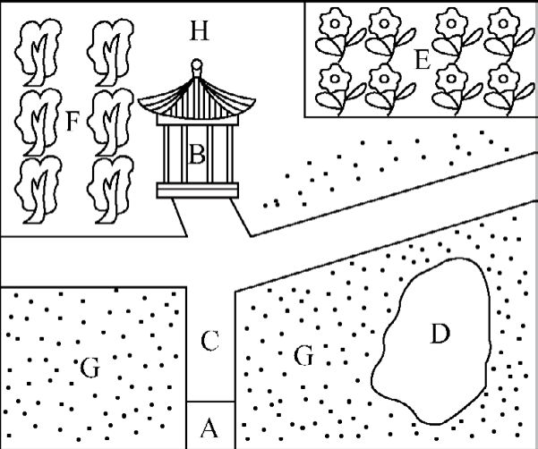

A: gate

B: pavilion

C: path

D: pond

E: flower bed

F: wood

G: lawns

H: stone benches

3．下面是一间卧室的平面图。根据平面图进行描述：

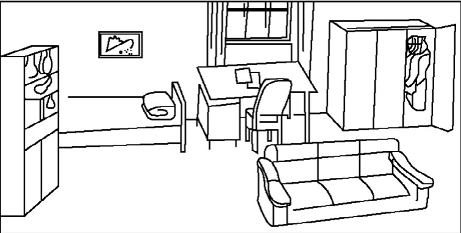

4．用下列细节写一段话。写作之前先把各细节按顺序排列好，最好画出平面图，并定好你所处的位置：

1）The Botanical Garden is large.

2）Most of the flat ground is taken up by peach trees, apple trees and pear trees.

3）An attractive path cuts straight through the garden.

4）A river runs beside the path.

5）On both sides of the river are flowering shrubs.

6）A small hill stands on one side of the river.

7）There are a lot of pine trees on the slope of the hill.

8）Near the hill, tucked into a corner, there is a children's playground with swings, seesaws and model vehicles.

9）One of the pleasant features of the park is that it is entirely surrounded by trees.

5．根据下列题目展开描写：

1）a street you know well

2）your home village or the courtyard where your home is located

3）your favorite reading room in the school library

4．用举例和归纳方式展开

通过举例来展开段落，可以使主题句的抽象意思具体化；生动的例证可以给读者留下一个清晰、有趣、深刻且信服的印象。

**例证** 可以只举一个，也可以举**一组** ：

范文14

This term several useful and interesting courses have been offered. An Introduction to European Culture, for instance, gives us a lot of background knowledge of the history of European philosophy, literature, and arts. From time to time we see slide shows of famous paintings and hear tapes of famous pieces of music, and they make the lectures all the more interesting. American Society and Culture is another course that attracts a large audience. The teacher, who visited the United States not long ago, discusses new trends and changes in American life as well as American history and traditions. We like these and other courses very much, because they help us not only to improve our English but also to broaden our vision.

—Student

【 **分析** 】

在这段中作者举了两个例子来说明为什么有些课程如第一句所说“既有用又有趣”。

下面的段落用几个名人的一系列实例来阐述一个中心思想，将“坚持不懈的调查研究”这个抽象的概念具体化，使内容更生动、有趣。我们可以注意到，举例子时不必每次都使用for example，for instance这样的词语。

范文15

Knowledge often results only after persistent investigation. Albert Einstein, after a lengthy examination of the characteristics of matter and energy, formulated his famous Theory of Relativity, which now acts as a basis for further research in nuclear physics. Using plaster casts of footprints, fingerprints, and stray strands of hair, a detective pertinaciously pursues the criminal. After years of work Annie Jump Cannon perfected the classification of the spectra of some 350,000 stars. Investigations into the causes of polio have provided us with the means for prevention and cure of this dreaded disease only after many years of research. As students, we too are determined in our investigation to find, retain, and contribute to the store of human knowledge.

—Earl Rudolph

范文16

My little niece, a ten-month-old baby, is the loveliest child I have even seen. Her face is like a red apple and her eyes are like bright stars. When you carry her in your arms, she likes to put her arms around your neck. All the grown-ups in the family love her very much and often try to make her smile. But quite often it is she who makes us laugh. Once I winked at her and she smiled. When I did it again, she watched me attentively. Then she tried to imitate. While we closed one eye to wink, she had to close both eyes at the same time, and then quickly opened them again. And that was her way to wink. We all burst into laughter. When we looked at her again, she was staring at us, puzzled, as if she was asking: "What are you laughing at?"

—Student

【 **分析** 】

上面的段落是描述性的，包含了许多细节。首句即是主题句，所有的细节都围绕着这个段首的主题句展开，用的是从概括到具体的展开模式。

另一种通过例子或细节展开段落的方法是从具体到概括，即先叙述细节，把概括性的主题句放在段尾，总结全段的主要意思。

范文17

Whether you do or do not open a gift in the presence of the giver; whether you should or should not turn the plate over to look at the maker's symbol on the back; whether you put your coat on before or after you leave the host's house; whether you eat as quietly or as noisily as possible; whether you carry on a conversation during a meal; whether you walk in front of or behind a seated person; whether it is a friendly or an offensive gesture to put your hand on the arm of the person with whom you are talking—these and a thousand other questions are matters of cultural definition. None of them is inherently right or wrong, and none is good or bad manners except as a society defines it so.

—Ina Corinne Brown

段落中的细节和例子通常按照它们的重要性或趣味性排列：分量轻或趣味性弱的靠前；分量重或趣味性强的置后。

范文18

It was a typical Russian winter. The first snowstorm had turned everything white. The wind was howling, swirling and tumbling over a vast land of ice and snow, freezing and destroying whatever stood in its way. A ragged, misshapen army was staggering and struggling desperately for survival, cold, hungry and decreasing in size every day. The year was 1812. The army was the remnants of Napoleon's expeditionary force which was withdrawing from Russia after receiving its worst defeat. The war with Russia turned out to be a fiasco for Napoleon and had a devastating effect on his career.

—Student

【 **分析** 】

按重要性或趣味性的顺序叙述不仅适用于举例和归纳展开法，也适用于类比和对比展开法以及原因和结果展开法等。

表示举例和归纳的常用词及短语

for example

in substantiation

for instance

to substantiate

for one thing

as an illustration

to illustrate

in one instance

in one instance

in this instance

in other words

as an example

as follows

take (sth. as) an example

let me illustrate

in practice

let me cite as proof

according to statistics

generally speaking

according to statistical evidence

on the whole

课堂练习15 如果采用举例法展开段落，则所有实例都应证实主题句。试摘出以下两段中与中心句无关的细节。

1．主题句：I am fascinated by my grandmother.

论据：

1）My grandmother is about 90 this year.

2）She was born into a well-to-do urban family.

3）She seems never to require the services of a doctor.

4）She has an abiding interest in collecting postcards.

5）She does not have much sense of humor.

6）She believes in everything: festivals, news, TV ads, success, and all the gods.

7）She likes to eat fruit.

8）She hates dogs.

9）She likes the color of a strawberry.

10）She takes a walk in the garden every day.

2．主题句：Male chauvinism is evident in TV commercial advertisements.

论据：

1）Commercials are new in China compared to those in developed countries.

2）Television sets, like air-conditioners, are seen as luxury goods in China.

3）There are two female images in Chinese TV commercials: traditional women busy with household chores and "modern women" who believe that pleasure is the most important thing in life.

4）In TV ads, "modern women" usually invite their boyfriends to buy them presents.

5）A Chinese saying has it that when a man gets to the top, all his family members and relatives get there with him.

6）One sees in a TV ad a young man in nicely-pressed Western-style clothes sitting on a couch reading a newspaper, while his beautiful wife pulls off his socks.

7）Chinese men have got nicknames, like "qiguanyan" (henpecked husbands) or"mofan zhangfu" (model husbands).

8）Men in commercials are confident, career-oriented and energetic. A table of delicious food prepared by their wives is always waiting for them.

9）Chinese commercials are providing a stage for women.

10）"Modern women" appear wise in commercials because they know how to depend on men but evade conventional duties.

课堂练习16 根据下列材料，写一段概括性的说明。

1．日本工人：

1）Japanese workers like work better than anything else.

2）In 1985, Japanese workers worked an average of 2,168 hours a year. By comparison, people in Britain worked 1,952 hours; in the U.S., 1,924; in West Germany, 1,659; and in France, 1,643.

3）Many Japanese workers feel that if they take a week off, they will lose touch with the business and fall behind other people.

4）It is considered bad form in many offices in Japan to leave before the boss. So workers will continue to work until their boss finally puts on his jacket and heads out the door.

2．北京的环境特点：

1）Dust storms used to make havoc of Beijing for an average of 20 days a year. Now the number of such awful days stands at around 10 annually.

2）The volume of falling dust and suspended particles in the air in the capital declined 19 and 12 percent respectively over the last five years.

3）Over 70 percent of the farmland around Beijing now enjoys protection given by the various forms of tree belts.

4）The speed of the wind over the farmland is 30 to 40 percent slower, humidity has risen 5 to 15 percent, and grain output is generally 10 to 20 percent higher.

5）Grain output in the same area increased by over one-fifth after the fields were surrounded by trees.

6）Great efforts have been made in the past ten years to plant trees and build a forest network around Beijing.

7）Trees are planted in an area larger than the 33,000 hectares around the Miyun Reservoir.

作业4 段落写作练习。

1．Do you think you are an optimist or a pessimist?

按题目内容举一例说明你是乐观主义者还是悲观主义者。

2．选择具有以下所列特征的一个人物，试描写他/她一天的生活：

1）a teacher who is meticulous

2）a roommate who is considerate

3）a student who is nervous before an examination

4）a girl/boy who is lazy

5）a classmate who is hardworking

3．描写练习：

1）你仰慕的一个人

2）你印象深刻的一个地方

4．试根据以下题目用举例和归纳的方式写一个段落：

1）People in Beijing eat well and dress fashionably.

2）It is useful to learn a second foreign language.

3）TV and the VCR are increasingly replacing the cinema.

4）My hometown is undergoing rapid modernization.

5．用类比和对比方式展开

类比和对比是写作中常用的方法。我们通常对比中国的过去和现在，对比中西方文化，对比汉语和英语等等。通过类比和对比，我们往往可以对事物有一个更加清楚的认识。

严格地说，**类比** 用于指出同一范畴的两个或多个人或事物之间的**相似之处** ，而**对比** 则用于指出他/它们之间的**不同之处** 。但实际上，类比和对比常常同时使用，原因是人们在议论两个人或事物时，往往既提出二者的相似性，又注意到他/它们之间的差异。

用类比和对比的方法展开段落，通常有**两种** 做法。第一种称为**整体类比** 或**整体对比** 法，即在全面阐述完一事物的特点之后，再摆出与之比较的另一事物的全部特点。需要注意的是，进行类比或对比的两事物的方面应一致，顺序应相同，否则就会相互脱离不成对比。第二种做法称为**交替类比** 或**交替对比** 法，即逐条比较或对比两个人或两事物的特点。

下面的段落中使用的是交替类比法：

范文19

The same qualities that make people good house guests make them good hospital patients. Good house guests can expect a reasonable amount of service and effort on their behalf, and hospital patients can also. Guests have to adjust to what is for them a change, and certainly hospital patients must do the same. No one appreciates a complaining, unpleasant, unappreciative house guest, and the hospital staff is no exception. House guests who expect vast changes to be made for their benefit are not popular for long. Certainly nurses and other personnel with their routines feel the same way about patients in their care. Just as house guests must make adjustments to enjoy their visits, so patients must make adjustments to make their stays reasonably pleasant and satisfying under the circumstances.

—Robert Friedman

范文20

The television western of several years ago differs greatly from the western of today. Ten years ago, for example, the swindler or bank robber in a western could be identified not by the crimes he committed so much as by the color of the clothing he wore—which was black. Today the television western reveals the villain by mannerisms and personality. At one time, every western had a superhuman, invincible "good guy" with whom the viewers could identify because he too lived out on the farm. Currently, the central figures of the west are average people who may live on a middle-class street in any part of the country. They are characters like the bus drivers, mail clerks and accountants who live next door to you in suburbia. At night they come in off the horses to ride the television range. They become persons who respect others, drink and smoke only just a bit, and are able not only to outshoot the "bad guy", but also to outsmart him with good common sense.

—Ron Sengal

【 **分析** 】

在上面的段落中，作者使用交替对比法指出昔日和当今电视中西部片的几点不同之处，但并没有详细讨论。他仅仅提及老西部片的几个特色，然后叙述新西部片在这几方面有何不同。

当我们想**深入** 地讨论两事物的相似特点而这些相似的特点不多，但内涵比较复杂、需要详细解释时，可以先详尽阐述一事或一人的各种特点然后再同相比者进行全面的比较。这就是**整体比较法** 。

在下面的范文中，作者首先描述尤利西斯·格兰特的各种特点，然后再对应逐一描述罗伯特·李的特点。

范文21

Although Ulysses S. Grant and Robert E. Lee were fierce adversaries during the Civil War, their lives, both military and nonmilitary, had a great deal in common. Grant descended from a family whose members participated in the American Revolution. He received his commission of second lieutenant from West Point and served in the Spanish-American War. He was later summoned by President Lincoln to assume command of the Union Forces during the Civil War. After the Civil War, Grant suffered financial problems and was forced to declare bankruptcy. Lee also descended from a family which engaged in the American Revolution. He, too, received his commission from West Point and later fought in Mexico during the Spanish-American War. His fame as a military strategist during the Civil War, when he was the commander of the Confederate armies, is well known. Although it is not always pointed out by historians, he, like Grant, had financial difficulties after the Civil War and was compelled to declare bankruptcy. By securing a post as president of Washington College, he was able to avoid additional poverty.

—Gordon Sacris

上面一段中所运用的方法也可用于对比。

范文22

There is an essential difference between a news story, as understood by a newspaperman or a wire-service writer, and a newsmagazine story. The chief purpose of the conventional news story is to tell what happened. It starts with the most important information and continues into increasingly inconsequential details, not only because the reader may not read beyond the first paragraph but because an editor working on galley proofs a few minutes before press time likes to be able to cut freely from the end of the story. A news magazine is very different. It is written to be read consecutively from beginning to end, and each of its stories is designed, following the critical theories of Edgar Allen Poe, to create one emotional effect. The news, what happened that week, may be told in the beginning, the middle, or the end; for the purpose is not to throw information at the reader but to seduce him into reading the whole story, and into accepting the dramatic (and often political) point being made.

—Otto Friedrich

比较法中有一种特殊的形式——**比拟** ，即描绘属于两个不同范畴事物的**明显相似** 之处。

范文23

Electricity is transferred from one place to another in much the same manner as water. A water pipe performs the same function as a length of wire. The pipe carries water to its point of use in the same manner as wire carries electricity to its point of use. A blown fuse results from the same thing as a burst water pipe. Both give out due to extreme pressure applied to the walls of the carrier. A switch is to electricity what a faucet is to water. Both of them control the flow of the substance. Since electricity and water have some common properties, understanding the job of the plumber will help understanding the work of the electrician.

—John Brower

范文24

Some old people are oppressed by the fear of death... The best way to overcome it—so at least it seems to me—is to make your interests gradually wider and more impersonal, until bit by bit the walls of the ego recede, and your life becomes increasingly merged in the universal life. An individual human existence should be like a river—small at first, narrowly contained within its banks, and rushing passionately past rocks and over waterfalls. Gradually the river grows wider, the banks recede, the waters flow more quietly and in the end, without any visible break, they become merged in the sea, and painlessly lose their individual being. The man who, in old age, can see his life in this way, will not suffer from the fear of death, since the things he cares for will continue...

—Bertrand Russell

【 **分析** 】

**比拟** 尤其适用于解释**抽象的思想** 。通过比拟，人们对无法通过感官体验到的概念将更容易理解。从伯纳德·罗素所写的段落中我们可以看到，作者用河流比拟人生十分精辟。人生与河流是两个完全不同的事物，作者用人们熟悉的河流来生动地阐述深奥难懂的人生，可以给人留下难忘的印象。

表示类比和对比的常用词及短语

**类比：**

similar to

almost the same as

similarly

at the same rate as

as

(just) as…so

like, alike

in like manner

likewise in

the same way

both

to have…in common

correspond to

common characteristics, etc.

correspondingly

to be parallel in

resemble

equally important

resemblance

accordingly

**对比：**

unlike

differ from

while

different from

whereas

in contrast to

however

in opposition to

still

on the contrary

nevertheless

on the other hand

otherwise

on the opposite side

but

less/more/faster…than

although

despite, in spite of

even so

year ago...today

not only...but also

the first...whereas the second

the former...the latter

here...there

on the one hand...on the other

then...how

this...that

once...how

some...others

课堂练习17 指出下列句子哪些是类比句,哪些是对比句。

1．Though both are forms of humor, comedy is different from satire.

2．In 2050 the world will surely be different from what it is today.

3．Fashions in furniture change just as clothing fashions do.

4．Buying a car requires as much skill as selling one.

5．Badminton is as important a sport in Indonesia as football is in the United States.

6．There is more hard work in writing than in physical labor.

7．Ballet is a more exhausting art than gymnastics.

8．"Friendship," like "love," is often discussed but seldom understood.

课堂练习18 完成下列对比句，必要时加词或短语。

1．TV and newspapers are _____in many ways even though their aims may be the same.

2．Sound travels _____through _____than through _____.

3．Before 1880 many people died of smallpox; _____, the percentage of deaths from smallpox is small today.

4．Some children grow _____than other children because of nutritional differences.

5．_____to living on the farm, living in the city is an intense struggle to survive in a concrete wasteland.

6．Per capita earnings in Japan _____those in South Korea.

课堂练习19 完成下列类比句，必要时加词或短语。

1．The development of transportation and the development of communications_____in many ways.

2．Anshan in the Northeast of China and Panzhihua in the Southwest are _____steel centers.

3．Despite centuries of change, human beings and their primitive ancestors have many traits _____.

4．_____badminton _____table tennis requires a large playing area.

5．Although the last days of the Roman Empire may at first appear very different from those of the United States today, there are ominous _____.

作业5

1．根据下列素材，用类比法或对比法撰写段落。

1）主题句: Raising houseplants involves nearly as much care and knowledge as raising children.

**Houseplants:**

(1) Raising houseplants involves much care and knowledge.

(2) Plants are sensitive to their environment.

(3) A plant will grow faster and be much healthier if it is raised in an environment of tender, loving care.

(4) The owner of houseplants must be willing to provide the best possible care for his plants.

(5) The owner of houseplants must know which of his plants need direct sunlight and which need to be kept in shady places.

(6) The owner of houseplants must know how much water each plant requires for the best growth and appearance.

**Children:**

(1) Raising a child involves much care and knowledge.

(2) Children are sensitive to their environment.

(3) Parents must have a basic knowledge of their children's needs in order to provide what is necessary for their best physical and mental development.

(4) A child will be happier and healthier if his parents love and nurture him.

(5) A child needs time and energy from his parents to play with him, to talk to him, and to care for him.

2）主题句：The works of both Ernest Hemingway and William Faulkner contain a richness of meaningful substance and other qualities which help maintain these authors' places among America's greatest writers. Their writing styles, however, are remarkably different.

**Hemingway:**

·His sentences are usually short, simple, and straightforward.

·His sentences are remarkably lucid.

·He doesn't overwhelm the reader with long, "purplish" words nor with complicated sentence structure.

(4) Much of what he expresses is conveyed by understatement.

**Faulkner:**

·His writing is much more involved.

·He uses an elaborate stream-of-consciousness technique to reveal the psychological conflicts within his characters.

·His sentences are often long and complex.

·Sometimes he carries his reader through several time periods within the same sentence.

2．按下列题目写段落：

·a song from my parents' youth and one from today

·the radio audience and the television audience

·the Summer Palace and the Purple Bamboo Park

·two of my friends

·the "McDonald" fast-food restaurant and a Chinese restaurant

6．用原因和结果方式展开

日常对话中，我们常常问、也常常回答“**为什么** ”的问题，可见分析原因和结果是司空见惯的事情。

分析原因和结果，要力求**理由充足** ，**逻辑性强** 。事件发生的原因往往不止一个，后果也不止一个，因此在进行分析时，要尽量做到讨论全面，选材缜密。

主要可通过**两种方法** 安排用原因和结果方式展开的段落：

（1）**先写出结果** ，再用主要篇幅一一写出原因。如主题句子是：

In the past few years, higher education has become less important to young people than it was previously.

这里说的是结果，接下来应该逐条讨论产生这种结果的原因，如竞争过于激烈，就业相对容易，高等院校所授课程偏于陈旧等等。

（2）**先叙述原因** ，再写出或预测结果。如主题句是：

More and more fertile land is taken up by new buildings.

在段落其余部分应该写出这一现象造成的种种后果，如粮食减产、环境污染加剧、失业农民大量涌入城市等等。

范文25

One might wonder why, after the Norman Conquest, French did not become the national language, replacing English entirely. The reason is that the Conquest was not a national migration, as the earlier Anglo-Saxon invasion had been. Great numbers of Normans came to England, but they came as rulers and landlords. French became the language of the court, the language of the nobility, the language of polite society, the language of literature. But it did not replace English as the language of the people. There must always have been hundreds of towns and villages in which French was never heard except when visitors of high station passed through.

—Paul Roberts

【 **分析** 】

上面这段话的首句（即主题句）提出了一个问题，即诺曼人对英国的征服为什么没有像预想的那样把英国变成一个讲法语的国家。这一问题点出了诺曼人征服英国的这一结果，接下来各句就主题句展开讨论，解释其原因。

范文26

This surge of demand for oil will soon begin to send shock waves through the American economy and transportation system. The impact of these tremors can already be anticipated: to the consumer they signal the end of a long love affair with the car, and to Detroit they offer an early warning that its 1985 growth aims are dangerously unrealistic. Unless we exercise foresight and devise growth limits policies for the auto industry, events will thrust us into a crisis that will lead to a substantial erosion of domestic oil supply as well as the independence it provides us with, and a level of petroleum imports that could cost as much as $20 billion to $30 billion per year. Moreover, we would still be depleting our remaining oil reserves at an unacceptable rate, and scrambling for petroleum substitutes, with enormous potential damage to the environment.

—Stewart Udall

【 **分析** 】

上段的主题句先提出一个事实作为根据，接着作者谈它的后果，预测石油需求的猛增将对美国社会带来哪些影响。

表示因果关系的常用词及短语

so

result in

thus

as a result (of)

hence

the result of

since

the effect of

due to

have an effect on

owe...to...

It follows that

owing to

as

out of

so that

thanks to

so...that

because

now that

because of

seeing that

the cause of

for fear that

for this reason

such...that

the reason for

so as...to

consequently

make...possible

the consequence of

make it possible/impossible for...to...

therefore

accordingly

课堂练习20 分辨下列句子哪些表达因果关系，哪些描述时间顺序。

1．Peter and Mark went to the park yesterday. They had barbecue there.

2．Footsteps echoed down the empty path toward Mary, and she was afraid.

3．John has a Vitamin C deficiency. He has a skin disease.

4．Bob was very sleepy. He sat nodding in his car.

5．There was a loud knock at the door downstairs. The knock woke me out of a sound sleep.

6．Susan did not feel well. She did not turn up.

课堂练习21 通过句子的题目确定哪些句子表述原因，哪些句子表述结果。在表述原因的句子前面横线上填字母C；在表述结果的句子前面横线上填字母E。

1．题目：Music in the United States

_____1）Popular music showed a definite change in the 1950s—a movement away from the big band sound that had appealed to those growing up in the 1920s, 1930s, and 1940s.

_____2）Teenagers became more affluent and thus had the money to buy records by performers like Elvis Presley and Ray Charles.

_____3）The black population finally had the money in the 1950s to support the singers and musicians they had preferred for years.

_____4）A large proportion of the adult white population that had been poor during the depression began to rebel against the sophisticated lyrics and sounds of the big band musicians.

_____5）The new affluence of groups of people who had previously had little money to spend on entertainment paved the way for the emergence of gospel, blues, and rock music.

2．题目：Tornados

_____1）Tornados are formed when warm, moist air spreads northward, meeting with cold air flowing from the north and west above it.

_____2）The meeting of cold and warm air starts the characteristic circular motion.

_____3）The circular motion quickly builds up and becomes forceful enough to tear buildings apart and uproot trees.

_____4）Not only are tornados able to move huge objects but they also occasionally do odd things, such as stripping a chicken of its feathers quickly.

3．题目：Drunk drivers

_____1）Excessive amounts of alcohol cause one to lose one's sense of responsibility.

_____2）Excessive amounts of alcohol slow reaction time and seriously impair depth perception.

_____3）The inebriated driver is unable to make quick logical decisions and is often responsible for accidents causing serious injuries or death.

_____4）Drunk drivers are dangerous.

_____5）Drunk drivers pose a serious threat to themselves as well as to others.

作业6 任选下列题目撰写一个段落。

1．CAUSES OF

1）your headaches and depressions

2）the improvement of transportation in Beijing (or your hometown)

3）the success of a person you know well

4）the failure of a TV program

2．EFFECTS OF

1）low wages for teachers

2）multiple-choice exams

3）college students doing part-time jobs

4）one child per family

5）the sharp increase in entrance fees to parks and museums in Beijing

7．用分类方式展开

**分类** 就是根据事物的**特点** 分别**归类** 。树木、河流、城市、公司、大学生等等各种人或事物都可根据它/他们的共性和差别分类。比如我们可按河流的宽度、长度和深度予以分类。苹果也可以根据它们的大小、产地、颜色、价格或质量分类。

使用分类方法展开段落的关键在于把握好类别的**平行对应性** 。例如，我们可以把体育活动分成田径、游泳、球类、体操等几大类。但是如果把它们分成跳高、球类、跑步、体操和自由泳等几类，我们就破坏了事物类别的平行对应性；因为球类和体操本身是两大类别，而跳高、跑步则属田径类下面的子项目，不能混为一谈。因此，在分类时，要注意事物类别平行，不能把不同类别的事物归在一起。

另外，分类时还应避免重叠。举例说，将同一宿舍的同学分类，可以把他们的籍贯、所学专业、兴趣爱好等作为分类原则。而应避免以性格、特点等来分类，犯重叠的错误。例如，把同学们划分为逻辑思维强的、爱读书的、做事细心的、有同情心的这样几类人，就很可能会遇到一个同学兼有几类特征的情况，这就是分类重叠，失去了分类的意义。

在下面的段落里，作者把藏书者分为三类，然后逐一加以描述：

范文27

There are three kinds of book owners. The first has all the standard sets and bestsellers—unread, untouched. (This deluded individual owns wood pulp and ink, not books.) The second has a great many books—a few of them read through, most of them dipped into, but all of them as clean and shiny as the day they were bought. (This person would probably like to make books his own, but is restrained by a false respect for their physical appearance.) The third has a few books or many—every one of them dog-eared and dilapidated, shaken and loosened by continual use, marked and scribbled in from front to back. (This man owns books.)

—Mortimer J. Adler

下面再看两个范文：

范文28

According to Xiao Li, the fifteen students of his class fall into three groups. Seven of them work hard and study well. They always get good marks in examinations and are often praised by the teachers. Li calls them "good students." The monitor, the secretary of the Youth League branch, and the captain of the class volleyball team, are quick in finding out what their fellow students are interested in or what they should do as a collective. They always organize proper activities at the proper time, so Li calls them"good organizers." Four other students are very kind to their classmates, always ready to lend them a helping hand. They help to clean the classroom and the corridor even when they are not on duty. Li says that they are "good fellows." "What about yourself?" someone asks him. "I'm a group by myself—a good observer."

—Student

范文29

Every educated person has at least two ways of speaking his mother tongue. The first is that which he employs in his family, among his familiar friends, and on ordinary occasions. The second is that which he uses in discoursing on more complicated subjects, and in addressing persons with whom he is less intimately acquainted. It is, in short, the language which he employs when he is 'on his dignity,' as he puts on evening dress when he is going to dine.

—J. B. Green and G. L. Kittredge

【 **分析** 】

上面第一个范文的作者很有幽默感，尽管他对同班同学的分类不科学，但达到了他的写作目的。第二个范文的作者讨论讲母语的两种方式，他在段落中使用了“至少”这个词表示可能还有其他方式。

表示分类的常用词及短语

classify

classifications

divide

divisions

similar/similarities

dissimilar/dissimilarities

different/differences

opposite/opposing

kinds

aspects

attributes

types

factors

characteristics

classes

sources

qualities

parts

regions

categories

times/eras

according to...

fall into...categories

with respect to...

can be divided into...kinds/types/classes/parts...

课堂练习22 分辨下列句子，在表达归纳的句子前面横线上填字母G，在表达分类的句子前面横线上填字母C。

_____1．Democracy is a state of mind.

_____2．Some sports require as high a degree of eye-mind-hand coordination as brain surgery.

_____3．Gamblers fall into several classes, depending upon what their stakes are.

_____4．Students should not be allowed to smoke in the classroom.

_____5．Many aspects of the American character can be attributed to the American frontier.

_____6．The history of the United States as reflected by the concentration of people in cities can be divided into two clearly distinguishable periods.

_____7．A number of foreign countries were directly involved in U.S. territorial expansion.

_____8．A wild stallion is powerful and fierce.

_____9．Everyone has three kinds of "friends" he wants to forget.

课堂练习23 填充下列各项。

1．College students can be classified according to the following standards:

1）academic achievement

2）attitude toward politics, friendship, and so forth

3）____________________

4）____________________

5）____________________

6）____________________

7）____________________

8）____________________

2．Means of transportation can be classified according to the following standards:

1）speed

2）size

3）____________________

4）____________________

5）____________________

6）____________________

作业7

1．用分类法扩充下面的素材。

1）题目：My Classmates

(1) their hometowns

(2) their majors

(3) their interests and hobbies

(4) their family backgrounds

2）题目：The Buildings on Our Campus

(1) their appearances

(2) their sizes

(3) their functions

2．用分类法按下列题目写段话。

1）the parks I have been to

2）the books I like to read

3）the movies I have seen

4）my clothes

5）the sports I enjoy

8．用定义方式展开

有时，为了避免对一个不熟悉的、多义的词、术语或概念产生疑问或误解，需要阐明它的定义。

给一个词或一个术语下定义的基本方式有三种：用一个同义词，或用一句话，或写一个段落，甚至写一篇论文。例如“修长即是细长”，这是用一个同义词下定义；“粮栈是储存粮食的地方”，这是用一句话下定义。但是，我们常常会遇到含义复杂、意思抽象的词语或概念，这时不得不用一个段落甚至一篇论文来下定义；同时还需运用举例、类比、比拟、分类及分析原因和结果等方法才能使读者对其定义有一个明晰完整的了解。

给一个词语或概念下定义时要注意以下几点**原则** ：

第一，要**避免循环定义** 。例如，“民主即是民主进程”，“天文学家是指研究天文学的学者”都属于循环定义。循环定义仅是一种简单的重复，达不到阐明内涵的目的。

第二，在给意思抽象的词语或概念下定义时，要**避免仅列出一系列同义词** 的做法。如有一个段落是这样开头的：“什么是想象力呢？我认为它是大脑对事物形成印象的能力，是产生新思想的能力，是在写作中运用形象的才能，是善于为虚幻的事物、场景和状态注入现实因素的偏好……”明眼人一看就知道，作者是从词典里找出了一组定义并把一堆抽象的术语罗列在一起，期望读者能接受其中的某一个定义。这种下定义的方法不但枯燥、死板，而且没有把“想象力”这一含义复杂的词语的内涵充分发掘出来，因而是不可取的。

第三，要**避免带有个人成见** 的定义。定义应该是客观的，贴近实际情况的，不应含有感情色彩。如“国有企业即高消耗低效率企业”就是带有明显贬意的定义，而“国有企业是工人当家做主的样板”则是带有偏爱色彩的定义。这两类定义可以作为辩论中的论点提出，但作为定义是不恰当的。

什么样的定义才是清楚、客观的呢？请看下面两个范文：

范文30

A "liberated woman" is simply a woman who controls her own life, rather than allowing it to be controlled by other people, traditions, or expectations. A "liberated woman" can be found pursuing any line of work, including housework, or no work at all. She may or may not be married; she may or may not have borne children. She may belong to any race; she may have attained any age. She may be poor or wealthy, educated or illiterate. She need have only one trait in common with her "liberated sisters": she makes her own choices, whether they be the colors on her walls or the last advanced degrees she seeks. She acts of her own volition, responsible to herself, and not out of fear of what her mother, lover, or neighbor might say.

—Klamer W. Harp

范文31

A kachina doll is a small, carved, wooden, humanlike representation of the supernatural beings worshiped by the Hopi Indians. Kachinas are not gods: as their name denotes, Ka for respect and china for spirit, they are respected spirits of the dead, of mineral, plant, bird, animal, and human entities. Kachinas are not gods, but rather they are intermediaries or messengers to the gods. In the polytheistic Hopi society, all plants and animals, as well as some inanimate things, have spirits which the Hopi visualize in human form. When a Hopi goes to gather yucca roots to use as shampoo, he prays to the spirit of the first plant he finds and passes it by gathering the second one. When he goes hunting, he prays to the spirit of the game and apologizes for having to take its life. Thus the spirits of men, animals, and plants are the kachinas most often carved into kachina dolls.

—LaDean McConahay

表示定义的常用词及短语

to define

to explain

in definition

in explanation

in other words

by...is meant

to clarify

to paraphrase

in clarification

device

method

type

property

kind

condition

category

attribute

课堂练习24 指出以下定义哪些是准确的，哪些是不准确的。

1．Famine is extreme scarcity of food in a region.

2．Gambling is a way to make money without working.

3．A loom is a machine for weaving cloth.

4．A proof is a particular piece of evidence.

5．To enlighten is to give knowledge, and to free from ignorance, misunderstanding, or false beliefs.

6．Neutrality is a state between war and peace.

7．A hospital is a place where a doctor works.

8．A sentry is a soldier posted to guard and to keep watch.

9．A sear is a mark remaining on the surface of skin.

10．To walk is to move each foot forward in turn.

作业8 根据个人经历或观察用定义法将下列题目写成段落。

1．the Chinese saying "show off one's skill with an ax before Lu Ban"

2．"Master Dongguo"

3．superstition

4．optimism

5．male chauvinism

6．feminism

9．结合几种方式展开

上面我们介绍了展开段落的多种方法。有时候在一个段落中使用一种方法就够了，但是，有的作者为了进一步阐明观点并给读者留下深刻的印象，也常常在一个段落中同时使用几种方法，使内容更加丰富有趣，有说服力。请看下面的范文：

范文32

Kintay often told Kizzy stories about himself. He said that he had been near his village in Africa, chopping wood to make a drum, when he had been set upon by four men, overwhelmed, and kidnapped into slavery. When Kizzy grew up and became a mother, she told her son these stories, and he in turn would tell his children. His granddaughter became my grandmother, and she pumped that saga into me as if it were plasma, until I knew by rote the story of the African, and the subsequent generational wending of our family through cotton and tobacco plantations into the Civil War and then freedom.

—Alex Haley

【 **分析** 】

我们可以明显看到：作者在上一段里使用了两种段落展开方法，即按时间展开法与用原因和结果方式展开法。

范文33

The Eastern religious movements [in the United States] are made up almost exclusively of white, educated, middle- and upper-middle-class young people. Most have at least begun college, although some have dropped out after a year or two. Men and women seem to participate in fairly equal numbers, but men control the leadership groups. There is no predominance of any particular regional background, although more of the devotees seem to come from urban than from rural areas, probably because the movements are generally based in cities.

—Harvey Cox

【 **分析** 】

上面的段落用了不少细节来阐述第一句的内容，如第二句和第四句都以事实证明了概括性的第一句。同时作者也使用了分类法，指出宗教积极分子有大学生，包括辍学者；有男也有女；有来自城市的也有来自农村等等。作者分类时以是否参与Eastern religious movements为划分原则，下面又将educated的大学生按照在学和辍学划分；将人群按性别划分；按居住地区是在城市还是农村划分。

参考答案

课堂练习1

范文1的首句和范文2的末句。

课堂练习2

每一个段落的首句。

课堂练习3

1．Speeding on the road can be highly dangerous.

2．Different colors indicate different meanings to people.

3．Roads play a vital role in history and in our daily life.

4．A cat behaves very differently from a dog.

课堂练习4

此段具有连贯性。第2、3、4句讲述莎士比亚笔下的人物如何活在读者和观众的心中。段落其余的句子说明莎士比亚能够成功的原因。

课堂练习5

1．第1句。

2．第4句和第5句。

3．For example, too, certainly, eventually.

课堂练习6

3, 5, 1, 7, 4, 2, 6, 8, 9

课堂练习7

1．when, then, shortly after, not long after, when, as I look back, now

2．including the fact that, that is, whereas, one reason, because as a result, in a few months, so that

课堂练习8

1．A．In fact

B．also

C．Furthermore

D．For example

E．In addition

2．A．Even though

B．If

C．When

D．Because

E．First

F．Then

课堂练习9

1．they: the nobles of Persia

they: the nobles of Persia

their: the youths'

his: the monarch's

their: the youths'

2．their: Ferdinand and Isabella's

him: the admiral

his: the admiral's

him: the admiral

He: the admiral

their: the Indians'

They: Ferdinand and Isabella

him: the admiral

he: the admiral

They: Ferdinand and Isabella

him: the admiral

课堂练习10

Philately is an interesting hobby. Every time I open my albums and look at the stamps I've collected over the years, I learn something new. On many of them are printed drawings or pictures of rare birds, animals, trees or flowers. Under a magnifying glass they look very beautiful, and they help to increase my knowledge of nature. On other stamps there are portraits of historical figures, such as Qu Yuan and Dr. Sun Yatsen, George Washington and Chester W. Nimitz. Whenever I see an unfamiliar name, I will try to find some information about the person by consulting an encyclopedia. In this way I have come to know something about quite a few people who are famous for one reason or another. Some of my friends and relatives who know I am interested in stamps often show me used envelopes. If I see a stamp which I have never seen before or I haven't got yet, I will ask them to give it to me, and it seems that they are always kind enough to oblige me. It is always a delight to add a new stamp to my collection, and the more stamps I have, the more interested I am in philately.

课堂练习11

1．Don't talk while she is singing.

2．After the law had been passed this form of crime ceased.

3．The man fell asleep in the auditorium while the lecturer was speaking about avoiding boring topics.

4．Tom had left the room before he brought some water to his sister.

5．The train had departed when we reached the station.

6．She fell down while she was getting off the bus.

课堂练习12

when, Before, As, then, before

课堂练习13

第1段 E, C, B, D, F, A, G

第2段 D, A, C, E, G, B, F

课堂练习14

3, 7, 4, 6, 5, 1, 2

课堂练习15

1．5），7），8），9）

2．1），2），7），9）

课堂练习16

1．Japanese workers are well-known for being hard-working and conscientious of their duties.

2．Beijing's environment has been effectively changed for the better in the last five years.

课堂练习17

1．contrast

2．contrast

3．comparison

4．comparison

5．comparison

6．contrast

7．contrast

8．comparison

课堂练习18

1．different

2．faster, water, air

3．however

4．faster

5．In contrast

6．are higher than

课堂练习19

1．are similar

2．both

3．in common

4．Neither...nor

5．similarities

课堂练习20

1．chronological order

2．cause and effect

3．cause and effect

4．cause and effect

5．cause and effect

6．cause and effect

课堂练习21

1．1）E

2）C

3）C

4）C

5）C

2．1）C

2）C

3）E

4）E

3．1）C

2）C

3）E

4）E

5）E

课堂练习22

1．G；2．C；3．C；4．G；5．C；6．C；7．C；8．G；9．C.

课堂练习23

1．3）sex

4）age

5）nationality

6）physical health

7）psychological health

8）family background, etc.

2．3）safety

4）cost

5）comfortableness

6）service, etc.

课堂练习24

1．good

2．inadequate

3．good

4．good

5．good

6．inadequate

7．inadequate

8．good

9．good

10．inadequate

第五章 完整的作文

写作课的根本目的是培养学生撰写完整作文（或课程论文、学位论文、科研论文等）的能力。写作教师一般要求学生撰写500至1000字的短文,内容涉及个人的生活、学习、经历以及对感兴趣的问题所持的观点；教师并不要求，或者很少要求学生写小说、戏剧或者诗歌。因此，学生主要是学习怎样撰写描写文、记叙文、说明文和议论文四大类文章。下面我们首先讨论撰写作文的步骤。

I．好作文的标准

作文和段落一样，应该具有**一致性** ，也就是说，文中所有的事例、观点都涉及并有助于表达文章的论题或中心思想。无关的内容，尽管有趣，也应割舍。人们在说话、做报告时可以离题插几句与主题无关的话，但是写作时不可如此。

作文的各个段落都应该有各自的中心思想，段落的**安排顺序** 应该合乎逻辑，这样文章才能成为有机的整体。文章如何展开取决于题材和体裁，一个办法是按照段落表达的观点的重要性来安排，把最重要的放在最后，文章以高潮收尾。

写文章和绘画一样，各部分的**比例** 应协调。主要的事例、观点所占篇幅应大于次要的事例、观点。文章中间的主干部分大约占全文篇幅的70%~80%比较合适。开篇和结尾固然重要，但须简洁。

好作文应该有**重要、有趣、新鲜** 的内容，而且语言表达**清楚、准确、得体** 。

请看在下文“To Be Informed and to Be Enlightened”中Mortimer J. Adler和Charles Van Doren是如何区别informed和enlightened这两个概念，又是怎样用语言表达的：

范文1

[1] Getting more information is learning, and so is coming to understand what you did not understand before. But there is an important difference between these two kinds of learning.

[2] To be informed is to know simply that something is the case. To be enlightened is to know, in addition, what it is all about: why it is the case, what its connections are with other facts, in what respects it is the same, in what respects it is different, and so forth.

[3] This distinction is familiar in terms of the differences between being able to remember something and being able to explain it. If you remember what an author says, you have learned something from reading him. If what he says is true, you have even learned something about the world. But whether it is a fact about the book or a fact about the world that you have learned, you have gained nothing but information if you have exercised only your memory. You have not been enlightened. Enlightenment is achieved only when, in addition to knowing what an author says, you know what he means and why he says it.

[4] It is true, of course, that you should be able to remember what the author said and know what he meant as well. Being informed is prerequisite to being enlightened. The point, however, is not to stop at being informed.

【 **分析** 】

尽管短文写的是我们熟悉的内容，却仍然能够引人注目，因为许多人都没有意识到作者提及的informed和enlightened的区别。短文不仅让我们增加了知识，而且有启发性，其结论有教育意义。

短文区别两个概念的用语清楚、准确、得体。作者在第一段中表达的中心思想是：there is an important difference between being informed and being enlightened。在后面的三段里，他们讨论二者的区别，并用实例说明，在讲解完毕二者之间的关系后得出简短有力的结论—— The point...is not to stop at being informed.

可以看出作者的目的是告诉人们不要仅仅满足于informed，而应该继续学习直至enlightened。他们的写作对象是一般读者，因此使用的大多是常用词汇。同样我们在下笔前，也要考虑写作的**目的** 和**对象** ，并在此基础上有针对性地选择使用的语言和体裁。

II．撰写作文的步骤

1．总体规划

在动笔前应做好充分的准备。写作犹如盖房，通常建筑工人在动工前手头都有蓝图并准备好了足够的材料。写作者在下笔前也应事先有个规划，同时要收集足够的资料。

1）写下有关实例

有了写作题目后，学生应首先考虑所有与题目有关的实例，随想随记，不必在意先后次序。

2）确定作文的主题

作文的主题即其主要观点或中心思想，是列举实例后所得出的结论。

3）重审列出的实例，撰写提纲

主题确定后，应重新审查列好的实例清单，删去与主题无关或意义不大的细目，然后把剩下的条目按逻辑顺序重新排列，写出提纲。

比如说作文题目是“校图书馆”，学生可能想到并写出以下几条：

·A large number of useful books

·All kinds of dictionaries and reference books

·Computers used to find books and useful information

·The reading-rooms spacious and quiet

·The librarians patient and helpful

·Closed on Sundays and holidays

·Crowded in the evening

·Students leave books on chairs to reserve seats

·A few newspapers and many magazines from abroad

·Students are not allowed to take schoolbags into the reading-rooms

·Seniors would not be able to write their graduation papers without using the library

·Teachers go to the library frequently

...

作文的主题可能是：

·The library is a nice place to work in.

·The library plays a very important part in a student's life.

·The work of the library needs improvement.

如果我们选定（2）为主题，在重新审查上面的清单时，就会发现所列细目中有的与主题无关或不十分重要，删去这些部分后，就可以用剩下的细目来准备提纲了，写出的提纲可能是这样的：

**题目：The School Library**

**主题：The library plays a very important part in a student's life.**

**提纲：**

Ⅰ．Students have to borrow books from the library.

A．They need reference books for their elective courses.

B．They may want to read novels and plays.

Ⅱ．They read newspapers and magazines in the library.

A．Many new magazines are on display in the First Reading-Room.

B．There are newspapers from all over China.

C．There are newspapers and magazines in many foreign languages.

D．ack numbers may be borrowed at the counter.

Ⅲ．Students need the library all the more in their junior and senior years.

A．The library provides them with books for their research.

B．They would not be able to write their graduation papers without using the library.

（1）提纲类型

上面的提纲将作文的中心思想分成若干部分，每一部分由若干段落组成。英文提纲一般按罗马数字、阿拉伯数字以及英文字母排列：

**主题（中心思想）**

Ⅰ．简介

Ⅱ．主要观点

A．从属观点

B．从属观点

1．阐明观点的细节

2．阐明观点的细节

a．实例1

b．实例2

Ⅲ．主要观点

A．从属观点

B．从属观点

1．阐明观点的细节

2．阐明观点的细节

3．阐明观点的细节

C．从属观点

Ⅳ．结论

常见的提纲有两种：题目式提纲（topic outline）和句子式提纲（sentence outline）。**题目式提纲** 由名词及其修饰语组成，或由与名词作用相当的动名词短语、动词不定式短语组成。题目式提纲简单明了，全文内容一目了然。下面是有关对外贸易的题目式提纲：

**题目式提纲**

**Thesis: Foreign trade is beneficial to and indispensable for all nations.**

Ⅰ．Introduction: the foundation of foreign trade

Ⅱ．The necessity of visible trade

A．Lack of certain commodities

B．Insufficiency of particular items

C．Comparative advantage in certain items

D．Latest innovations and different styles of commodities

E．The importance of a favorable balance of trade

Ⅲ．The necessity of invisible trade—exchange of services between nations

A．Transportation

B．Insurance

C．Tourism

D．Technology

Ⅳ．Conclusion: the purpose of foreign trade and the importance of the balance of payments

**句子式提纲** 由完整的句子组成。句子式提纲提供的是文章较详细的提要。

**句子式提纲**

**Thesis: Foreign trade is beneficial to and indispensable for all nations.**

Ⅰ．Introduction: the utilization of different economic resources and the development of different skills form the foundation of foreign trade.

Ⅱ．Trade in commodities (visible trade) is necessary between nations.

A．No nation has all the commodities it needs.

B．A nation may not have enough of certain commodities.

C．A nation may sell certain commodities at a profit.

D．Latest innovations and different styles of commodities may make foreign trade necessary.

E．All nations strive to maintain a favorable balance of trade so as to be assured of the means to buy necessary goods.

Ⅲ．Exchange of services between nations (invisible trade) is part of foreign trade.

A．Nations vie in providing transportation for foreign trade.

B．Prudent exporters purchase insurance for their cargoes.

C．Tourism brings a nation huge profits.

D．Technology is also exported and imported.

Ⅳ．Conclusion: the purpose of foreign trade is to earn money for necessary imports and it is important to keep the balance of payments.

（2）撰写提纲注意事项：

a．**不要列单一的分项** 。如果提纲中有“I”，则下面至少还有“II”；如果有“A”，则必有“B”。

b．**不要混合使用两种提纲** 。题目式提纲用的是（名词、动名词或动词不定式）短语；句子式提纲用的是句子。在同一提纲中不要既用短语又用句子。

c．**同一等级的标题要用相同的结构表示** 。大标题下的小标题不但应该同等重要，而且要与大标题有关联，并按逻辑顺序排列。

d．**主题（thesis）应该用完整的肯定陈述句** ，不要用疑问句，也不要用短语或从句。

课堂练习1 对照上述注意事项检查下面的提纲，指出其问题、错误。

Topic: Struggles in the Sea—The Rise of Carrie and the Fall of Hurstwood Outline:

Ⅰ．An introduction to the book Sister Carrie

Ⅱ．Causes for the rise of Carrie

A．Social factors

a．The development of industry

b．The growth of cities

c．The trend of immigrating from country to the cities

d．Women seeking positions

B．The influence of people

a．The influence of Mrs. Vance

b．The influence of Mr. Ames

c．Spurred by endless desire pursuing

Ⅲ．Causes for the fall of Hurstwood

A．His nature as a member of upper middle class

B．Two mistakes he made

a．Stealing the money

b．His infatuation for Carrie

C．Not adapting for the new circumstance

Ⅳ．Conclusion

课堂练习2 重写上面的提纲，针对错误作必要的修改。

课堂练习3 下面是支持和反对美容术正、反两方面的观点，请利用例举各项撰写一个赞同或反对美容术的提纲。首先考虑好论题和目的，然后重新审查清单，选取与你的论题、目的有关的论点，最后用自己的话按照注意事项撰写提纲。

Advantages:

1．Plastic surgery is a means of gaining confidence and self-esteem.

2．A beautiful appearance can improve one's chances in the job market and later help one's career.

3．People not beautiful may be neglected. Some graduates are turned down by employers due to their homely appearances.

4．Some positions related to public relations, mass communication and foreign affairs require pleasant appearances, which may represent the image of the department.

5．Just as people should dress neatly and wear some make-up when appearing in public places, a beautiful appearance is also a sign of respect for others.

6．"A thing of beauty is a joy for ever." (Keats: "Endymion")

7．With the development of technology, the risks and costs of plastic surgery can be minimized.

8．Having plastic surgery does not necessarily mean neglecting inner beauty.

9．The beauty industry has become an integral part of economy and will help promote other industries.

10．Plastic surgery is a personal choice, having nothing to do with others.

Disadvantages:

1．Plastic surgery is expensive.

2．The failure rate in cosmetic surgery is high.

3．The foreign matter implanted into our body may not be safe.

4．Different people have different standards of beauty. What some people regard as beautiful may be regarded as ugly by others.

5．Standards of beauty, like fashion, are always changing; we can never keep up with them. Bound feet are no longer considered as beautiful today as they were in the Song Dynasty.

6．"Beauty is in the eye of the beholder."

7．Handsome is that/as handsome does.

8．As everyone will become old, outer beauty is temporary.

9．It is capability not beauty that determines one's destiny.

10．One's appearance may have positive or negative influences, but they are definitely not crucial.

11．Companies will not hire a girl/boy with an appealing appearance but not brains.

12．Our natural appearance is exclusive to ourselves. It makes us unique. It is not a pleasant experience to see others having the same eyes, nose, or mouth as we do.

13．Plastic surgery will produce many clones when more and more people model their appearance on that of some film star.

14．Plastic surgery is an obstacle for people to seek inner beauty.

15．Michael Jackson has had several plastic surgeries, but not everyone thinks that his appearance is "beautiful."

16．Real beauty is a combination of external and internal beauty.

17．True beauty stems from character, integrity, and ability.

18．The meaning of life lies in cultivation and perfection of character instead of seeking transient outer beauty.

2．打初稿

提纲写好后，就可以开始写作文了。但此时切不可过于乐观，以为文章可以毫无困难地一气呵成。在写作过程中可能会出现许多问题，写得既慢又吃力。但也不必因此泄气。即便是有经验的作家，有时也会感到难以组织好并贴切地表达自己的思想和观点。

打初稿是很有必要的。初稿不要写得太密，行与行之间要留出空来以便于将来修改润色。打初稿时不必担心有的地方脱离或超越了提纲，因为这是常有的事。不过，如果发现原有的提纲完全不合意，最好立即修改或重写提纲。

3．修订初稿

这一重要步骤往往被忽略。时间紧迫时学生一打好初稿便立即誊写，这样不可能较好地修改文章。学生应尽可能提前一两天打好初稿，这样才有足够的时间客观地审阅和修改草稿。

学生写初稿时，主要考虑的是如何把思想变为文字，往往照顾不到选词与造句。有时段落的组织安排也欠妥。有的地方还会出现语法或拼写错误。因此修订初稿是绝对必要的。几乎所有好文章都要经过反复修改。

学生在修改作文时应该记住：修改绝不仅限于纠正语法、拼写、标点符号和其他技术性错误。下面所列各项供学生修改作文时参考：

**Ⅰ．内容：** 审查通篇文章

A．论文（作文）的题目是什么？初稿是否符合作业的要求（如展开模式是否符合要求）？

B．主题是否清楚？论据（细节、例子、理由等）是否充分？

C．是否有与主题无关、应该删除的内容？

D．论述是否合乎逻辑？是否缺少某些环节？

**Ⅱ．组织结构：** 审查材料的组织安排

A．开篇段落能否引出文章的主要观点？

B．段落是否有各自的中心思想？各段落的中心思想是否与文章的主要观点有关联？是否与上一段的中心思想有联系？段落之间的衔接如何？是否有承上启下的过渡词句？段落是否按逐步推向高潮的递进顺序排列？

C．结尾段落是否清楚地表明了文章试图说明的问题？

**Ⅲ．句子**

A．每句话是否都与前后句子密切相关？

B．有无不必要的、可以删除的句子？

C．有无冗长、唆的句子？

D．句子结构有无错误？

E．句子类型有无变化？

**Ⅳ．用词**

A．有无选用与文章的题目或文章的文体风格不相适应的词（如在学术论文中用口语词，或在谈论日常轻松的主题时用书面语气息过浓的词）？

B．有无从汉语直译过来而在英语中意思不尽相同的词或短语（如用simple family来表达“我的家庭很简单”）？

C．在词的搭配上有无生搬硬套汉语的表达法（如用a big rain来表达“一场大雨”）？

**Ⅴ．语法、拼写、标点符号和其他技术性错误**

由此可见，首先应保证文章内容有意义，叙述有条理，否则修改初稿时会费时、费力，很难达到满意的结果。因此，应该培养下笔前统筹安排的良好习惯，这样在写初稿时就可以发现、纠正、删去无助于表达主题的部分。

4．誊写定稿

学生在认真修改草稿后，应遵照老师规定的格式誊清定稿。如果老师未作特殊要求，可按照本书第一章的文稿格式誊清定稿。

最后，不要忘记检查誊清的定稿。最后一次检查时，大多能发现作文中仍有些由于粗心造成的语法错误和拼写错误，有时还可能更改个别用词。

作业1

用你课堂练习3写好的提纲撰写文章初稿，并参照上面的修改作文的五大项，从内容，组织结构，句子，用词，以及语法、拼写、标点符号和其他技术性错误依次逐条检查，修改润色。

III．作文的三大组成部分

大部分文章都由开篇、主干、结尾三部分组成。通常开篇（引言）和结尾（结论）只需一个段落，而主干往往需要数个段落。

1．开篇

**开头的段落（引言）要引人入胜，要能够激起读者对文章的兴趣、关注和好奇心，或提供必要的背景知识** 。撰写文章的开篇往往是最难的，作者必须想好从何处说起，向哪个方面展开。开篇没有统一的方式，下面介绍一些可行的手法，列举各段都可以作为讲述1941年希特勒入侵苏联的开篇：

1）叙述事件发生的时间与地点

On the morning of June 22, 1941, along the entire 1,800-kilometer-long Soviet frontier, from the Baltic to the Black Sea, the fascist German forces attacked.

2）提供有关的背景资料

By the middle of 1941, Hitler had occupied fourteen European countries. All the manpower and resources of these countries, from France to Poland, from Norway to Greece, were at his disposal. It seemed to him that the time had come for his greatest venture—the invasion of the Soviet Union.

3）使用问句

What made Hitler decide to leave Britain alone for the time being and turn east to attack the Soviet Union? What made him so sure of a quick victory in that vast country where Napoleon had lost almost all his troops?

4）使用统计数字

The attack on the Soviet Union was the largest and fiercest of all that Hitler had launched. He threw in 190 divisions, 3,000 tanks, over 5,000 planes, and altogether 5.5 million men.

5）使用引语

Hegel, the German philosopher, says, "We learn from history that men never learn anything from history." This wry remark has been confirmed time and again by historical events, one of which is Hitler's invasion of the Soviet Union. He must have utterly forgotten or wilfully ignored the great disaster Napoleon brought upon himself by attacking Russia early in the nineteenth century.

6）使用类比

A traditional story describes a foolish man lifting a rock too heavy for him and having his own feet squashed. Hitler was like that foolish man, but he was different in that, before he destroyed himself, he destroyed millions of other people.

7）使用定义

Fascism can be defined as the use of brutal force in enslaving the people at home and the people of foreign countries. Fascism is oppression and aggression.

以上各段都适宜于作为说明文的开篇。记叙文和描写文也有许多开篇手法，如从一个人的外貌、一个地方或场景等写起，也可使用对话或一件奇闻轶事。

一时写不好开头时，不妨等中间和结尾部分写好后再回过头来写开篇段落，这种方法也是可行的。

2．主干

**文章的中间部分（即主干）应条理清楚地摆出作者的观点和实例** 。主干通常由数段组成，段落的先后次序取决于文章的主题或类型。如叙述文可以按照时间顺序排列，而说明文的段落往往按照观点的重要性来排列，把次要的放在前面，重要的放在后面，最重要的应在最后出现。也就是说，用递进的方法使文章在高潮中结束。

3．结尾

**结尾用有力的语句表明论点以加深读者的最后印象。**

文章的结尾很重要，因为这部分给读者的印象最深。文章并不都需要单独的结尾段落。如果是一篇短文，其主干的最后一段，甚至那段的最后一句话都可作为结尾；只要能使读者感到文章已自然、圆满地完成了主旨便可住笔。一篇千字文章则需要一个结尾段落为读者总结文章的要点。但如果要点按照逐步推向高潮的递进顺序排列，那么最后一点，即最重要的一点，可以作为结尾，另起一段反而会冲淡高潮。

结尾段落主要是重申或总结讨论过的要点，不再提出新的观点或问题。收尾部分应内容充实，简短有力，应能画龙点睛，发人深省。

开头和结尾段落最好能互相呼应，如在开头的段落提出一个问题，在结尾的段落应给出答案。

IV．文章的类型

1．描写文

描写文就是用语言文字来描绘某人、某地、某物或某个情景。

描写文一般通过**表现感觉的细节** 展开，描述人们通过**视、听、味、嗅、触觉** 所得到的印象与感受。此类细节很多，写作时要精心挑选那些能够表现所描绘**事物的突出品质和主要特征** 的细节和实例。无关的细节会分散读者的注意力，从而冲淡作者要留给人们的主要印象。

1）描写人物

描写某人时，不应仅仅罗列有关**外貌** 的细节，而应进一步揭示人物的**性格特征** 和**思想感情** 。这些可以通过他的言谈、举止或对待他人的态度来表现。重要的是要抓住他与众不同的特点，与他人相似之处可以略去不提。如果某人有些**独特的习惯** 甚至**怪癖** 也应在文章中有所反映。这类细节通常会给读者留下深刻的印象并使笔下的人物栩栩如生。

范文2

Kittredge of Harvard

[1] The sight of him as he came to the ten o'clock class was in itself something that had to be recognized as dramatic. In the pleasant autumn or spring, men stood high on the steps or out on the turf in front and watched in the direction of Christ Church to see who could catch the first glimpse of him.

[2] "There he comes!" somebody called, and then everybody who was in a position to see watched him as he hurried breezily along—a graceful, tallish man in very light gray suit and gray fedora hat, with a full square beard at least as white as his suit, who moved with energy, and smoked passionately at a big cigar. Students used to say that he smoked an entire cigar while he walked the short distance along the iron fence of the old burying ground and across the street to Johnston Gate. But as he came through the gate he tossed the remnant of his cigar into the shrubbery with a bit of a flourish, and the students still outside hurried in and scrambled up the long stairway in order to be in their places—as he liked—before he himself entered. If any of them were still on the stairway when he came in at the outer door like a gust, they gave way and he pushed up past them, and into the good sized room and down the aisle to the front, threw his hat on the table in the corner, mounted the two steps to the platform, looked about with a commanding eye, and there was sudden silence and unrestrained expectancy.

—Rollo Walter Brown

【 **分析** 】

此文生动地描绘了哈佛大学英国文学学者George Lyman Kittredge教授。文章从描写Kittredge的外貌入手—graceful, tallish, with a full square beard at least as white as his suit；继而描述他的独特习惯—hurried breezily, moved with energy, smoked passionately at a big cigar，并将烟头tossed...into the shrubbery with a bit of a flourish, came in...like a gust, threw his hat on the table,然后looked about with a commanding eye.所选细节将一个深受学生尊敬、思想活跃、体力充沛的学者Kittredge鲜活地呈现在读者眼前。

范文3

Chou En-lai <sup>1</sup>

[1] Chou En-lai arrived [at the guest house for state visitors] at 4:30. His gaunt, expressive face was dominated by piercing eyes, conveying a mixture of intensity and repose, of wariness and calm self-confidence. He wore an immaculately tailored gray Mao tunic, at once simple and elegant. He moved gracefully and with dignity, filling a room not by his physical dominance (as did Mao or de Gaulle) but by his air of controlled tension, steely discipline, and self-control, as if he were a coiled spring. He conveyed an easy casualness, which, however, did not deceive the careful observer. The quick smile, the comprehending expression that made clear he understood English even without translation, the palpable alertness, were clearly the features of a man who had had burned into him by a searing half-century the vital importance of self-possession. I greeted him at the door of the guest house and ostentatiously stuck out my hand. Chou gave me a quick smile and took it. It was the first step in putting the legacy of the past behind us.

[2] Unlike Mao, Chou had lived abroad; born of a middle-class family in 1898, he had been a brilliant student and had studied and worked in France and Germany in the 1920s. When I met him, he had been a leader of the Chinese Communist movement for nearly fifty years. He had been on the Long March. He had been the only Premier the People's Republic had had—nearly twenty-two years—and for nine of those years he had also been Foreign Minister. Chou had negotiated with General Marshall in the 1940s. He was a figure out of history. He was equally at home in philosophy, reminiscence, historical analysis, tactical probes, humorous repartee. His command of facts, in particular his knowledge of American events and, for that matter, of my own background, was stunning. There was little wasted motion either in his words or in his movements. Both reflected the inner tensions of a man concerned, as he stressed, with the endless daily problems of a people of 800 million and the effort to preserve ideological faith for the next generation...

[3] Chou could also display an extraordinary personal graciousness. When junior members of our party took ill, he would visit them. Despite the gap in our protocol rank he insisted that our meetings alternate between my residence and the Great Hall of the People so that he would call on me as often as I called on him. After we had settled on Paris as our future point of contact, Chou nevertheless proposed that we continue to use the Pakistani channel occasionally because "we have a saying in China that one shouldn't break the bridge after crossing it."

...

[4] ...The Chinese seemed to regard him with special reverence, to see in him of all their leaders a special quality. On a visit in late 1975 I asked a young interpreter about Chou's health; tears brimmed in her eyes as she told me he was gravely ill. It was no accident that he was so deeply mourned in China after his death, or that the extraordinary expressions of yearning for greater freedom that appeared in China in the late 1970s invoked and praised his name.

[5] Chou En-lai, in short, was one of the two or three most impressive men I have ever met. Urbane, infinitely patient, extraordinarily intelligent, subtle, he moved through our discussions with an easy grace that penetrated to the essence of our new relationship as if there were no sensible alternative.

—Henry Kissinger: White House Years

课堂练习4

1．基辛格如何描述周恩来的外貌和性格？

2．作者使用了哪些细节表现周恩来的突出品质和主要特征？

课堂练习5 为短文“Chou En-lai”另写一个开篇段和一个结尾段。

范文4

A Fellow Student

[1] It was my first day at the university. I walked into the building where I was going to live, and looked at door after door for my name. At last I found it. In the room there was already a student making his bed.

[2] After we said "How do you do" to each other, he continued his work, paying no more attention to me. "What a stuck-up fellow," I thought. I examined the room. It was not different in the fittings and furnishings from any other room I had seen, but it had been thoroughly cleaned—by my new roommate, no doubt.

[3] I looked at him. He was thin, short, and dark. His hair was like a bundle of straw. His dirty clothes and tired look were clearly signs of a long travel. His clothes were made of cheap cloth. The coat was too short and the trousers too loose. And he wore a pair of rubber shoes, which were very unfashionable. He did not look like a smart freshman at all. "A yokel," I concluded.

[4] The second time he spoke, his accent told me that he was from the south. "Shall I help you to get your luggage from the office?"

[5] I did not refuse since I really needed help. He was quick in movement. He walked out of the room and was soon far ahead of me in the corridor.

[6] "A good guy," I said to myself. "I will make friends with him." I hurried and caught up with him.

— Student

作业2 描写一个人物。

此人可以是：

1）你熟悉的人，如家庭成员、亲戚、老师、同学、同事或朋友；

2）一个引起你注意、给你深刻印象的陌生人；

3）一本书、一部电影或一个电视节目中的人物；

4）你自己。

要精选有关人物外貌、性格、举止或其他任何值得提及的细节，不要泛泛而谈。集中描写一两点，尽量用实例来“表现”（show）而不是用词语来“讲述”（tell）——注意基辛格如何使用年轻口译译员的例子来表现中国人民对周恩来总理的热爱。

2）描写地方

人们描写某地可能仅仅是为了反映某地本身，如参观名胜古迹的散文。但描写某地的目的也可能是为了表现人物的性格特征或是制造某种气氛。比如，描写房间窗明几净可以表现主人是个爱好整洁的人。寒风呼啸,秋叶飘零，荒山上孤零零的小屋，都有助于制造某种悲哀、沮丧的气氛。描写一个地方和描写人物一样，也应着重此地与其他地方的有别之处。

范文5

The Middle Eastern Bazaar

[1] The Middle Eastern bazaar takes you back hundreds—even thousands—of years. The one I am thinking of particularly is entered by a Gothic-arched gateway of aged brick and stone. You pass from the heat and glare of a big, open square into a cool, dark cavern which extends as far as the eye can see, losing itself in the shadowy distance. Little donkeys with harmoniously tinkling bells thread their way among the throngs of people entering and leaving the bazaar. The roadway is about twelve feet wide, but it is narrowed every few yards by little stalls where goods of every conceivable kind are sold. The din of the stall-holders crying their wares, of donkey-boys and porters clearing a way for themselves by shouting vigorously, and of would-be purchasers arguing and bargaining is continuous and makes you dizzy.

[2] Then as you penetrate deeper into the bazaar, the noise of the entrance fades away, and you come to the muted cloth-market. The earthen floor, beaten hard by countless feet, deadens the sound of footsteps, and the vaulted mudbrick walls and roof have hardly any sounds to echo. The shopkeepers speak in slow, measured tones, and the buyers, overwhelmed by the sepulchral atmosphere, follow suit.

[3] One of the peculiarities of the Eastern bazaar is that shopkeepers dealing in the same kind of goods do not scatter themselves over the bazaar, in order to avoid competition, but collect in the same area, so that purchasers can know where to find them, and so that they can form a closely knit guild against injustice or persecution. In the cloth-market, for instance, all the sellers of material for clothes, curtains, chair-covers and so on line the roadway on both sides, each open-fronted shop having a trestle table for display and shelves for storage. Bargaining is the order of the day, and veiled women move at a leisurely pace from shop to shop, selecting, pricing and doing a little preliminary bargaining before they narrow down their choice and begin the really serious business of beating the price down.

[4] It is a point of honor with the customer not to let the shopkeeper guess what it is she really likes and wants until the last moment. If he does guess correctly, he will price the item high, and yield little in the bargaining. The seller, on the other hand, makes a point of protesting that the price he is charging is depriving him of all profit, and that he is sacrificing this because of his personal regard for the customer. Bargaining can go on the whole day, or even several days, with the customer coming and going at intervals.

[5] One of the most picturesque and impressive parts of the bazaar is the copper-smiths' market. As you approach it, a tinkling and banging and clashing begins to impinge on your ear. It grows louder and more distinct, until you round a corner and see a fairyland of dancing flashes, as the burnished copper catches the light of innumerable lamps and braziers. In each shop sit the apprentices—boys and youths, some of them incredibly young—hammering away at copper vessels of all shapes and sizes, while the shop-owner instructs, and sometimes takes a hand with a hammer himself. In the background, a tiny apprentice blows a charcoal fire with a huge leather bellow worked by a string attached to his big toe—the red of the live coals glowing bright and then dimming rhythmically to the strokes of the bellows.

[6] Here you can find beautiful pots and bowls engraved with delicate and intricate traditional designs, or the simple, everyday kitchenware used in this country, pleasing in form; but undecorated and strictly functional.

[7] Elsewhere there is the carpet-market, with its profusion of rich colors, varied textures and regional designs—some bold and simple, others unbelievably detailed and yet harmonious. Then there is the spice-market, with its pungent and exotic smells; and the food-market, where you can buy everything you need for the most sumptuous dinner, or eat your humble bread and cheese. The dyemarket, the pottery-market and the carpenters' market lie elsewhere in the maze of vaulted streets which honeycomb this bazaar. Every here and there, a doorway gives a glimpse of a sunlit courtyard perhaps before a mosque or a caravanserai, where camels lie disdainfully chewing their hay, while the great bales of merchandise they have carried hundreds of miles across the desert lie beside them.

[8] Perhaps the most unforgettable thing in the bazaar, apart from its general atmosphere, is the place where they make linseed oil. It is a vast, somber cavern of a room, some thirty feet high and sixty feet square, and so thick with the dust of centuries that the mudbrick walls and vaulted roof are only dimly visible. In this cavern are three massive stone wheels, each with a huge pole through its center as an axle. The pole is attached at the one end to an upright post, around which it can revolve, and at the other to a blind-folded camel, which walks constantly in a circle, providing the motive power to turn the stone wheel. This revolves in a circular stone channel, into which an attendant feeds linseed. The stone wheel crushes it to a pulp, which is then pressed to extract the oil. The camels are the largest and finest I have ever seen and in superb condition—muscular, massive and stately.

[9] The pressing of the linseed pulp to extract the oil is done by a vast ramshackle apparatus of beams and ropes and pulleys which towers to the vaulted ceiling and dwarfs the camels and their stone wheels. The machine is operated by one man, who shovels the linseed pulp into a stone vat, climbs up nimbly to a dizzy height to fasten ropes, and then throws his weight on to a great beam made out of a tree trunk to set the ropes and pulleys in motion. Ancient girders creak and groan, ropes tighten and then a trickle of oil oozes down a stone runnel into a used petrol can. Quickly the trickle becomes a flood of glistening linseed oil as the beam sinks earthwards, taut and protesting, its creaks blending with the squeaking and tumbling of the grinding-wheels and the occasional grunts and sighs of the camels.

（from Advanced Comprehension and Appreciation Pieces ,1962）

【 **分析** 】

描绘某地方时，首先要决定按照什么顺序描述各个部分。本文作者从市场的入口开始写起，进而写到cloth-market，copper-smiths' market，carpet-market等等。他充分利用各种表现感觉的细节，尤其是在［1］、［5］两段中讲述听到的各种不同的声音和看到的形形色色的人、物和景象。作者特别注意到Middle Eastern bazaar与其他地方的不同之处，如［3］、［4］两段中所说的特色，［7］、［8］两段提及的camels，以及［8］、［9］两段描写制作linseed oil的场景。作者在第［7］段中提到carpet-market，spicemarket，food-market，dye-market，pottery-market和carpenters' market，尽管着墨不多，仍然显示了Middle Eastern bazaar的特色。通过作者描绘的stall-holders，donkeyboys，porters，shopkeepers，buyers，veiled women，young apprentices等人物，市场的热闹情景跃然纸上。

范文6

Lajia Temple

[1] Lajia Temple lies half way up Dalan Hill in Minghe county, Qinghai province. It was built during the Northern Wei dynasty in remembrance of Lajiameshi, a member of the Yellow Sect of Lamaism of India, who came to China in 321 A.D. to spread Hinayana doctrine and spent thirteen years preaching around this place until he returned to India in 334 A.D.

[2] The stone staircases lead you from the foot of the hill straight to the red gate of Lajia Temple facing the east. Entering the gate there is a path 200 meters long and three meters wide stretching out before your feet.